# Bumblebee Flapping Kinematics

Callin Switzer

Feb 22, 2019

### Summary:

Two avenues of analysis:

1. First we see how $\Delta$load affects $\Delta$ArcLength^2 and $\Delta$frequency^2, accounting for bee size and treatment order
2. We check to see how $\Delta$frequency and $\Delta$ArcLength are associated with $\Delta$MetabolicRate, while accounting for $\Delta$load

### Measured variables:

- Bee ID: Name given to an invididual (subscript in equations)
- Order: This is the trial number per individual, either 1 or 2
- Treatment: Either light or heavy- H is with both nectar and external load, L is just nectar load (subscript in equations)
- MStarved: The empty mass of the bee after being starved for days, until it no longer buzzes when prodded in grams
- M2: Total mass of the bee and load at beginning of trial in grams
- MF: The mass of the bee and load at end of trial in grams
- ITspan=intertegular span in m
- S=area of both forewings in $m^2$
- MetR= Metabolic rate in mL $CO_2$ $hr^{-1}$
- freq= wing beat frequency in Hz
- amp= stroke amplitude of forewing in degrees
- wingLen = length of forewing from wing base to tip in m

### Calculated variables:

```r
# install packages
ipak <- function(pkg){
  new.pkg <- pkg[!(pkg %in% installed.packages()[, "Package"])]
  if(length(new.pkg)) install.packages(new.pkg, dependencies = TRUE)
  sapply(pkg, require, character.only = TRUE)
}

packages <- c("lme4", "lmerTest", "influence.ME", "data.table", "tidyverse")
ipak(packages)
```

```
##         lme4     lmerTest influence.ME   data.table    tidyverse
##         TRUE         TRUE         TRUE         TRUE         TRUE
```

```r
# set ggplot theme
theme_set(theme_classic() +
            theme(axis.text=element_text(colour="black"),
                  text=element_text(size=10)))

# set  directories
dataDir <- file.path(getwd(), "data")
figDir <- file.path(getwd(), "figures")
dataOut <- file.path(getwd(), "dataOutput")

print(paste("last run ", Sys.time()))
```

```
## [1] "last run  2019-02-22 12:58:45"
```

```r
print(R.version)
```

```
##                _
## platform       x86_64-w64-mingw32
## arch           x86_64
## os             mingw32
## system         x86_64, mingw32
## status
## major          3
## minor          5.2
## year           2018
## month          12
## day            20
## svn rev        75870
## language       R
## version.string R version 3.5.2 (2018-12-20)
## nickname       Eggshell Igloo
```

```r
bdta <- read_csv(file.path(dataDir, "beeRespData_final.csv"))
summary(bdta)
```

```
##     BeeID               order      Treatment            Mstarved
##  Length:60          Min.   :1.0   Length:60          Min.   :0.0767
##  Class :character   1st Qu.:1.0   Class :character   1st Qu.:0.1213
##  Mode  :character   Median :1.5   Mode  :character   Median :0.1378
##                     Mean   :1.5                      Mean   :0.1411
##                     3rd Qu.:2.0                      3rd Qu.:0.1670
##                     Max.   :2.0                      Max.   :0.1909
##        M2               MF             Itspan               S
##  Min.   :0.1062   Min.   :0.0969   Min.   :0.003860   Min.   :4.010e-05
##  1st Qu.:0.1808   1st Qu.:0.1762   1st Qu.:0.004400   1st Qu.:5.590e-05
##  Median :0.2191   Median :0.2107   Median :0.004620   Median :6.130e-05
##  Mean   :0.2245   Mean   :0.2154   Mean   :0.004594   Mean   :6.141e-05
##  3rd Qu.:0.2646   3rd Qu.:0.2576   3rd Qu.:0.004870   3rd Qu.:6.750e-05
##  Max.   :0.3550   Max.   :0.3440   Max.   :0.005180   Max.   :7.810e-05
##       MetR             freq            amp            wingLen
##  Min.   : 5.507   Min.   :154.3   Min.   : 96.88   Min.   :0.008691
##  1st Qu.: 8.935   1st Qu.:170.9   1st Qu.:114.16   1st Qu.:0.010570
##  Median :10.666   Median :177.1   Median :125.96   Median :0.011017
##  Mean   :10.600   Mean   :176.9   Mean   :123.31   Mean   :0.010911
##  3rd Qu.:12.297   3rd Qu.:184.0   3rd Qu.:133.61   3rd Qu.:0.011444
##  Max.   :16.475   Max.   :204.5   Max.   :144.78   Max.   :0.012118
##        MT              load            perLoad
##  Min.   :0.1016   Min.   :0.01310   Min.   : 13.00
##  1st Qu.:0.1779   1st Qu.:0.04371   1st Qu.: 28.41
##  Median :0.2153   Median :0.07375   Median : 55.54
##  Mean   :0.2199   Mean   :0.07878   Mean   : 56.66
##  3rd Qu.:0.2612   3rd Qu.:0.11565   3rd Qu.: 82.45
##  Max.   :0.3495   Max.   :0.16085   Max.   :109.06
```

```r
# Note: new dataset (with video, rather than audio, wingbeat freq)
# has the following differences:
# "freq"  "U"     "freq2" "frce"

bdta <- bdta %>%
  mutate(
     MT = (M2 + MF)/2,
     load = MT - Mstarved,
     perLoad = load / Mstarved * 100,
     arcL = (0.75 *wingLen) * (amp * (pi / 180)),
     U = arcL * freq * 2,
     freq2 = freq^2,
     arcL2 = arcL^2,
     frce = U^2 * S,
     Mass_Spec_MetR = MetR / Mstarved,

     # convert to factor variables
     order = as.factor(as.character(order)),
     Treatment = as.factor(as.character(Treatment)),
     BeeID = as.factor(as.character(BeeID))
     )


# Create a new dataframe that calculates the changes for each individual bee
newDF <- data.frame()
colsTocalc = c("order", "M2", "MF", "MetR", "freq", "amp", "load", "MT", "perLoad", "frce", "arcL2", "freq2", "U", "arcL")
for(varb in colsTocalc){
     data_wide <- data.table::dcast(bdta, BeeID + Mstarved + S + Itspan + wingLen ~
                             Treatment, value.var=c(varb))
     colnames(data_wide)[6:7] = paste(varb, colnames(data_wide)[6:7], sep = "_")
     if(varb == colsTocalc[1]){
       newDF <- data_wide
     }
     else newDF <- merge(newDF, data_wide, all.y = TRUE)    %>% as.tbl()
}

head(newDF)
```

```
## # A tibble: 6 x 33
##   BeeID Mstarved       S  Itspan wingLen order_H order_L  M2_H  M2_L  MF_H
##   <fct>    <dbl>   <dbl>   <dbl>   <dbl> <chr>   <chr>   <dbl> <dbl> <dbl>
## 1 E01      0.158 6.46e-5 0.00464 0.0112  2       1       0.263 0.190 0.256
## 2 E03      0.173 6.92e-5 0.00487 0.0114  1       2       0.311 0.210 0.308
## 3 E05      0.176 7.06e-5 0.00497 0.0117  2       1       0.278 0.201 0.274
## 4 E09      0.114 4.88e-5 0.0044  0.00987 1       2       0.228 0.142 0.208
## 5 E10      0.127 5.91e-5 0.00462 0.0106  1       2       0.217 0.146 0.210
## 6 E11      0.135 5.88e-5 0.00464 0.0107  1       2       0.222 0.160 0.218
## # ... with 23 more variables: MF_L <dbl>, MetR_H <dbl>, MetR_L <dbl>,
## #   freq_H <dbl>, freq_L <dbl>, amp_H <dbl>, amp_L <dbl>, load_H <dbl>,
## #   load_L <dbl>, MT_H <dbl>, MT_L <dbl>, perLoad_H <dbl>,
## #   perLoad_L <dbl>, frce_H <dbl>, frce_L <dbl>, arcL2_H <dbl>,
## #   arcL2_L <dbl>, freq2_H <dbl>, freq2_L <dbl>, U_H <dbl>, U_L <dbl>,
## #   arcL_H <dbl>, arcL_L <dbl>
```

```r
# Calculate $\Delta$ variables
newDF <- newDF %>%
  mutate(
     deltaPercLoad = perLoad_H - perLoad_L,
     avgPercLoad = (perLoad_H + perLoad_L) / 2,
     deltaMetR = MetR_H - MetR_L,
     deltaFrq2 = freq2_H - freq2_L,
     deltaArcL = arcL_H - arcL_L,
     deltaArcL2 = arcL2_H - arcL2_L,
     deltaFreq2Perc = deltaFrq2 / deltaPercLoad,
     deltaLoad = scale(load_H - load_L,
                       center = TRUE, scale = FALSE),
     dLoad_nonCent = load_H - load_L,
     deltaLoad2 = deltaLoad^2,

     # reformat order so that it is more interpretable
     order_1 = recode(.$order_H,
                      "2" = "loadedSecond",
                      "1" = "loadedFirst")
    )


# Use PCA to combine 3 bee size measurements into a single predictor
aa = prcomp(newDF[, c("Mstarved", "Itspan", "S", "wingLen")], center = TRUE, scale = TRUE)
summary(aa) # 1st pc explains ~95% of the variance in the three measurements of size
```

```
## Importance of components:
##                           PC1     PC2     PC3     PC4
## Standard deviation     1.9422 0.37234 0.22746 0.19332
## Proportion of Variance 0.9431 0.03466 0.01293 0.00934
## Cumulative Proportion  0.9431 0.97772 0.99066 1.00000
```

```r
# note, I changed the signs of the predictions so that higher PC1 values
# correspond to bigger bees
p1 = -predict(aa)[,1]

# add PC1 scores to dataset
newDF <- newDF %>%
  mutate(size_pc1 = p1,
         size_pc1_2 = size_pc1^2)
# add PC1 to bdta
bdta <- bdta %>%
  full_join(newDF[,c("BeeID", "size_pc1", "size_pc1_2") ],
            by = c("BeeID"))
```

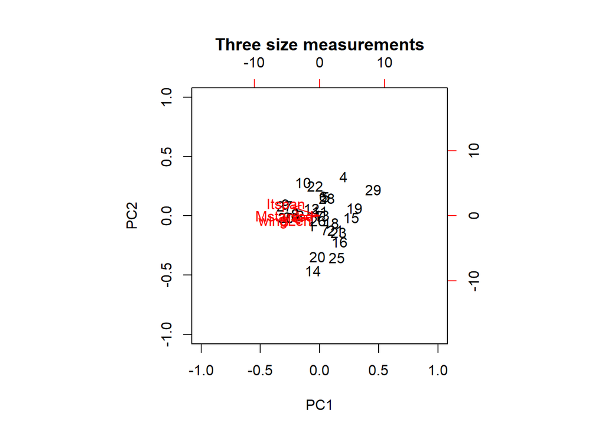

```r
biplot(aa, main = "Three size measurements", xlim = c(-1,1), ylim = c(-1,1)) # shows that all three size measurement are correlated
```

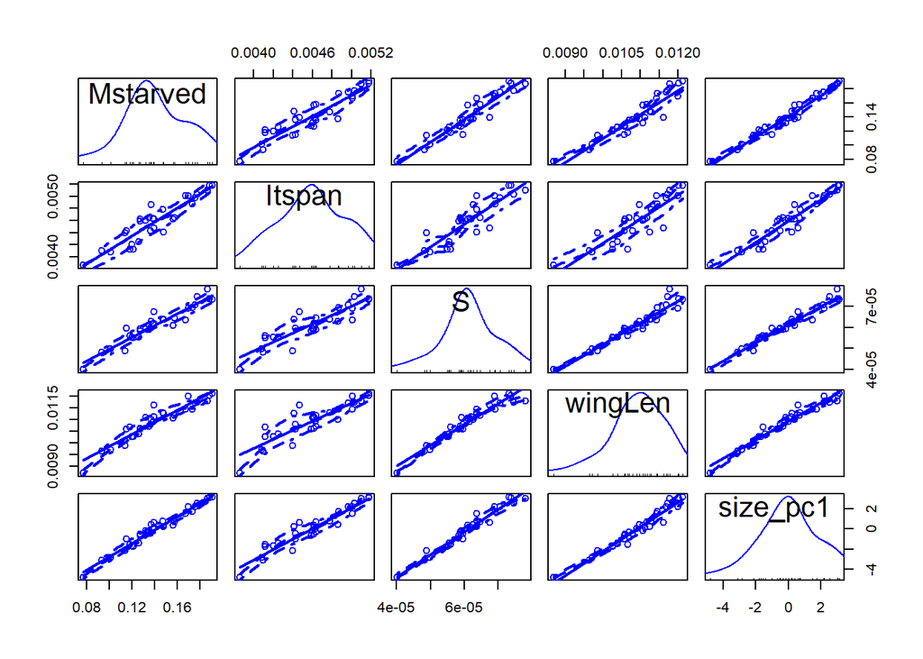

```r
# show scatterplot matrix to see correlations among size predictors
car::scatterplotMatrix(newDF[, c("Mstarved", "Itspan", "S",  "wingLen",  "size_pc1")])
```

## Metabolic Rate vs. loading conditions

```r
tapply(bdta$MetR, INDEX = bdta$Treatment, function(x) return(c(mean(x), sd(x))))
```

```
## $H
## [1] 11.722018  2.459945
##
## $L
## [1] 9.477230 2.393486
```

```r
m1 <- lmer(MetR ~ Treatment * MT + (1|BeeID), data = bdta)
summary(m1)
```

```
## Linear mixed model fit by REML. t-tests use Satterthwaite's method [
## lmerModLmerTest]
## Formula: MetR ~ Treatment * MT + (1 | BeeID)
##    Data: bdta
##
## REML criterion at convergence: 175.2
##
## Scaled residuals:
##     Min      1Q  Median      3Q     Max
## -1.5195 -0.6146  0.1095  0.4430  2.3691
##
## Random effects:
##  Groups   Name        Variance Std.Dev.
##  BeeID    (Intercept) 0.9866   0.9933
##  Residual             0.6581   0.8113
## Number of obs: 60, groups:  BeeID, 30
##
## Fixed effects:
##               Estimate Std. Error      df t value Pr(>|t|)
## (Intercept)     0.6007     1.2566 46.2050   0.478  0.63489
## TreatmentL     -1.6165     1.1287 28.3737  -1.432  0.16301
## MT             43.0428     4.7783 46.3767   9.008 9.41e-12 ***
## TreatmentL:MT  14.7835     5.3795 32.4615   2.748  0.00971 **
## ---
## Signif. codes:  0 '***' 0.001 '**' 0.01 '*' 0.05 '.' 0.1 ' ' 1
##
## Correlation of Fixed Effects:
##             (Intr) TrtmnL MT
## TreatmentL  -0.504
## MT          -0.982  0.497
## TretmntL:MT  0.195 -0.929 -0.198
```

```r
m2 <- update(m1, .~. - Treatment:MT)
anova(m2, m1, test = "LRT")
```

```
## refitting model(s) with ML (instead of REML)
```

```
## Data: bdta
## Models:
## m2: MetR ~ Treatment + MT + (1 | BeeID)
## m1: MetR ~ Treatment * MT + (1 | BeeID)
##    Df    AIC    BIC  logLik deviance  Chisq Chi Df Pr(>Chisq)
## m2  5 199.78 210.25 -94.891   189.78
## m1  6 194.61 207.17 -91.304   182.61 7.1733      1     0.0074 **
## ---
## Signif. codes:  0 '***' 0.001 '**' 0.01 '*' 0.05 '.' 0.1 ' ' 1
```

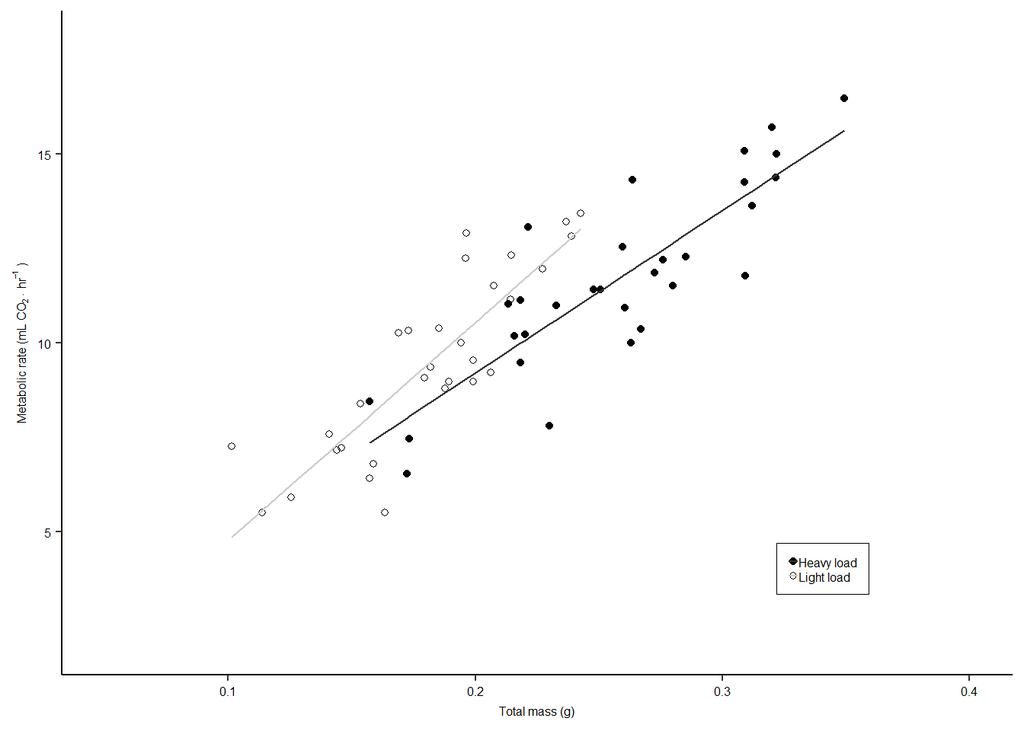

```r
#######################################################
## Metabolic Rate vs. loading conditions
#######################################################

# predict lines from m2


# make dataset for Fig 3a
fig3a_dta <- bdta %>%
  mutate(HighLowTrt = recode(.$Treatment, "H" = "Heavy load",
                       "L" = "Light load"),
         predictedMetR = predict(m1, re.form = NA)) %>%
  select(MT, HighLowTrt, MetR, predictedMetR)


# save data
write_csv(fig3a_dta, file.path(dataOut, "Fig3AData.csv"))



fig3a <- ggplot(fig3a_dta, aes(x = MT, y = MetR )) +
  geom_point(aes(shape = HighLowTrt)) +
  geom_line(aes(y = predictedMetR, color = HighLowTrt), size = 0.5) +
  labs(y = expression("Metabolic rate (mL CO" [2] %.% ~ "hr"^{-1}~ ")" ),
       x = "Total mass (g)") +
  lims(x = c(0.05,0.4), y = c(2, 18)) +
  theme(legend.title = element_blank(),
        legend.background = element_rect(colour = "black", size = 0.3),
        legend.position = c(0.8, 0.16),
        legend.text = element_text(size = 6),
        axis.text = element_text(size = 6),
        axis.title = element_text(size = 6),
        legend.key.size = unit(0.2, "cm")) +
  scale_color_grey() +
  scale_shape_manual(values = c(16,1))

fig3a
```

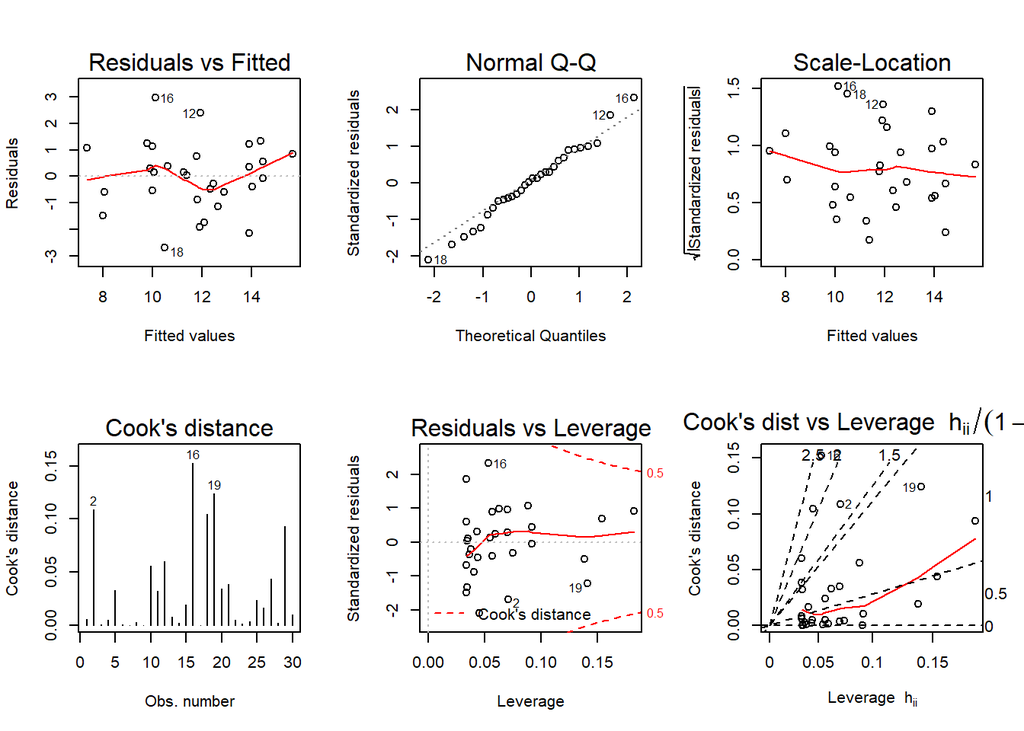

```r
ggsave(filename = file.path(figDir, "fig3A.png"), width = 6.5/2, height = 2,
        plot = fig3a,
       units = "in", dpi = 500)





# calculate R^2 for heavy
mod1 <- lm(MetR_H ~ I(Mstarved + load_H), data = newDF)

# diagnostics
par(mfrow = c(2,3))
plot(mod1, which = 1:6)
```

```r
dev.off()
```

```r
summary(mod1)
```

```
##
## Call:
## lm(formula = MetR_H ~ I(Mstarved + load_H), data = newDF)
##
## Residuals:
##     Min      1Q  Median      3Q     Max
## -2.6912 -0.5972  0.0929  0.8161  2.9546
##
## Coefficients:
##                      Estimate Std. Error t value Pr(>|t|)
## (Intercept)            0.6051     1.3071   0.463    0.647
## I(Mstarved + load_H)  43.0258     4.9739   8.650 2.13e-09 ***
## ---
## Signif. codes:  0 '***' 0.001 '**' 0.01 '*' 0.05 '.' 0.1 ' ' 1
##
## Residual standard error: 1.306 on 28 degrees of freedom
## Multiple R-squared:  0.7277, Adjusted R-squared:  0.718
## F-statistic: 74.83 on 1 and 28 DF,  p-value: 2.132e-09
```

```r
# R^2 for light
mod2 <-  lm(MetR_L ~ I(Mstarved + load_L), data = newDF)
summary(mod2)
```

```
##
## Call:
## lm(formula = MetR_L ~ I(Mstarved + load_L), data = newDF)
##
## Residuals:
##     Min      1Q  Median      3Q     Max
## -2.9502 -0.8017 -0.1401  0.5937  2.5763
##
## Coefficients:
##                      Estimate Std. Error t value Pr(>|t|)
## (Intercept)           -0.8105     1.1967  -0.677    0.504
## I(Mstarved + load_L)  56.6946     6.4717   8.760 1.64e-09 ***
## ---
## Signif. codes:  0 '***' 0.001 '**' 0.01 '*' 0.05 '.' 0.1 ' ' 1
##
## Residual standard error: 1.259 on 28 degrees of freedom
## Multiple R-squared:  0.7327, Adjusted R-squared:  0.7231
## F-statistic: 76.74 on 1 and 28 DF,  p-value: 1.642e-09
```

```r
# diagnostics
par(mfrow = c(2,3))
plot(mod2, which = 1:6)
dev.off()
```

## Mass-specific metabolic rate versus percent loading

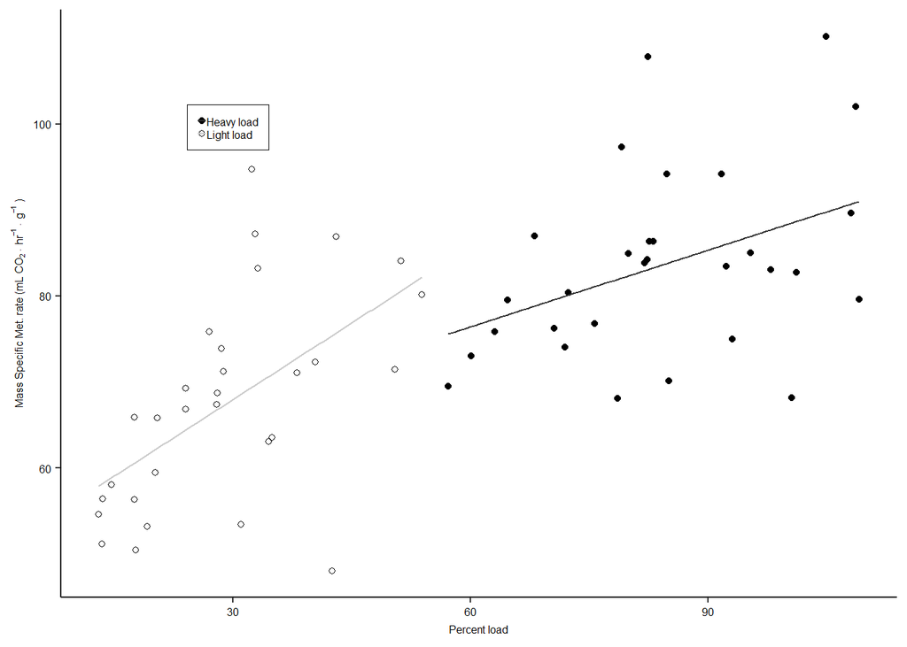

```r
#######################################################
### Mass-specific metabolic rate versus percent loading
#######################################################

# Plot mass-specific metabolic rate vs. percent loading
noFig <- bdta %>%
  mutate(Trt2 = recode(.$Treatment, "H" = "Heavy load",
                       "L" = "Light load")) %>%
ggplot(aes(x = perLoad, y = Mass_Spec_MetR )) +
  geom_point(aes(shape = Trt2)) +
  stat_smooth(aes(color = Trt2), method = "lm", se = F, size = 0.5) +
  labs(y = expression("Mass Specific Met. rate (mL CO"
                      [2] %.% ~ "hr"^{-1} %.% ~ "g"^{-1}~ ")" ),
       x = "Percent load") +
  #lims(x = c(0.05,0.4), y = c(2, 18)) +
  theme(legend.title = element_blank(),
        legend.background = element_rect(colour = "black", size = 0.3),
        legend.position = c(0.2, 0.8),
        legend.text = element_text(size = 6),
        axis.text = element_text(size = 6),
        axis.title = element_text(size = 6),
        legend.key.size = unit(0.2, "cm")) +
  scale_color_grey() +
  scale_shape_manual(values = c(16,1))
noFig
```

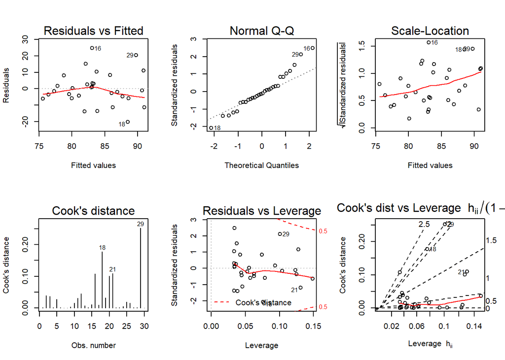

```r
ggsave(filename = file.path(figDir, "Mass_spec_MetRate.png"), width = 6.5/2, height = 2,
        plot = noFig,
       units = "in", dpi = 500)


# calculate R^2 for heavy
mod1 <- lm(Mass_Spec_MetR ~ perLoad, data = bdta[bdta$Treatment == "H", ])
# diagnostics
par(mfrow = c(2,3))
plot(mod1, which = 1:6)
```

```r
dev.off()
```

```r
summary(mod1)
```

```
##
## Call:
## lm(formula = Mass_Spec_MetR ~ perLoad, data = bdta[bdta$Treatment ==
##     "H", ])
##
## Residuals:
##     Min      1Q  Median      3Q     Max
## -20.348  -5.568  -1.296   3.165  24.759
##
## Coefficients:
##             Estimate Std. Error t value Pr(>|t|)
## (Intercept)  58.5950    10.9257   5.363 1.03e-05 ***
## perLoad       0.2970     0.1279   2.323   0.0277 *
## ---
## Signif. codes:  0 '***' 0.001 '**' 0.01 '*' 0.05 '.' 0.1 ' ' 1
##
## Residual standard error: 10.17 on 28 degrees of freedom
## Multiple R-squared:  0.1616, Adjusted R-squared:  0.1316
## F-statistic: 5.395 on 1 and 28 DF,  p-value: 0.02768
```

```r
with(bdta[bdta$Treatment == "H", ], {
  plot(Mass_Spec_MetR ~ perLoad, pch = 20)
  lines(x = perLoad, y = predict(mod1))
})


mod2 <- lm(Mass_Spec_MetR ~ perLoad, data =  bdta[bdta$Treatment == "L", ])
summary(mod2)
```

[output not shown]

```
##
## Call:
## lm(formula = Mass_Spec_MetR ~ perLoad, data = bdta[bdta$Treatment ==
##     "L", ])
##
## Residuals:
##     Min      1Q  Median      3Q     Max
## -27.383  -6.284  -1.248   4.581  25.362
##
## Coefficients:
##             Estimate Std. Error t value Pr(>|t|)
## (Intercept)  50.1615     5.1181   9.801  1.5e-10 ***
## perLoad       0.5935     0.1636   3.628  0.00113 **
## ---
## Signif. codes:  0 '***' 0.001 '**' 0.01 '*' 0.05 '.' 0.1 ' ' 1
##
## Residual standard error: 10.24 on 28 degrees of freedom
## Multiple R-squared:  0.3197, Adjusted R-squared:  0.2955
## F-statistic: 13.16 on 1 and 28 DF,  p-value: 0.001129
```

```r
# diagnostics
par(mfrow = c(2,3))
plot(mod2, which = 1:6)
dev.off()
```

```r
with(bdta[bdta$Treatment == "L", ], {
  plot(Mass_Spec_MetR ~ perLoad)
  lines(x = perLoad, y = predict(mod2))
})
```

[output not shown]

## Force vs. body mass

```r
m1 <- lmer(frce ~ Treatment * MT + (1|BeeID), data = bdta)
summary(m1)
```

```
## Linear mixed model fit by REML. t-tests use Satterthwaite's method [
## lmerModLmerTest]
## Formula: frce ~ Treatment * MT + (1 | BeeID)
##    Data: bdta
##
## REML criterion at convergence: -757.8
##
## Scaled residuals:
##      Min       1Q   Median       3Q      Max
## -2.18698 -0.59259  0.07097  0.52061  1.74417
##
## Random effects:
##  Groups   Name        Variance  Std.Dev.
##  BeeID    (Intercept) 1.898e-08 0.0001378
##  Residual             5.987e-08 0.0002447
## Number of obs: 60, groups:  BeeID, 30
##
## Fixed effects:
##                 Estimate Std. Error         df t value Pr(>|t|)
## (Intercept)   -2.996e-05  2.803e-04  5.375e+01  -0.107   0.9153
## TreatmentL    -6.519e-04  3.390e-04  2.827e+01  -1.923   0.0646 .
## MT             1.135e-02  1.067e-03  5.378e+01  10.639 7.68e-15 ***
## TreatmentL:MT  3.374e-03  1.581e-03  3.017e+01   2.134   0.0411 *
## ---
## Signif. codes:  0 '***' 0.001 '**' 0.01 '*' 0.05 '.' 0.1 ' ' 1
##
## Correlation of Fixed Effects:
##             (Intr) TrtmnL MT
## TreatmentL  -0.645
## MT          -0.983  0.635
## TretmntL:MT  0.456 -0.959 -0.464
```

```r
m2 <- update(m1, .~. - Treatment:MT)
anova(m2, m1, test = "LRT")
```

```
## refitting model(s) with ML (instead of REML)
```

```
## Data: bdta
## Models:
## m2: frce ~ Treatment + MT + (1 | BeeID)
## m1: frce ~ Treatment * MT + (1 | BeeID)
##    Df    AIC     BIC logLik deviance  Chisq Chi Df Pr(>Chisq)
## m2  5 -802.5 -792.03 406.25   -812.5
## m1  6 -805.0 -792.43 408.50   -817.0 4.4995      1     0.0339 *
## ---
## Signif. codes:  0 '***' 0.001 '**' 0.01 '*' 0.05 '.' 0.1 ' ' 1
```

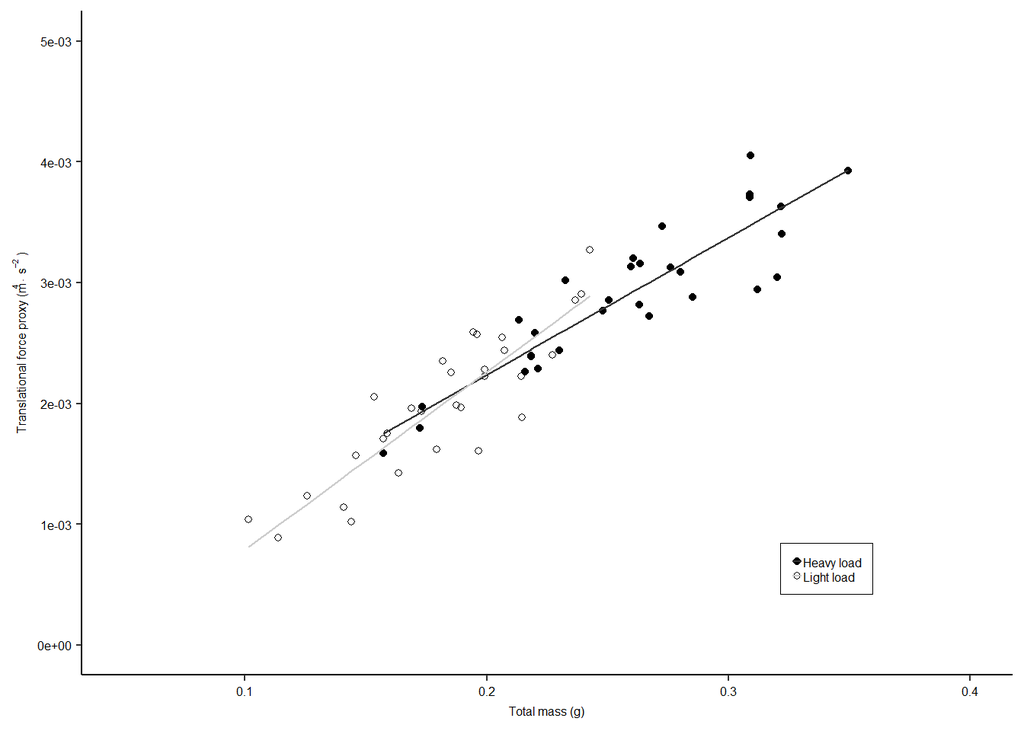

```r
# Plot force vs. body mass + load
fig3b_dta <- bdta %>%
  mutate(Trt2 = recode(.$Treatment, "H" = "Heavy load",
                       "L" = "Light load"))


# make dataset for Fig 3a
fig3b_dta <- bdta %>%
  mutate(HighLowTrt = recode(.$Treatment, "H" = "Heavy load",
                       "L" = "Light load"),
         predictedTransForce = predict(m1, re.form = NA)) %>%
  select(MT, HighLowTrt, frce, predictedTransForce)

# save data
write_csv(fig3b_dta, file.path(dataOut, "Fig3BData.csv"))


fig3b <- ggplot(fig3b_dta, aes(x = MT, y = frce )) +
  geom_point(aes(shape = HighLowTrt)) +
  #stat_smooth(aes(color = HighLowTrt), method = "lm", se = F, size = 0.5) +
  geom_line(aes(y = predictedTransForce, color = HighLowTrt), size = 0.5) +
  labs(y = expression("Translational force proxy (m"^4 %.% ~ "s"^{-2}~ ")" ),
       x = "Total mass (g)") +
  lims(x = c(0.05,0.4)) +
  theme(legend.title = element_blank(),
        legend.background = element_rect(colour = "black", size = 0.3),
        legend.position = c(0.8, 0.16),
        legend.text = element_text(size = 6),
        axis.text = element_text(size = 6),
        axis.title = element_text(size = 6),
        legend.key.size = unit(0.2, "cm")) +
  scale_color_grey() +
  scale_shape_manual(values = c(16,1)) +
  scale_y_continuous(labels = scales::scientific, limits = c(0, 5e-3))

fig3b
```

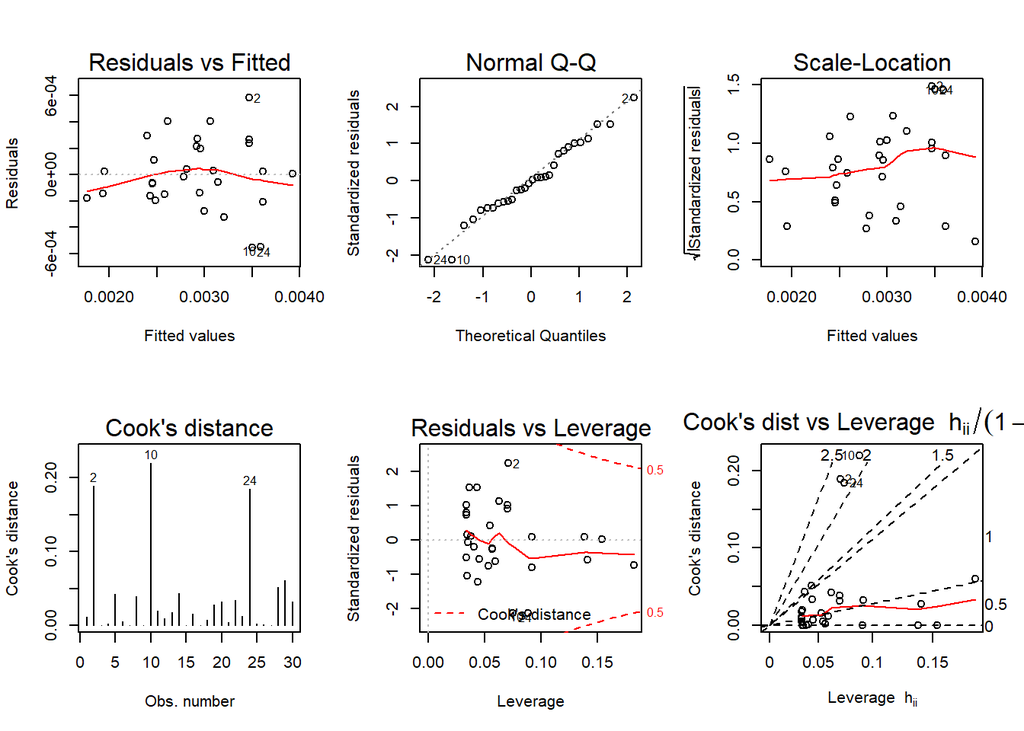

```r
ggsave(filename = file.path(figDir, "fig3B.png"), width = 6.5/2, height = 2,
        plot = fig3b,
       units = "in", dpi = 500)


# calculate R^2 for heavy
mod1 <- lm(frce ~ MT, data = bdta[bdta$Treatment == "H", ])
# diagnostics
par(mfrow = c(2,3))
plot(mod1, which = 1:6)
```

```r
dev.off()
```

```r
(summ <- summary(mod1))
```

```
##
## Call:
## lm(formula = frce ~ MT, data = bdta[bdta$Treatment == "H", ])
##
## Residuals:
##        Min         1Q     Median         3Q        Max
## -5.576e-04 -1.600e-04 -6.450e-06  2.084e-04  5.836e-04
##
## Coefficients:
##              Estimate Std. Error t value Pr(>|t|)
## (Intercept) 0.0000125  0.0002720   0.046    0.964
## MT          0.0111829  0.0010351  10.804  1.7e-11 ***
## ---
## Signif. codes:  0 '***' 0.001 '**' 0.01 '*' 0.05 '.' 0.1 ' ' 1
##
## Residual standard error: 0.0002719 on 28 degrees of freedom
## Multiple R-squared:  0.8065, Adjusted R-squared:  0.7996
## F-statistic: 116.7 on 1 and 28 DF,  p-value: 1.7e-11
```

```r
summ$r.squared
```

```
## [1] 0.8065261
```

```r
mod2 <- lm(frce ~ MT, data =  bdta[bdta$Treatment == "L", ])
summary(mod2)
```

```
##
## Call:
## lm(formula = frce ~ MT, data = bdta[bdta$Treatment == "L", ])
##
## Residuals:
##        Min         1Q     Median         3Q        Max
## -6.050e-04 -2.137e-04  6.502e-05  1.841e-04  4.686e-04
##
## Coefficients:
##               Estimate Std. Error t value Pr(>|t|)
## (Intercept) -0.0006430  0.0002749  -2.339   0.0267 *
## MT           0.0145074  0.0014867   9.758 1.65e-10 ***
## ---
## Signif. codes:  0 '***' 0.001 '**' 0.01 '*' 0.05 '.' 0.1 ' ' 1
##
## Residual standard error: 0.0002893 on 28 degrees of freedom
## Multiple R-squared:  0.7728, Adjusted R-squared:  0.7647
## F-statistic: 95.23 on 1 and 28 DF,  p-value: 1.647e-10
```

```r
summary(mod2)$r.squared
```

```
## [1] 0.7727762
```

```r
# diagnostics
par(mfrow = c(2,3))
plot(mod2, which = 1:6)
dev.off()
```

## Stroke Amplitude

```r
# calculate mean + sd for each treatment
tapply(bdta$amp, INDEX = bdta$Treatment, function(x) c(mean(x), sd(x)))
```

```
## $H
## [1] 133.44981   5.51554
##
## $L
## [1] 113.161785   7.968646
```

```r
# make a full model with all two-way interactions
m1 <- lmer(amp ~  (size_pc1 +  order + Treatment)^2 + (1|BeeID), data = bdta)

summary(m1)
```

```
## Linear mixed model fit by REML. t-tests use Satterthwaite's method [
## lmerModLmerTest]
## Formula: amp ~ (size_pc1 + order + Treatment)^2 + (1 | BeeID)
##    Data: bdta
##
## REML criterion at convergence: 372.3
##
## Scaled residuals:
##      Min       1Q   Median       3Q      Max
## -1.87488 -0.47785  0.06077  0.49932  1.90974
##
## Random effects:
##  Groups   Name        Variance Std.Dev.
##  BeeID    (Intercept) 16.43    4.054
##  Residual             28.10    5.301
## Number of obs: 60, groups:  BeeID, 30
##
## Fixed effects:
##                       Estimate Std. Error         df t value Pr(>|t|)
## (Intercept)         135.587127   1.795000  47.315619  75.536  < 2e-16 ***
## size_pc1             -0.001922   0.722003  52.735741  -0.003   0.9979
## order2               -3.840223   2.465600  47.211607  -1.558   0.1260
## TreatmentL          -21.174687   2.465600  47.211607  -8.588  3.3e-11 ***
## size_pc1:order2      -0.681761   0.727551  26.000000  -0.937   0.3573
## size_pc1:TreatmentL   1.371019   0.727551  26.000000   1.884   0.0707 .
## order2:TreatmentL     0.969105   4.079739  27.000000   0.238   0.8140
## ---
## Signif. codes:  0 '***' 0.001 '**' 0.01 '*' 0.05 '.' 0.1 ' ' 1
##
## Correlation of Fixed Effects:
##             (Intr) sz_pc1 order2 TrtmnL sz_1:2 s_1:TL
## size_pc1     0.113
## order2      -0.732 -0.121
## TreatmentL  -0.732 -0.121  0.705
## sz_pc1:rdr2 -0.051 -0.452 -0.003  0.077
## sz_pc1:TrtL -0.051 -0.452  0.077 -0.003 -0.103
## ordr2:TrtmL  0.606  0.101 -0.827 -0.827  0.000  0.000
```

```r
### LRT's for interactions
m2.0 <- update(m1, .~. - order:Treatment )

anova(m1, m2.0)
```

```
## refitting model(s) with ML (instead of REML)
```

```
## Data: bdta
## Models:
## m2.0: amp ~ size_pc1 + order + Treatment + (1 | BeeID) + size_pc1:order +
## m2.0:     size_pc1:Treatment
## m1: amp ~ (size_pc1 + order + Treatment)^2 + (1 | BeeID)
##      Df    AIC    BIC  logLik deviance  Chisq Chi Df Pr(>Chisq)
## m2.0  8 402.27 419.02 -193.13   386.27
## m1    9 404.20 423.05 -193.10   386.20 0.0626      1     0.8024
```

```r
summary(m2.0)
```

```
## Linear mixed model fit by REML. t-tests use Satterthwaite's method [
## lmerModLmerTest]
## Formula:
## amp ~ size_pc1 + order + Treatment + (1 | BeeID) + size_pc1:order +
##     size_pc1:Treatment
##    Data: bdta
##
## REML criterion at convergence: 377
##
## Scaled residuals:
##     Min      1Q  Median      3Q     Max
## -1.8624 -0.4602  0.0443  0.4915  1.9181
##
## Random effects:
##  Groups   Name        Variance Std.Dev.
##  BeeID    (Intercept) 15.4     3.925
##  Residual             28.1     5.301
## Number of obs: 60, groups:  BeeID, 30
##
## Fixed effects:
##                      Estimate Std. Error        df t value Pr(>|t|)
## (Intercept)         135.32870    1.41569  53.82351  95.592  < 2e-16 ***
## size_pc1             -0.01931    0.71172  53.96318  -0.027   0.9785
## order2               -3.35567    1.38496  26.00000  -2.423   0.0227 *
## TreatmentL          -20.69014    1.38496  26.00000 -14.939 2.83e-14 ***
## size_pc1:order2      -0.68176    0.72755  26.00000  -0.937   0.3573
## size_pc1:TreatmentL   1.37102    0.72755  26.00000   1.884   0.0707 .
## ---
## Signif. codes:  0 '***' 0.001 '**' 0.01 '*' 0.05 '.' 0.1 ' ' 1
##
## Correlation of Fixed Effects:
##             (Intr) sz_pc1 order2 TrtmnL sz_1:2
## size_pc1     0.066
## order2      -0.521 -0.067
## TreatmentL  -0.521 -0.067  0.066
## sz_pc1:rdr2 -0.065 -0.458 -0.005  0.137
## sz_pc1:TrtL -0.065 -0.458  0.137 -0.005 -0.103
```

```r
m2.1 <- update(m2.0,.~. - size_pc1:order)
anova(m2.0, m2.1)
```

```
## refitting model(s) with ML (instead of REML)
```

```
## Data: bdta
## Models:
## m2.1: amp ~ size_pc1 + order + Treatment + (1 | BeeID) + size_pc1:Treatment
## m2.0: amp ~ size_pc1 + order + Treatment + (1 | BeeID) + size_pc1:order +
## m2.0:     size_pc1:Treatment
##      Df    AIC    BIC  logLik deviance  Chisq Chi Df Pr(>Chisq)
## m2.1  7 401.26 415.92 -193.63   387.26
## m2.0  8 402.27 419.02 -193.13   386.27 0.9964      1     0.3182
```

```r
summary(m2.1)
```

```
## Linear mixed model fit by REML. t-tests use Satterthwaite's method [
## lmerModLmerTest]
## Formula:
## amp ~ size_pc1 + order + Treatment + (1 | BeeID) + size_pc1:Treatment
##    Data: bdta
##
## REML criterion at convergence: 379
##
## Scaled residuals:
##      Min       1Q   Median       3Q      Max
## -1.89385 -0.47993  0.05226  0.49727  1.90144
##
## Random effects:
##  Groups   Name        Variance Std.Dev.
##  BeeID    (Intercept) 15.47    3.933
##  Residual             27.98    5.289
## Number of obs: 60, groups:  BeeID, 30
##
## Fixed effects:
##                     Estimate Std. Error       df t value Pr(>|t|)
## (Intercept)         135.2430     1.4111  54.9437  95.841  < 2e-16 ***
## size_pc1             -0.3249     0.6321  49.6112  -0.514   0.6095
## order2               -3.3623     1.3818  27.0000  -2.433   0.0219 *
## TreatmentL          -20.5122     1.3688  27.0000 -14.986 1.32e-14 ***
## size_pc1:TreatmentL   1.3005     0.7220  27.0000   1.801   0.0829 .
## ---
## Signif. codes:  0 '***' 0.001 '**' 0.01 '*' 0.05 '.' 0.1 ' ' 1
##
## Correlation of Fixed Effects:
##             (Intr) sz_pc1 order2 TrtmnL
## size_pc1     0.041
## order2      -0.522 -0.078
## TreatmentL  -0.518 -0.005  0.067
## sz_pc1:TrtL -0.072 -0.571  0.137  0.009
```

```r
m2.2 <- update(m2.1, .~. - size_pc1:Treatment)
anova(m2.1, m2.2) ## drop all interactions
```

```
## refitting model(s) with ML (instead of REML)
```

```
## Data: bdta
## Models:
## m2.2: amp ~ size_pc1 + order + Treatment + (1 | BeeID)
## m2.1: amp ~ size_pc1 + order + Treatment + (1 | BeeID) + size_pc1:Treatment
##      Df    AIC    BIC  logLik deviance  Chisq Chi Df Pr(>Chisq)
## m2.2  6 402.67 415.23 -195.33   390.67
## m2.1  7 401.26 415.92 -193.63   387.26 3.4041      1    0.06503 .
## ---
## Signif. codes:  0 '***' 0.001 '**' 0.01 '*' 0.05 '.' 0.1 ' ' 1
```

```r
summary(m2.2)
```

```
## Linear mixed model fit by REML. t-tests use Satterthwaite's method [
## lmerModLmerTest]
## Formula: amp ~ size_pc1 + order + Treatment + (1 | BeeID)
##    Data: bdta
##
## REML criterion at convergence: 383.4
##
## Scaled residuals:
##      Min       1Q   Median       3Q      Max
## -1.78731 -0.45421  0.00374  0.55162  1.86484
##
## Random effects:
##  Groups   Name        Variance Std.Dev.
##  BeeID    (Intercept) 14.35    3.788
##  Residual             30.22    5.497
## Number of obs: 60, groups:  BeeID, 30
##
## Fixed effects:
##             Estimate Std. Error       df t value Pr(>|t|)
## (Intercept) 135.4253     1.4357  55.8753  94.330  < 2e-16 ***
## size_pc1      0.3253     0.5189  28.0000   0.627   0.5358
## order2       -3.7041     1.4225  28.0000  -2.604   0.0146 *
## TreatmentL  -20.5350     1.4225  28.0000 -14.436  1.7e-14 ***
## ---
## Signif. codes:  0 '***' 0.001 '**' 0.01 '*' 0.05 '.' 0.1 ' ' 1
##
## Correlation of Fixed Effects:
##            (Intr) sz_pc1 order2
## size_pc1    0.000
## order2     -0.528  0.000
## TreatmentL -0.528  0.000  0.067
```

```r
# renaming model to simplify later typing
m2 <- m2.2

##### LRTs for main effects
## size
m3 <- update(m2, .~. - size_pc1)
anova(m2, m3, test = "Chi") # drop size_pc1
```

```
## refitting model(s) with ML (instead of REML)
```

```
## Data: bdta
## Models:
## m3: amp ~ order + Treatment + (1 | BeeID)
## m2: amp ~ size_pc1 + order + Treatment + (1 | BeeID)
##    Df    AIC    BIC  logLik deviance  Chisq Chi Df Pr(>Chisq)
## m3  5 401.09 411.56 -195.54   391.09
## m2  6 402.67 415.23 -195.33   390.67 0.4182      1     0.5178
```

```r
summary(m3)
```

```
## Linear mixed model fit by REML. t-tests use Satterthwaite's method [
## lmerModLmerTest]
## Formula: amp ~ order + Treatment + (1 | BeeID)
##    Data: bdta
##
## REML criterion at convergence: 384.3
##
## Scaled residuals:
##      Min       1Q   Median       3Q      Max
## -1.88194 -0.39804 -0.02366  0.53300  1.88336
##
## Random effects:
##  Groups   Name        Variance Std.Dev.
##  BeeID    (Intercept) 13.73    3.705
##  Residual             30.22    5.497
## Number of obs: 60, groups:  BeeID, 30
##
## Fixed effects:
##             Estimate Std. Error      df t value Pr(>|t|)
## (Intercept)  135.425      1.428  56.678  94.804  < 2e-16 ***
## order2        -3.704      1.423  28.000  -2.604   0.0146 *
## TreatmentL   -20.535      1.423  28.000 -14.436  1.7e-14 ***
## ---
## Signif. codes:  0 '***' 0.001 '**' 0.01 '*' 0.05 '.' 0.1 ' ' 1
##
## Correlation of Fixed Effects:
##            (Intr) order2
## order2     -0.531
## TreatmentL -0.531  0.067
```

```r
# trt order
m4 <- update(m3, .~. - order)
anova(m3, m4) # keep order
```

```
## refitting model(s) with ML (instead of REML)
```

```
## Data: bdta
## Models:
## m4: amp ~ Treatment + (1 | BeeID)
## m3: amp ~ order + Treatment + (1 | BeeID)
##    Df    AIC    BIC  logLik deviance  Chisq Chi Df Pr(>Chisq)
## m4  4 405.59 413.97 -198.80   397.59
## m3  5 401.09 411.56 -195.54   391.09 6.5054      1    0.01075 *
## ---
## Signif. codes:  0 '***' 0.001 '**' 0.01 '*' 0.05 '.' 0.1 ' ' 1
```

```r
# LRT for Treatment (load)
m5 <- update(m3, .~. - Treatment)
```

```
## singular fit
```

```r
anova(m3, m5) # keep treatment
```

```
## refitting model(s) with ML (instead of REML)
```

```
## Data: bdta
## Models:
## m5: amp ~ order + (1 | BeeID)
## m3: amp ~ order + Treatment + (1 | BeeID)
##    Df    AIC    BIC  logLik deviance  Chisq Chi Df Pr(>Chisq)
## m5  4 477.67 486.05 -234.84   469.67
## m3  5 401.09 411.56 -195.54   391.09 78.585      1  < 2.2e-16 ***
## ---
## Signif. codes:  0 '***' 0.001 '**' 0.01 '*' 0.05 '.' 0.1 ' ' 1
```

```r
# summarize final model for paper
smry <- summary(m3)
smry
```

```
## Linear mixed model fit by REML. t-tests use Satterthwaite's method [
## lmerModLmerTest]
## Formula: amp ~ order + Treatment + (1 | BeeID)
##    Data: bdta
##
## REML criterion at convergence: 384.3
##
## Scaled residuals:
##      Min       1Q   Median       3Q      Max
## -1.88194 -0.39804 -0.02366  0.53300  1.88336
##
## Random effects:
##  Groups   Name        Variance Std.Dev.
##  BeeID    (Intercept) 13.73    3.705
##  Residual             30.22    5.497
## Number of obs: 60, groups:  BeeID, 30
##
## Fixed effects:
##             Estimate Std. Error      df t value Pr(>|t|)
## (Intercept)  135.425      1.428  56.678  94.804  < 2e-16 ***
## order2        -3.704      1.423  28.000  -2.604   0.0146 *
## TreatmentL   -20.535      1.423  28.000 -14.436  1.7e-14 ***
## ---
## Signif. codes:  0 '***' 0.001 '**' 0.01 '*' 0.05 '.' 0.1 ' ' 1
##
## Correlation of Fixed Effects:
##            (Intr) order2
## order2     -0.531
## TreatmentL -0.531  0.067
```

```r
smry$coefficients
```

```
##               Estimate Std. Error      df    t value     Pr(>|t|)
## (Intercept) 135.425322   1.428476 56.6783  94.804081 3.930149e-64
## order2       -3.704089   1.422515 28.0000  -2.603902 1.458243e-02
## TreatmentL  -20.534962   1.422515 28.0000 -14.435678 1.695785e-14
```

```r
anova(m3, type = 2)
```

```
## Type II Analysis of Variance Table with Satterthwaite's method
##           Sum Sq Mean Sq NumDF DenDF  F value    Pr(>F)
## order      204.9   204.9     1    28   6.7803   0.01458 *
## Treatment 6297.2  6297.2     1    28 208.3888 1.696e-14 ***
## ---
## Signif. codes:  0 '***' 0.001 '**' 0.01 '*' 0.05 '.' 0.1 ' ' 1
```

```r
confint.merMod(m3)
```

```
## Computing profile confidence intervals ...
```

```
##                  2.5 %      97.5 %
## .sig01        0.000000   5.9241817
## .sigma        4.205352   7.0015502
## (Intercept) 132.653512 138.1971327
## order2       -6.486200  -0.9219777
## TreatmentL  -23.317073 -17.7528510
```

```r
# write output
summary(m3)$coefficients
```

```
##               Estimate Std. Error      df    t value     Pr(>|t|)
## (Intercept) 135.425322   1.428476 56.6783  94.804081 3.930149e-64
## order2       -3.704089   1.422515 28.0000  -2.603902 1.458243e-02
## TreatmentL  -20.534962   1.422515 28.0000 -14.435678 1.695785e-14
```

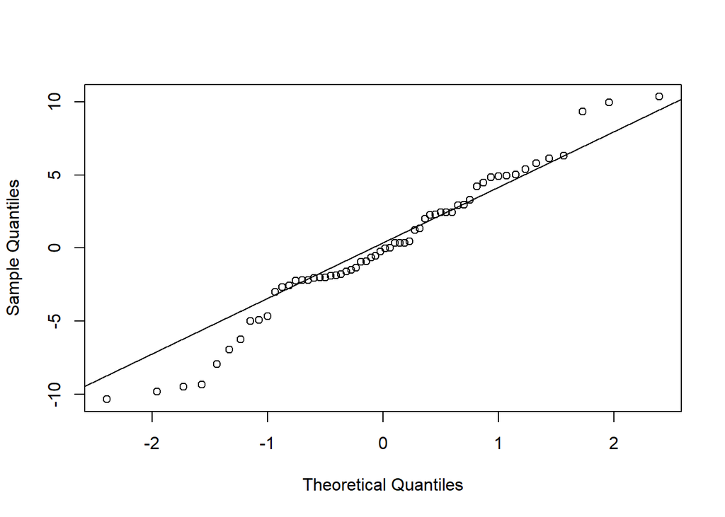

```r
# write.csv(summary(m3)$coefficients, file.path(dataOut, "AmpCoefs_TrtULVsL.csv" ))


# diagnostics
# qq plot
qqnorm(resid(m3), main = "")
qqline(resid(m3)) # ok
```

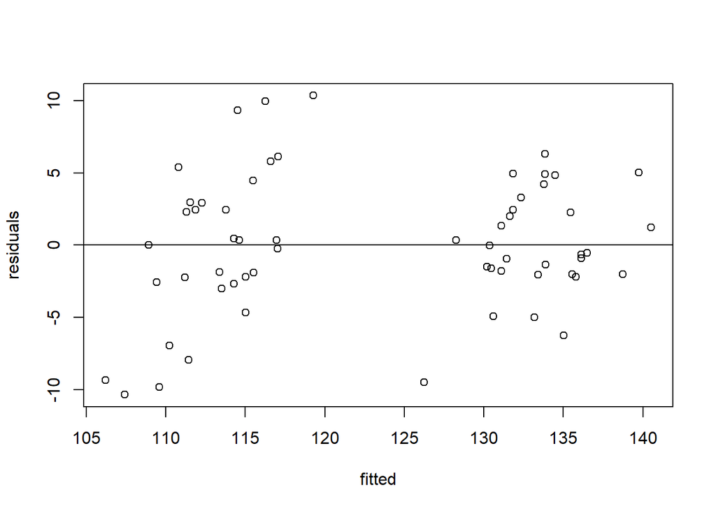

```r
# residual plot
plot(fitted(m3), resid(m3), xlab = "fitted", ylab = "residuals")
abline(0,0)
```

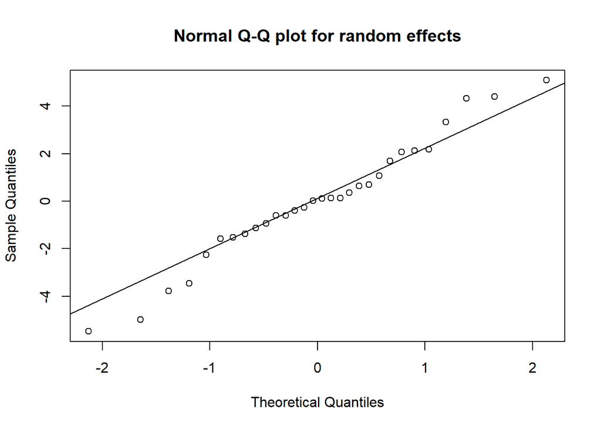

```r
# QQPlot for group-level effects
qqnorm(ranef(m3)$BeeID[[1]], main="Normal Q-Q plot for random effects")
qqline(ranef(m3)$BeeID[[1]]) # looks good
```

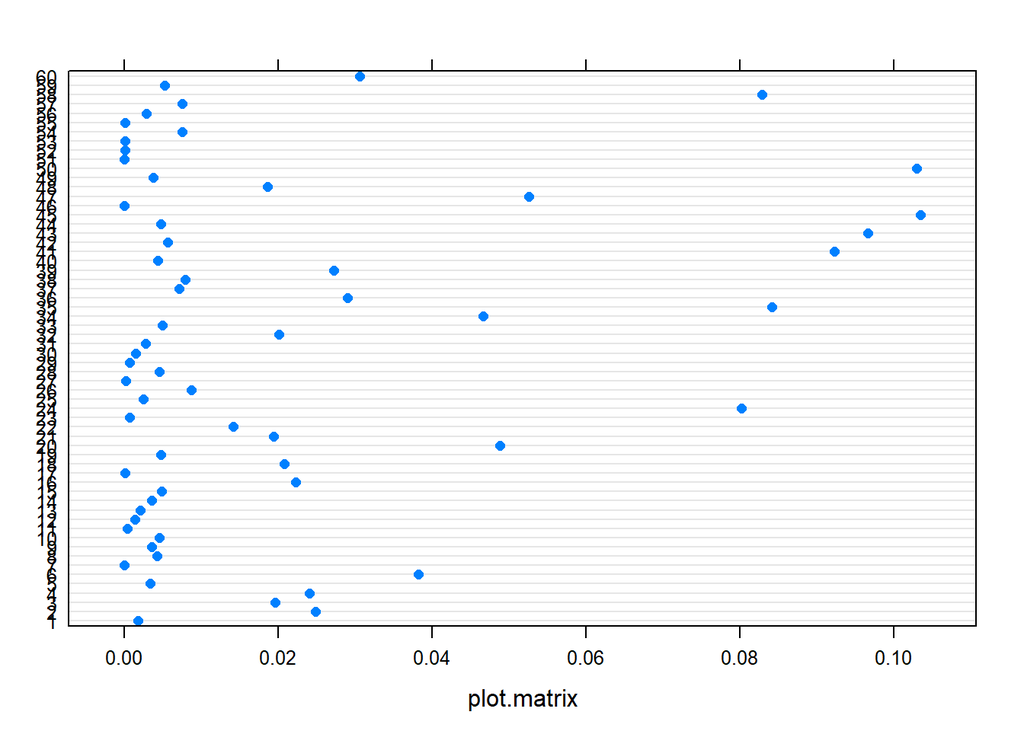

```r
infl <- influence(m3, obs = TRUE)
plot(infl, which = 'cook')
```

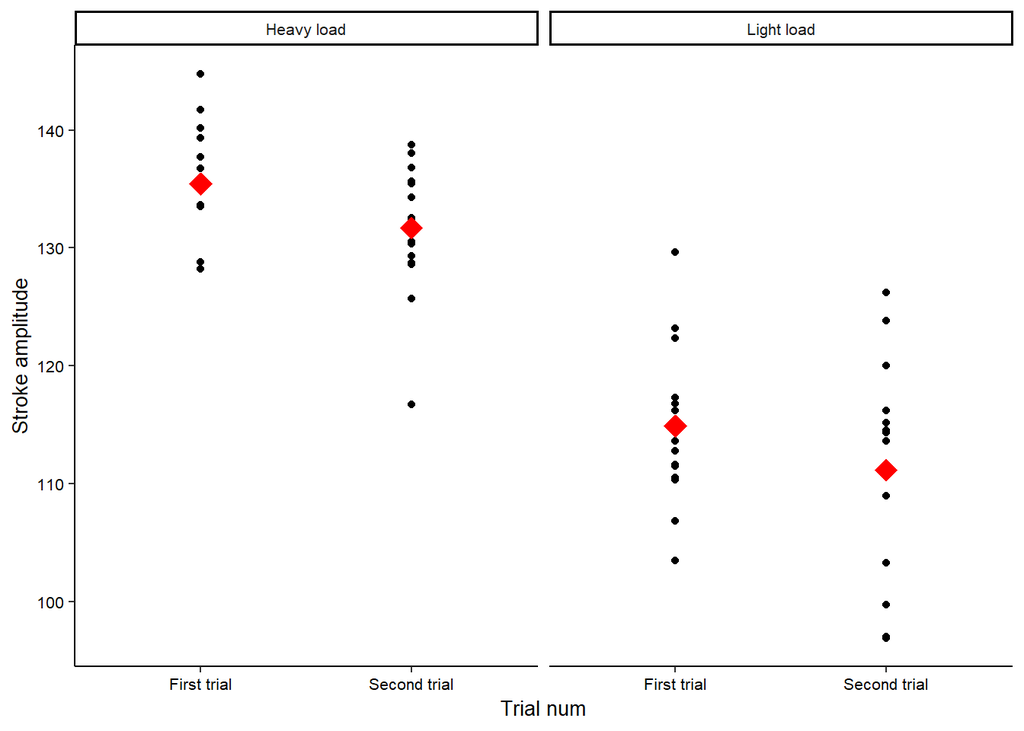

```r
bdta %>%
  mutate(Trt2 = recode(.$Treatment, "H" = "Heavy load",
                       "L" = "Light load"),
         order2 = recode(order, "1" = "First trial",
                                  "2" = "Second trial")) %>%
ggplot(aes(x = order2, y = amp)) +
  geom_point() +
  facet_grid(~Trt2) +
  geom_point(aes(x = order2, y = predict(m3, re.form = NA)),
             color = "red", shape = 18,
             size = 5) +
  labs(x = "Trial num", y="Stroke amplitude")
```

## Wingbeat Freq

```r
# how many trials increased
newDF$FreqHigherInHeavy <- (newDF$freq_H - newDF$freq_L) > 0
summary(newDF$FreqHigherInHeavy)
```

```
##    Mode   FALSE    TRUE
## logical       7      23
```

```r
sum(newDF$FreqHigherInHeavy) / nrow(newDF)
```

```
## [1] 0.7666667
```

```r
# calculate mean + sd for each treatment
tapply(bdta$freq, INDEX = bdta$Treatment, function(x) c(mean(x), sd(x)))
```

```
## $H
## [1] 179.988728   8.981654
##
## $L
## [1] 173.85574  10.62627
```

```r
tapply(newDF$FreqHigherInHeavy, INDEX = newDF$order_1, summary)
```

```
## $loadedFirst
##    Mode   FALSE    TRUE
## logical       1      13
##
## $loadedSecond
##    Mode   FALSE    TRUE
## logical       6      10
```

```r
# make a full model with all two-way interactions
m1 <- lmer(freq ~  (size_pc1 +  order + Treatment)^2 + (1|BeeID), data = bdta)

summary(m1)
```

```
## Linear mixed model fit by REML. t-tests use Satterthwaite's method [
## lmerModLmerTest]
## Formula: freq ~ (size_pc1 + order + Treatment)^2 + (1 | BeeID)
##    Data: bdta
##
## REML criterion at convergence: 384.6
##
## Scaled residuals:
##      Min       1Q   Median       3Q      Max
## -2.31619 -0.52881  0.05587  0.47145  1.97582
##
## Random effects:
##  Groups   Name        Variance Std.Dev.
##  BeeID    (Intercept) 21.00    4.582
##  Residual             35.31    5.942
## Number of obs: 60, groups:  BeeID, 30
##
## Fixed effects:
##                     Estimate Std. Error       df t value Pr(>|t|)
## (Intercept)         182.1251     2.0184  47.1996  90.232  < 2e-16 ***
## size_pc1             -3.4683     0.8114  52.7011  -4.275 8.06e-05 ***
## order2               -4.0906     2.7725  47.0953  -1.475   0.1468
## TreatmentL           -4.7173     2.7725  47.0953  -1.701   0.0954 .
## size_pc1:order2       0.3457     0.8156  26.0000   0.424   0.6752
## size_pc1:TreatmentL   0.3779     0.8156  26.0000   0.463   0.6470
## order2:TreatmentL    -3.4241     4.5942  27.0000  -0.745   0.4625
## ---
## Signif. codes:  0 '***' 0.001 '**' 0.01 '*' 0.05 '.' 0.1 ' ' 1
##
## Correlation of Fixed Effects:
##             (Intr) sz_pc1 order2 TrtmnL sz_1:2 s_1:TL
## size_pc1     0.113
## order2      -0.732 -0.121
## TreatmentL  -0.732 -0.121  0.707
## sz_pc1:rdr2 -0.051 -0.451 -0.003  0.077
## sz_pc1:TrtL -0.051 -0.451  0.077 -0.003 -0.103
## ordr2:TrtmL  0.607  0.102 -0.829 -0.829  0.000  0.000
```

```r
### LRT's for interactions
m2.0 <- update(m1, .~. - size_pc1:order )

anova(m1, m2.0)
```

```
## refitting model(s) with ML (instead of REML)
```

```
## Data: bdta
## Models:
## m2.0: freq ~ size_pc1 + order + Treatment + (1 | BeeID) + size_pc1:Treatment +
## m2.0:     order:Treatment
## m1: freq ~ (size_pc1 + order + Treatment)^2 + (1 | BeeID)
##      Df    AIC    BIC  logLik deviance  Chisq Chi Df Pr(>Chisq)
## m2.0  8 416.39 433.14 -200.19   400.39
## m1    9 418.18 437.03 -200.09   400.18 0.2066      1     0.6495
```

```r
summary(m2.0)
```

```
## Linear mixed model fit by REML. t-tests use Satterthwaite's method [
## lmerModLmerTest]
## Formula:
## freq ~ size_pc1 + order + Treatment + (1 | BeeID) + size_pc1:Treatment +
##     order:Treatment
##    Data: bdta
##
## REML criterion at convergence: 386.2
##
## Scaled residuals:
##      Min       1Q   Median       3Q      Max
## -2.34467 -0.56613  0.05776  0.47411  1.96477
##
## Random effects:
##  Groups   Name        Variance Std.Dev.
##  BeeID    (Intercept) 21.54    4.641
##  Residual             34.24    5.851
## Number of obs: 60, groups:  BeeID, 30
##
## Fixed effects:
##                     Estimate Std. Error       df t value Pr(>|t|)
## (Intercept)         182.1686     2.0062  46.9941  90.803  < 2e-16 ***
## size_pc1             -3.3134     0.7209  46.9941  -4.596 3.25e-05 ***
## order2               -4.0872     2.7593  46.9941  -1.481   0.1452
## TreatmentL           -4.8076     2.7513  46.7391  -1.747   0.0871 .
## size_pc1:TreatmentL   0.4136     0.7988  27.0000   0.518   0.6088
## order2:TreatmentL    -3.4241     4.5942  27.0000  -0.745   0.4625
## ---
## Signif. codes:  0 '***' 0.001 '**' 0.01 '*' 0.05 '.' 0.1 ' ' 1
##
## Correlation of Fixed Effects:
##             (Intr) sz_pc1 order2 TrtmnL s_1:TL
## size_pc1     0.101
## order2      -0.734 -0.137
## TreatmentL  -0.732 -0.098  0.716
## sz_pc1:TrtL -0.056 -0.554  0.076  0.005
## ordr2:TrtmL  0.611  0.114 -0.832 -0.835  0.000
```

```r
m2.1 <- update(m2.0,.~. - size_pc1:Treatment)
anova(m2.0, m2.1)
```

```
## refitting model(s) with ML (instead of REML)
```

```
## Data: bdta
## Models:
## m2.1: freq ~ size_pc1 + order + Treatment + (1 | BeeID) + order:Treatment
## m2.0: freq ~ size_pc1 + order + Treatment + (1 | BeeID) + size_pc1:Treatment +
## m2.0:     order:Treatment
##      Df    AIC    BIC  logLik deviance  Chisq Chi Df Pr(>Chisq)
## m2.1  7 414.68 429.34 -200.34   400.68
## m2.0  8 416.39 433.14 -200.19   400.39 0.2965      1     0.5861
```

```r
summary(m2.1)
```

```
## Linear mixed model fit by REML. t-tests use Satterthwaite's method [
## lmerModLmerTest]
## Formula:
## freq ~ size_pc1 + order + Treatment + (1 | BeeID) + order:Treatment
##    Data: bdta
##
## REML criterion at convergence: 387.9
##
## Scaled residuals:
##      Min       1Q   Median       3Q      Max
## -2.37317 -0.50554  0.05574  0.47675  1.98628
##
## Random effects:
##  Groups   Name        Variance Std.Dev.
##  BeeID    (Intercept) 21.98    4.689
##  Residual             33.35    5.775
## Number of obs: 60, groups:  BeeID, 30
##
## Fixed effects:
##                   Estimate Std. Error       df t value Pr(>|t|)
## (Intercept)       182.2266     1.9951  46.7576  91.339  < 2e-16 ***
## size_pc1           -3.1066     0.6001  27.0000  -5.177  1.9e-05 ***
## order2             -4.1959     2.7403  46.6338  -1.531   0.1325
## TreatmentL         -4.8148     2.7403  46.6338  -1.757   0.0855 .
## order2:TreatmentL  -3.4241     4.5942  27.0000  -0.745   0.4625
## ---
## Signif. codes:  0 '***' 0.001 '**' 0.01 '*' 0.05 '.' 0.1 ' ' 1
##
## Correlation of Fixed Effects:
##             (Intr) sz_pc1 order2 TrtmnL
## size_pc1     0.084
## order2      -0.733 -0.115
## TreatmentL  -0.733 -0.115  0.722
## ordr2:TrtmL  0.614  0.137 -0.838 -0.838
```

```r
m2.2 <- update(m2.1, .~. - order:Treatment)
anova(m2.1, m2.2) ## drop all interactions
```

```
## refitting model(s) with ML (instead of REML)
```

```
## Data: bdta
## Models:
## m2.2: freq ~ size_pc1 + order + Treatment + (1 | BeeID)
## m2.1: freq ~ size_pc1 + order + Treatment + (1 | BeeID) + order:Treatment
##      Df    AIC    BIC  logLik deviance  Chisq Chi Df Pr(>Chisq)
## m2.2  6 413.30 425.86 -200.65   401.30
## m2.1  7 414.68 429.34 -200.34   400.68 0.6109      1     0.4344
```

```r
summary(m2.2)
```

```
## Linear mixed model fit by REML. t-tests use Satterthwaite's method [
## lmerModLmerTest]
## Formula: freq ~ size_pc1 + order + Treatment + (1 | BeeID)
##    Data: bdta
##
## REML criterion at convergence: 393.3
##
## Scaled residuals:
##      Min       1Q   Median       3Q      Max
## -2.44734 -0.47086  0.09504  0.52310  2.05674
##
## Random effects:
##  Groups   Name        Variance Std.Dev.
##  BeeID    (Intercept) 21.37    4.623
##  Residual             33.35    5.775
## Number of obs: 60, groups:  BeeID, 30
##
## Fixed effects:
##             Estimate Std. Error       df t value Pr(>|t|)
## (Intercept) 183.1396     1.5681  55.9449 116.791  < 2e-16 ***
## size_pc1     -3.0451     0.5897  28.0000  -5.164 1.77e-05 ***
## order2       -5.9080     1.4943  28.0000  -3.954 0.000476 ***
## TreatmentL   -6.5268     1.4943  28.0000  -4.368 0.000156 ***
## ---
## Signif. codes:  0 '***' 0.001 '**' 0.01 '*' 0.05 '.' 0.1 ' ' 1
##
## Correlation of Fixed Effects:
##            (Intr) sz_pc1 order2
## size_pc1    0.000
## order2     -0.508  0.000
## TreatmentL -0.508  0.000  0.067
```

```r
# renaming model to simplify later typing
m2 <- m2.2

##### LRTs for main effects
## Treatment Order
m3 <- update(m2, .~. - order)
anova(m2, m3, test = "Chi")
```

```
## refitting model(s) with ML (instead of REML)
```

```
## Data: bdta
## Models:
## m3: freq ~ size_pc1 + Treatment + (1 | BeeID)
## m2: freq ~ size_pc1 + order + Treatment + (1 | BeeID)
##    Df   AIC    BIC  logLik deviance  Chisq Chi Df Pr(>Chisq)
## m3  5 424.6 435.07 -207.30    414.6
## m2  6 413.3 425.86 -200.65    401.3 13.307      1  0.0002644 ***
## ---
## Signif. codes:  0 '***' 0.001 '**' 0.01 '*' 0.05 '.' 0.1 ' ' 1
```

```r
# LRT for size
m4 <- update(m2, .~. - size_pc1)
anova(m2, m4)
```

```
## refitting model(s) with ML (instead of REML)
```

```
## Data: bdta
## Models:
## m4: freq ~ order + Treatment + (1 | BeeID)
## m2: freq ~ size_pc1 + order + Treatment + (1 | BeeID)
##    Df    AIC    BIC  logLik deviance  Chisq Chi Df Pr(>Chisq)
## m4  5 431.37 441.84 -210.68   421.37
## m2  6 413.30 425.86 -200.65   401.30 20.071      1  7.462e-06 ***
## ---
## Signif. codes:  0 '***' 0.001 '**' 0.01 '*' 0.05 '.' 0.1 ' ' 1
```

```r
# LRT for Treatment (load)
m5 <- update(m2, .~. - Treatment)
anova(m2, m5)
```

```
## refitting model(s) with ML (instead of REML)
```

```
## Data: bdta
## Models:
## m5: freq ~ size_pc1 + order + (1 | BeeID)
## m2: freq ~ size_pc1 + order + Treatment + (1 | BeeID)
##    Df    AIC    BIC  logLik deviance  Chisq Chi Df Pr(>Chisq)
## m5  5 426.88 437.35 -208.44   416.88
## m2  6 413.30 425.86 -200.65   401.30 15.588      1  7.875e-05 ***
## ---
## Signif. codes:  0 '***' 0.001 '**' 0.01 '*' 0.05 '.' 0.1 ' ' 1
```

```r
# summarize final model for paper
summary(m2)
```

```
## Linear mixed model fit by REML. t-tests use Satterthwaite's method [
## lmerModLmerTest]
## Formula: freq ~ size_pc1 + order + Treatment + (1 | BeeID)
##    Data: bdta
##
## REML criterion at convergence: 393.3
##
## Scaled residuals:
##      Min       1Q   Median       3Q      Max
## -2.44734 -0.47086  0.09504  0.52310  2.05674
##
## Random effects:
##  Groups   Name        Variance Std.Dev.
##  BeeID    (Intercept) 21.37    4.623
##  Residual             33.35    5.775
## Number of obs: 60, groups:  BeeID, 30
##
## Fixed effects:
##             Estimate Std. Error       df t value Pr(>|t|)
## (Intercept) 183.1396     1.5681  55.9449 116.791  < 2e-16 ***
## size_pc1     -3.0451     0.5897  28.0000  -5.164 1.77e-05 ***
## order2       -5.9080     1.4943  28.0000  -3.954 0.000476 ***
## TreatmentL   -6.5268     1.4943  28.0000  -4.368 0.000156 ***
## ---
## Signif. codes:  0 '***' 0.001 '**' 0.01 '*' 0.05 '.' 0.1 ' ' 1
##
## Correlation of Fixed Effects:
##            (Intr) sz_pc1 order2
## size_pc1    0.000
## order2     -0.508  0.000
## TreatmentL -0.508  0.000  0.067
```

```r
anova(m2, type = 2)
```

```
## Type II Analysis of Variance Table with Satterthwaite's method
##           Sum Sq Mean Sq NumDF DenDF F value    Pr(>F)
## size_pc1  889.17  889.17     1    28  26.666 1.772e-05 ***
## order     521.24  521.24     1    28  15.632 0.0004757 ***
## Treatment 636.16  636.16     1    28  19.078 0.0001556 ***
## ---
## Signif. codes:  0 '***' 0.001 '**' 0.01 '*' 0.05 '.' 0.1 ' ' 1
```

```r
# write output
summary(m2)$coefficients
```

```
##               Estimate Std. Error       df    t value     Pr(>|t|)
## (Intercept) 183.139646  1.5681024 55.94491 116.790616 1.604912e-68
## size_pc1     -3.045143  0.5896985 28.00000  -5.163899 1.771851e-05
## order2       -5.907972  1.4942972 28.00000  -3.953679 4.757109e-04
## TreatmentL   -6.526849  1.4942972 28.00000  -4.367839 1.556489e-04
```

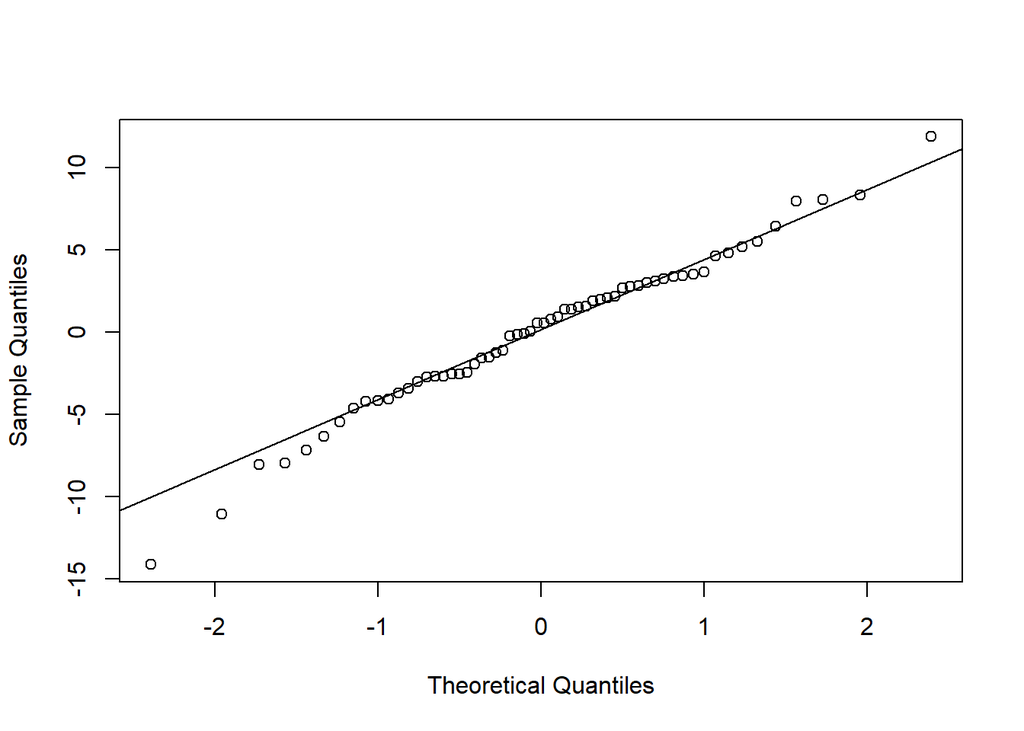

```r
# write.csv(summary(m2)$coefficients, file.path(dataOut, "FreqCoefs_TrtULVsL.csv" ))



# diagnostics
# qq plot
qqnorm(resid(m2), main = "")
qqline(resid(m2)) # good
```

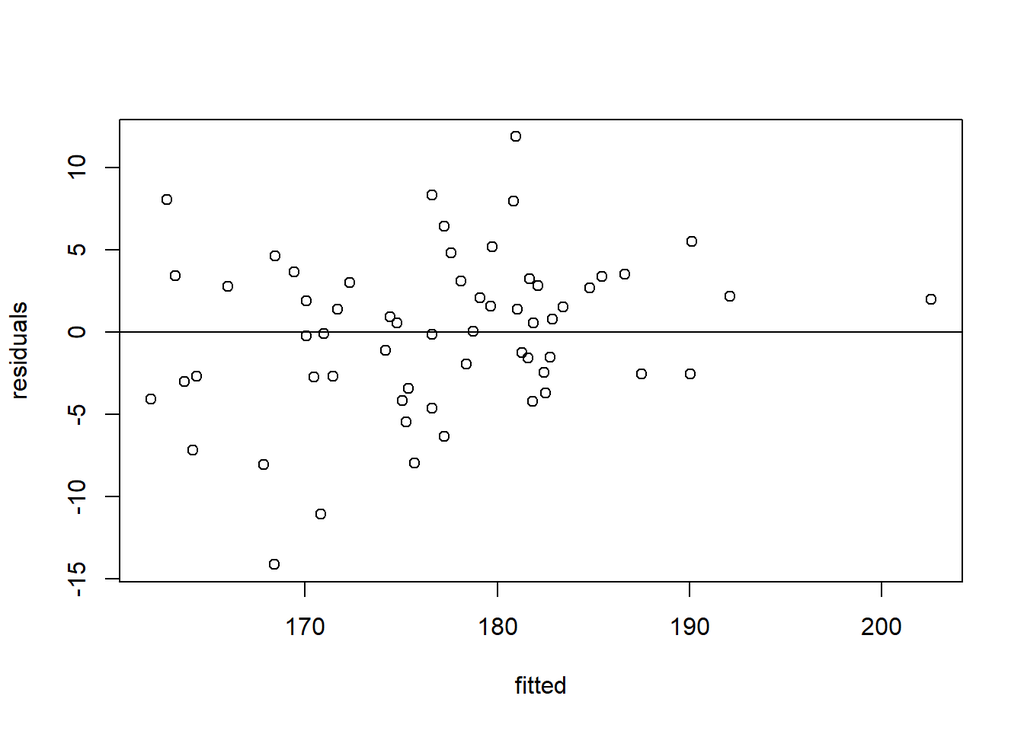

```r
# residual plot
plot(fitted(m2), resid(m2), xlab = "fitted", ylab = "residuals")
abline(0,0)
```

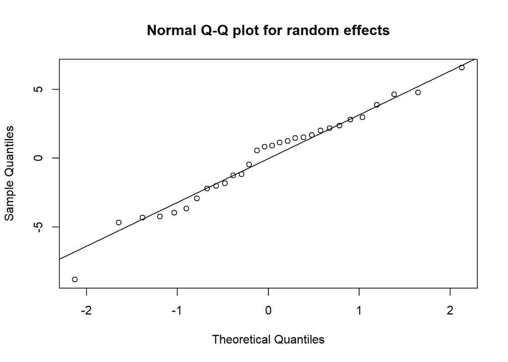

```r
# QQPlot for group-level effects
qqnorm(ranef(m2)$BeeID[[1]], main="Normal Q-Q plot for random effects")
qqline(ranef(m2)$BeeID[[1]]) # looks good
```

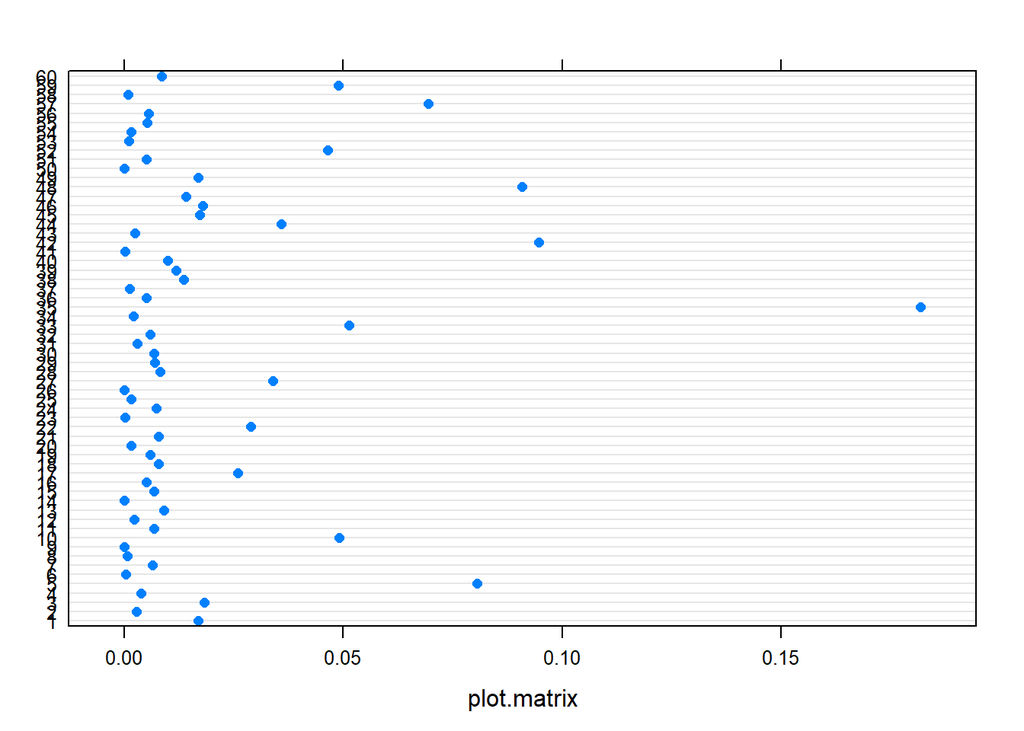

```r
infl <- influence(m2, obs = TRUE)
plot(infl, which = 'cook')
```

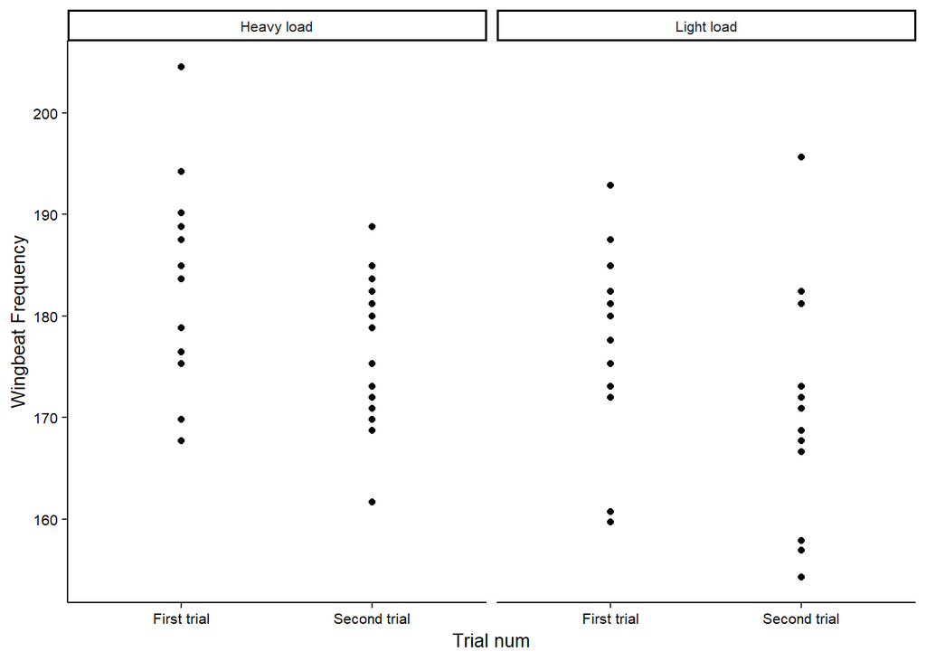

```r
bdta %>%
  mutate(Trt2 = recode(.$Treatment, "H" = "Heavy load",
                       "L" = "Light load"),
         order2 = recode(order, "1" = "First trial",
                                  "2" = "Second trial")) %>%
ggplot(aes(x = order2, y = freq)) +
  geom_point() +
  facet_grid(~Trt2) +
  labs(x = "Trial num", y="Wingbeat Frequency")
```

# Investigate how Δ load, bee size, and treatment order affected changes in arc length2 between light and heavy trials

```r
# fit full model
m1 <- lm(deltaArcL2 ~  (deltaLoad +  size_pc1 + order_1)^2, data = newDF)
summary(m1)
```

```
##
## Call:
## lm(formula = deltaArcL2 ~ (deltaLoad + size_pc1 + order_1)^2,
##     data = newDF)
##
## Residuals:
##        Min         1Q     Median         3Q        Max
## -6.008e-05 -1.566e-05 -1.462e-06  1.816e-05  5.405e-05
##
## Coefficients:
##                                 Estimate Std. Error t value Pr(>|t|)
## (Intercept)                    1.052e-04  1.213e-05   8.674 1.04e-08 ***
## deltaLoad                      2.489e-03  7.800e-04   3.191  0.00407 **
## size_pc1                      -1.236e-05  7.342e-06  -1.683  0.10589
## order_1loadedSecond           -1.212e-05  1.756e-05  -0.690  0.49708
## deltaLoad:size_pc1            -2.875e-04  1.958e-04  -1.468  0.15561
## deltaLoad:order_1loadedSecond -2.082e-03  1.580e-03  -1.318  0.20062
## size_pc1:order_1loadedSecond   2.136e-06  1.072e-05   0.199  0.84385
## ---
## Signif. codes:  0 '***' 0.001 '**' 0.01 '*' 0.05 '.' 0.1 ' ' 1
##
## Residual standard error: 3.041e-05 on 23 degrees of freedom
## Multiple R-squared:  0.5312, Adjusted R-squared:  0.4089
## F-statistic: 4.344 on 6 and 23 DF,  p-value: 0.004506
```

```r
car::vif(m1) # too high
```

```
##          deltaLoad           size_pc1            order_1
##           5.747806           6.378000           2.490903
## deltaLoad:size_pc1  deltaLoad:order_1   size_pc1:order_1
##           1.359346           5.698750           6.037125
```

```r
# remove variables because of high VIF
m2 <- update(m1, .~. - size_pc1:order_1)
car::vif(m2) #acceptable
```

```
##          deltaLoad           size_pc1            order_1
##           3.797101           3.353417           2.448371
## deltaLoad:size_pc1  deltaLoad:order_1
##           1.342420           2.075666
```

```r
summary(m2)
```

```
##
## Call:
## lm(formula = deltaArcL2 ~ deltaLoad + size_pc1 + order_1 + deltaLoad:size_pc1 +
##     deltaLoad:order_1, data = newDF)
##
## Residuals:
##        Min         1Q     Median         3Q        Max
## -6.072e-05 -1.435e-05 -2.070e-06  1.745e-05  5.428e-05
##
## Coefficients:
##                                 Estimate Std. Error t value Pr(>|t|)
## (Intercept)                    1.061e-04  1.115e-05   9.514 1.29e-09 ***
## deltaLoad                      2.398e-03  6.211e-04   3.861 0.000748 ***
## size_pc1                      -1.135e-05  5.216e-06  -2.176 0.039636 *
## order_1loadedSecond           -1.166e-05  1.706e-05  -0.684 0.500797
## deltaLoad:size_pc1            -2.831e-04  1.906e-04  -1.485 0.150563
## deltaLoad:order_1loadedSecond -1.831e-03  9.342e-04  -1.960 0.061758 .
## ---
## Signif. codes:  0 '***' 0.001 '**' 0.01 '*' 0.05 '.' 0.1 ' ' 1
##
## Residual standard error: 2.979e-05 on 24 degrees of freedom
## Multiple R-squared:  0.5304, Adjusted R-squared:  0.4326
## F-statistic: 5.422 on 5 and 24 DF,  p-value: 0.00178
```

```r
m3 <- update(m2, .~. - deltaLoad:size_pc1)
summary(m3)
```

```
##
## Call:
## lm(formula = deltaArcL2 ~ deltaLoad + size_pc1 + order_1 + deltaLoad:order_1,
##     data = newDF)
##
## Residuals:
##        Min         1Q     Median         3Q        Max
## -5.788e-05 -1.704e-05 -3.424e-06  2.161e-05  5.177e-05
##
## Coefficients:
##                                 Estimate Std. Error t value Pr(>|t|)
## (Intercept)                    9.841e-05  1.012e-05   9.721 5.66e-10 ***
## deltaLoad                      2.234e-03  6.257e-04   3.570  0.00148 **
## size_pc1                      -1.095e-05  5.333e-06  -2.053  0.05068 .
## order_1loadedSecond           -5.212e-06  1.689e-05  -0.309  0.76018
## deltaLoad:order_1loadedSecond -1.263e-03  8.727e-04  -1.447  0.16024
## ---
## Signif. codes:  0 '***' 0.001 '**' 0.01 '*' 0.05 '.' 0.1 ' ' 1
##
## Residual standard error: 3.05e-05 on 25 degrees of freedom
## Multiple R-squared:  0.4873, Adjusted R-squared:  0.4052
## F-statistic:  5.94 on 4 and 25 DF,  p-value: 0.001676
```

```r
m4 <- update(m3, .~. - deltaLoad:order_1)
anova(m3, m4)
```

```
## Analysis of Variance Table
##
## Model 1: deltaArcL2 ~ deltaLoad + size_pc1 + order_1 + deltaLoad:order_1
## Model 2: deltaArcL2 ~ deltaLoad + size_pc1 + order_1
##   Res.Df        RSS Df   Sum of Sq      F Pr(>F)
## 1     25 2.3258e-08
## 2     26 2.5207e-08 -1 -1.9487e-09 2.0946 0.1602
```

```r
summary(m4)
```

```
##
## Call:
## lm(formula = deltaArcL2 ~ deltaLoad + size_pc1 + order_1, data = newDF)
##
## Residuals:
##        Min         1Q     Median         3Q        Max
## -6.154e-05 -1.781e-05 -4.100e-07  1.848e-05  4.983e-05
##
## Coefficients:
##                       Estimate Std. Error t value Pr(>|t|)
## (Intercept)          9.844e-05  1.034e-05   9.525 5.79e-10 ***
## deltaLoad            2.148e-03  6.359e-04   3.378  0.00231 **
## size_pc1            -1.321e-05  5.205e-06  -2.539  0.01745 *
## order_1loadedSecond  3.224e-06  1.618e-05   0.199  0.84364
## ---
## Signif. codes:  0 '***' 0.001 '**' 0.01 '*' 0.05 '.' 0.1 ' ' 1
##
## Residual standard error: 3.114e-05 on 26 degrees of freedom
## Multiple R-squared:  0.4443, Adjusted R-squared:  0.3802
## F-statistic: 6.929 on 3 and 26 DF,  p-value: 0.001402
```

```r
# squared terms
m5 <- update(m4, .~. - order_1)
anova(m4,m5)
```

```
## Analysis of Variance Table
##
## Model 1: deltaArcL2 ~ deltaLoad + size_pc1 + order_1
## Model 2: deltaArcL2 ~ deltaLoad + size_pc1
##   Res.Df        RSS Df   Sum of Sq      F Pr(>F)
## 1     26 2.5207e-08
## 2     27 2.5245e-08 -1 -3.8477e-11 0.0397 0.8436
```

```r
summary(m5) # final model for paper
```

```
##
## Call:
## lm(formula = deltaArcL2 ~ deltaLoad + size_pc1, data = newDF)
##
## Residuals:
##        Min         1Q     Median         3Q        Max
## -6.041e-05 -1.877e-05 -2.970e-07  1.831e-05  4.778e-05
##
## Coefficients:
##               Estimate Std. Error t value Pr(>|t|)
## (Intercept)  1.002e-04  5.583e-06  17.940  < 2e-16 ***
## deltaLoad    2.059e-03  4.439e-04   4.638 8.06e-05 ***
## size_pc1    -1.256e-05  3.967e-06  -3.166  0.00381 **
## ---
## Signif. codes:  0 '***' 0.001 '**' 0.01 '*' 0.05 '.' 0.1 ' ' 1
##
## Residual standard error: 3.058e-05 on 27 degrees of freedom
## Multiple R-squared:  0.4435, Adjusted R-squared:  0.4022
## F-statistic: 10.76 on 2 and 27 DF,  p-value: 0.0003666
```

```r
# copy model coefs (to be pasted in excel)
# minor note, <2e-16 gets converted to 1.57e-16 in this instance
write.table(as.data.frame(summary(m5)$coef),"clipboard",sep="\t")

# Note that the t-stat^2 is the same as a partial f-test
anova(update(m5, .~. - deltaLoad), m5, test = "F") # p-value for delta load
```

```
## Analysis of Variance Table
##
## Model 1: deltaArcL2 ~ size_pc1
## Model 2: deltaArcL2 ~ deltaLoad + size_pc1
##   Res.Df        RSS Df  Sum of Sq      F    Pr(>F)
## 1     28 4.5359e-08
## 2     27 2.5245e-08  1 2.0114e-08 21.512 8.055e-05 ***
## ---
## Signif. codes:  0 '***' 0.001 '**' 0.01 '*' 0.05 '.' 0.1 ' ' 1
```

```r
anova(update(m5, .~. - size_pc1),  m5) # p-value for size
```

```
## Analysis of Variance Table
##
## Model 1: deltaArcL2 ~ deltaLoad
## Model 2: deltaArcL2 ~ deltaLoad + size_pc1
##   Res.Df        RSS Df  Sum of Sq      F   Pr(>F)
## 1     28 3.4619e-08
## 2     27 2.5245e-08  1 9.3737e-09 10.025 0.003808 **
## ---
## Signif. codes:  0 '***' 0.001 '**' 0.01 '*' 0.05 '.' 0.1 ' ' 1
```

```r
summary(m5)
```

```
##
## Call:
## lm(formula = deltaArcL2 ~ deltaLoad + size_pc1, data = newDF)
##
## Residuals:
##        Min         1Q     Median         3Q        Max
## -6.041e-05 -1.877e-05 -2.970e-07  1.831e-05  4.778e-05
##
## Coefficients:
##               Estimate Std. Error t value Pr(>|t|)
## (Intercept)  1.002e-04  5.583e-06  17.940  < 2e-16 ***
## deltaLoad    2.059e-03  4.439e-04   4.638 8.06e-05 ***
## size_pc1    -1.256e-05  3.967e-06  -3.166  0.00381 **
## ---
## Signif. codes:  0 '***' 0.001 '**' 0.01 '*' 0.05 '.' 0.1 ' ' 1
##
## Residual standard error: 3.058e-05 on 27 degrees of freedom
## Multiple R-squared:  0.4435, Adjusted R-squared:  0.4022
## F-statistic: 10.76 on 2 and 27 DF,  p-value: 0.0003666
```

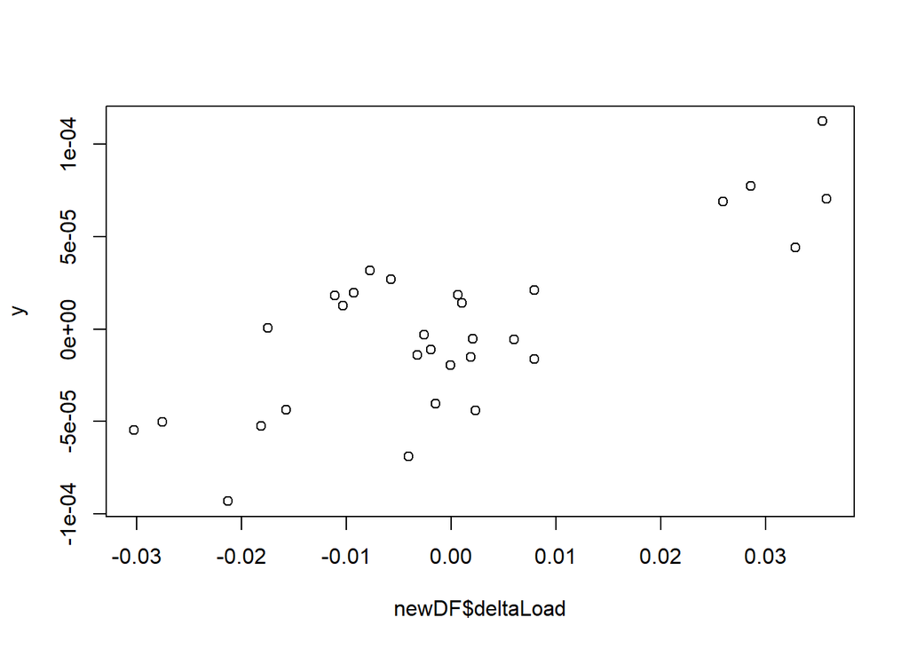

```r
### model visualization
# calculate partial residuals for deltaLoad
# these are the  residuals, minus the effect of detlaLoad
y <- residuals(m5, type = 'partial')[, "deltaLoad"]

# plot partial residuals with base R plotting
plot(x = newDF$deltaLoad, y = y)
```

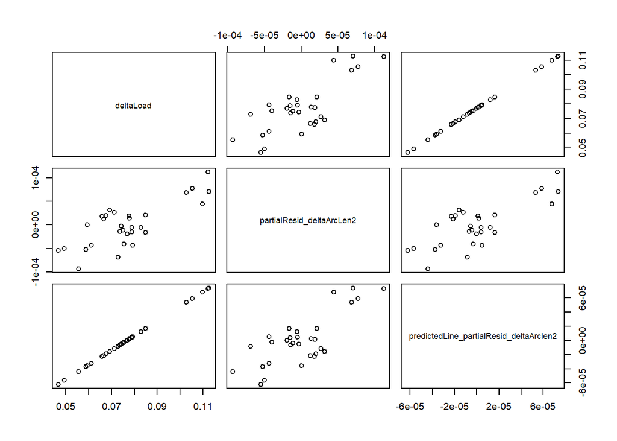

```r
predictedLine_partialResid_deltaArclen2 = predict(lm(y ~ newDF$deltaLoad))

# plot partial residuals with base R plotting
arcLenDF <- data.frame(deltaLoad = newDF$dLoad_nonCent, partialResid_deltaArcLen2 = y,
                       predictedLine_partialResid_deltaArclen2)
plot(arcLenDF)
```

```r
# write file for partial residuals
write_csv(x = arcLenDF,
          file.path(dataOut,
                    "PartialResiduals_deltaArcLen_Fig4a.csv"))

# double check to make sure the slope for partial residual plots are the
# same as in the original regression
summary(lm(y ~ newDF$deltaLoad))
```

```
##
## Call:
## lm(formula = y ~ newDF$deltaLoad)
##
## Residuals:
##        Min         1Q     Median         3Q        Max
## -6.041e-05 -1.877e-05 -2.970e-07  1.831e-05  4.778e-05
##
## Coefficients:
##                  Estimate Std. Error t value Pr(>|t|)
## (Intercept)     2.607e-21  5.482e-06   0.000        1
## newDF$deltaLoad 2.059e-03  3.213e-04   6.409 6.14e-07 ***
## ---
## Signif. codes:  0 '***' 0.001 '**' 0.01 '*' 0.05 '.' 0.1 ' ' 1
##
## Residual standard error: 3.003e-05 on 28 degrees of freedom
## Multiple R-squared:  0.5946, Adjusted R-squared:  0.5801
## F-statistic: 41.07 on 1 and 28 DF,  p-value: 6.137e-07
```

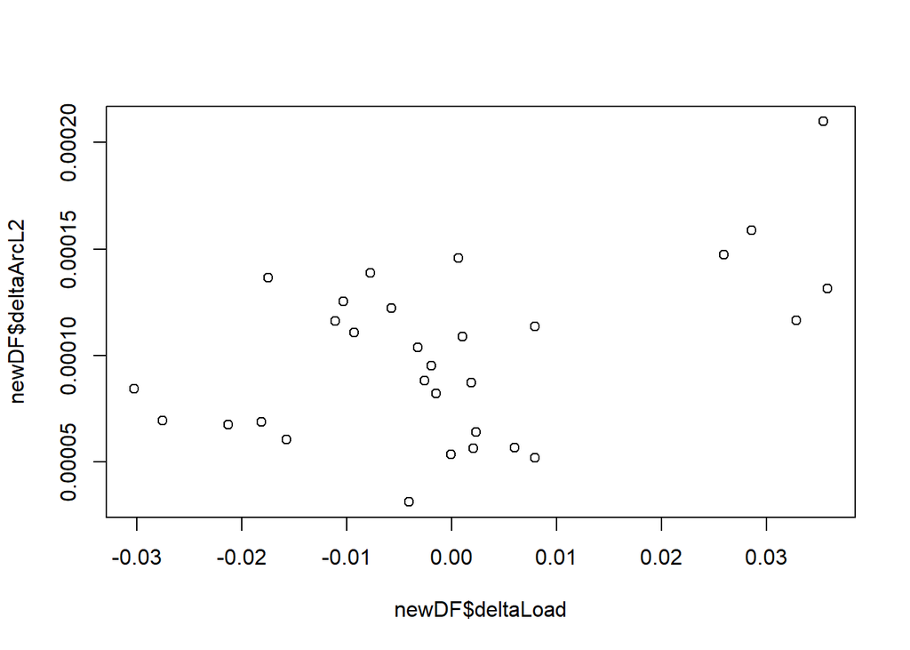

```r
# this is what the raw data look like
plot(x = newDF$deltaLoad, y = newDF$deltaArcL2)
```

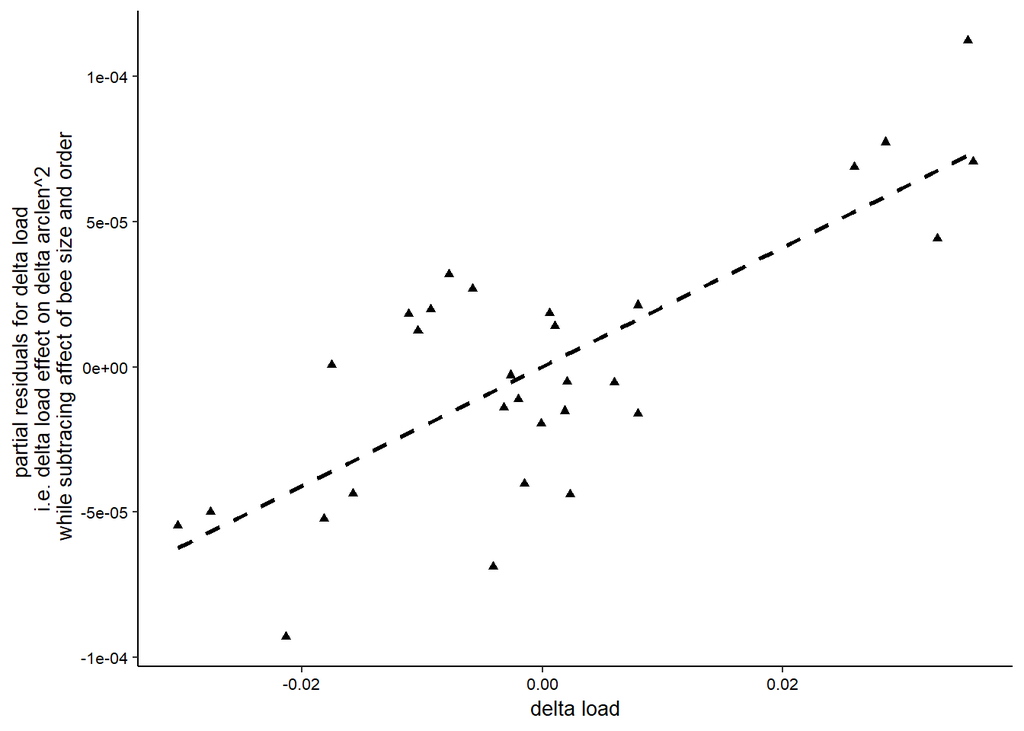

```r
# y axis isn't easily interpretable
ggplot(newDF, aes(x= deltaLoad, y = y)) +
     geom_point(shape = 17) +
     labs(x = "delta load", y = "partial residuals for delta load \n i.e. delta load effect on delta arclen^2 \n while subtracing affect of bee size and order") +
     stat_smooth(method = 'lm', se = FALSE, color = "black", lty = 2)
```

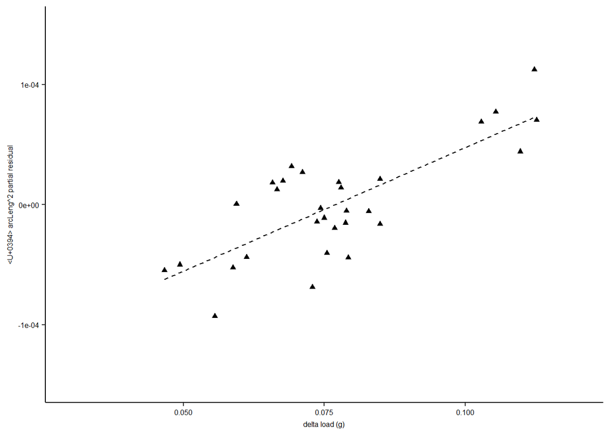

```r
fig4a <- ggplot(newDF, aes(x= dLoad_nonCent, y = y)) +
  geom_point(shape = 17) +
  xlim(c(0.03, 0.12)) +
  labs(x = "delta load (g)", y = "Δ arcLeng^2 partial residual" ) +
  stat_smooth(method = 'lm', se = FALSE, color = "black", lty = 2, size = 0.5) +
  scale_y_continuous(labels = scales::scientific, limits = c(-1.5e-4, 1.5e-4)) +
  theme(legend.title = element_blank(),
        legend.background = element_rect(colour = "black", size = 0.3),
        legend.position = c(0.8, 0.16),
        legend.text = element_text(size = 6),
        axis.text = element_text(size = 6),
        axis.title = element_text(size = 6),
        legend.key.size = unit(0.2, "cm"))
fig4a
```

```r
ggsave(filename = file.path(figDir, "fig4a.png"), width = 6.5/2, height = 2,
        plot = fig4a,
       units = "in", dpi = 500)
```

# Investigate how Δ load, bee size, and treatment order affected changes in freq^2 between light and heavy trials

```r
# fit full model
m1 <- lm(deltaFrq2 ~  (deltaLoad +  size_pc1 + order_1)^2 , data = newDF)

summary(m1)
```

```
##
## Call:
## lm(formula = deltaFrq2 ~ (deltaLoad + size_pc1 + order_1)^2,
##     data = newDF)
##
## Residuals:
##     Min      1Q  Median      3Q     Max
## -5367.6 -1317.8    16.2  1261.2  5799.0
##
## Coefficients:
##                               Estimate Std. Error t value Pr(>|t|)
## (Intercept)                     5679.7     1162.1   4.887 6.17e-05 ***
## deltaLoad                     -84630.0    74722.3  -1.133  0.26905
## size_pc1                         399.1      703.4   0.567  0.57594
## order_1loadedSecond            -5242.5     1682.5  -3.116  0.00486 **
## deltaLoad:size_pc1            -16886.5    18757.9  -0.900  0.37733
## deltaLoad:order_1loadedSecond  84250.6   151349.6   0.557  0.58313
## size_pc1:order_1loadedSecond    -544.4     1027.1  -0.530  0.60117
## ---
## Signif. codes:  0 '***' 0.001 '**' 0.01 '*' 0.05 '.' 0.1 ' ' 1
##
## Residual standard error: 2913 on 23 degrees of freedom
## Multiple R-squared:  0.452,  Adjusted R-squared:  0.309
## F-statistic: 3.162 on 6 and 23 DF,  p-value: 0.02069
```

```r
# some serious multicollinearity
# means we can't evaluate interactions very accurately (nor can we trust overall F test)
car::vif(m1)
```

```
##          deltaLoad           size_pc1            order_1
##           5.747806           6.378000           2.490903
## deltaLoad:size_pc1  deltaLoad:order_1   size_pc1:order_1
##           1.359346           5.698750           6.037125
```

```r
m2 <- update(m1, .~. - size_pc1:order_1)
anova(m1, m2)
```

```
## Analysis of Variance Table
##
## Model 1: deltaFrq2 ~ (deltaLoad + size_pc1 + order_1)^2
## Model 2: deltaFrq2 ~ deltaLoad + size_pc1 + order_1 + deltaLoad:size_pc1 +
##     deltaLoad:order_1
##   Res.Df       RSS Df Sum of Sq      F Pr(>F)
## 1     23 195161054
## 2     24 197544826 -1  -2383773 0.2809 0.6012
```

```r
car::vif(m2) # acceptable
```

```
##          deltaLoad           size_pc1            order_1
##           3.797101           3.353417           2.448371
## deltaLoad:size_pc1  deltaLoad:order_1
##           1.342420           2.075666
```

```r
summary(m2)
```

```
##
## Call:
## lm(formula = deltaFrq2 ~ deltaLoad + size_pc1 + order_1 + deltaLoad:size_pc1 +
##     deltaLoad:order_1, data = newDF)
##
## Residuals:
##     Min      1Q  Median      3Q     Max
## -5508.8 -1482.0    51.6  1395.4  6055.9
##
## Coefficients:
##                               Estimate Std. Error t value Pr(>|t|)
## (Intercept)                     5466.1     1073.5   5.092  3.3e-05 ***
## deltaLoad                     -61557.5    59816.3  -1.029   0.3137
## size_pc1                         142.4      502.3   0.283   0.7793
## order_1loadedSecond            -5359.0     1642.9  -3.262   0.0033 **
## deltaLoad:size_pc1            -17995.9    18359.3  -0.980   0.3368
## deltaLoad:order_1loadedSecond  20287.3    89963.2   0.226   0.8235
## ---
## Signif. codes:  0 '***' 0.001 '**' 0.01 '*' 0.05 '.' 0.1 ' ' 1
##
## Residual standard error: 2869 on 24 degrees of freedom
## Multiple R-squared:  0.4453, Adjusted R-squared:  0.3298
## F-statistic: 3.853 on 5 and 24 DF,  p-value: 0.01051
```

```r
m3 <- update(m2, .~. - deltaLoad:order_1)
anova(m2, m3)
```

```
## Analysis of Variance Table
##
## Model 1: deltaFrq2 ~ deltaLoad + size_pc1 + order_1 + deltaLoad:size_pc1 +
##     deltaLoad:order_1
## Model 2: deltaFrq2 ~ deltaLoad + size_pc1 + order_1 + deltaLoad:size_pc1
##   Res.Df       RSS Df Sum of Sq      F Pr(>F)
## 1     24 197544826
## 2     25 197963402 -1   -418576 0.0509 0.8235
```

```r
summary(m3)
```

```
##
## Call:
## lm(formula = deltaFrq2 ~ deltaLoad + size_pc1 + order_1 + deltaLoad:size_pc1,
##     data = newDF)
##
## Residuals:
##     Min      1Q  Median      3Q     Max
## -5602.8 -1544.6   210.1  1376.3  6049.6
##
## Coefficients:
##                     Estimate Std. Error t value Pr(>|t|)
## (Intercept)           5511.5     1034.3   5.329  1.6e-05 ***
## deltaLoad           -59426.2    57932.9  -1.026 0.314820
## size_pc1               170.3      477.5   0.357 0.724424
## order_1loadedSecond  -5510.4     1470.7  -3.747 0.000946 ***
## deltaLoad:size_pc1  -19689.5    16431.8  -1.198 0.242053
## ---
## Signif. codes:  0 '***' 0.001 '**' 0.01 '*' 0.05 '.' 0.1 ' ' 1
##
## Residual standard error: 2814 on 25 degrees of freedom
## Multiple R-squared:  0.4441, Adjusted R-squared:  0.3552
## F-statistic: 4.994 on 4 and 25 DF,  p-value: 0.004251
```

```r
m4 <- update(m3, .~. - deltaLoad:size_pc1)
anova(m3, m4)
```

```
## Analysis of Variance Table
##
## Model 1: deltaFrq2 ~ deltaLoad + size_pc1 + order_1 + deltaLoad:size_pc1
## Model 2: deltaFrq2 ~ deltaLoad + size_pc1 + order_1
##   Res.Df       RSS Df Sum of Sq      F Pr(>F)
## 1     25 197963402
## 2     26 209333014 -1 -11369611 1.4358 0.2421
```

```r
summary(m4)
```

```
##
## Call:
## lm(formula = deltaFrq2 ~ deltaLoad + size_pc1 + order_1, data = newDF)
##
## Residuals:
##     Min      1Q  Median      3Q     Max
## -5275.5 -1551.0   108.1  1498.9  6484.0
##
## Coefficients:
##                     Estimate Std. Error t value Pr(>|t|)
## (Intercept)           4979.2      941.8   5.287 1.58e-05 ***
## deltaLoad           -68182.7    57949.8  -1.177  0.25002
## size_pc1               268.9      474.3   0.567  0.57562
## order_1loadedSecond  -5325.5     1474.8  -3.611  0.00128 **
## ---
## Signif. codes:  0 '***' 0.001 '**' 0.01 '*' 0.05 '.' 0.1 ' ' 1
##
## Residual standard error: 2837 on 26 degrees of freedom
## Multiple R-squared:  0.4122, Adjusted R-squared:  0.3444
## F-statistic: 6.078 on 3 and 26 DF,  p-value: 0.002817
```

```r
m5 <- update(m4, .~. - size_pc1)
anova(m4,m5)
```

```
## Analysis of Variance Table
##
## Model 1: deltaFrq2 ~ deltaLoad + size_pc1 + order_1
## Model 2: deltaFrq2 ~ deltaLoad + order_1
##   Res.Df       RSS Df Sum of Sq      F Pr(>F)
## 1     26 209333014
## 2     27 211920854 -1  -2587840 0.3214 0.5756
```

```r
summary(m5)
```

```
##
## Call:
## lm(formula = deltaFrq2 ~ deltaLoad + order_1, data = newDF)
##
## Residuals:
##     Min      1Q  Median      3Q     Max
## -5077.0 -1823.5   227.5  1536.0  6826.2
##
## Coefficients:
##                     Estimate Std. Error t value Pr(>|t|)
## (Intercept)           4698.0      790.5   5.943 2.46e-06 ***
## deltaLoad           -41360.2    33040.8  -1.252  0.22138
## order_1loadedSecond  -4798.3     1130.1  -4.246  0.00023 ***
## ---
## Signif. codes:  0 '***' 0.001 '**' 0.01 '*' 0.05 '.' 0.1 ' ' 1
##
## Residual standard error: 2802 on 27 degrees of freedom
## Multiple R-squared:  0.4049, Adjusted R-squared:  0.3609
## F-statistic: 9.187 on 2 and 27 DF,  p-value: 0.0009048
```

```r
summary(m5) # final model for paper, b/c we're interested in load
```

```
##
## Call:
## lm(formula = deltaFrq2 ~ deltaLoad + order_1, data = newDF)
##
## Residuals:
##     Min      1Q  Median      3Q     Max
## -5077.0 -1823.5   227.5  1536.0  6826.2
##
## Coefficients:
##                     Estimate Std. Error t value Pr(>|t|)
## (Intercept)           4698.0      790.5   5.943 2.46e-06 ***
## deltaLoad           -41360.2    33040.8  -1.252  0.22138
## order_1loadedSecond  -4798.3     1130.1  -4.246  0.00023 ***
## ---
## Signif. codes:  0 '***' 0.001 '**' 0.01 '*' 0.05 '.' 0.1 ' ' 1
##
## Residual standard error: 2802 on 27 degrees of freedom
## Multiple R-squared:  0.4049, Adjusted R-squared:  0.3609
## F-statistic: 9.187 on 2 and 27 DF,  p-value: 0.0009048
```

```r
car::vif(m5)
```

```
## deltaLoad   order_1
##  1.214948  1.214948
```

```r
# copy to clipboard, to paste into excel
write.table(data.frame(summary(m5)$coef),"clipboard",sep="\t")

m8 <- update(m5, .~. - deltaLoad)
anova(m5, m8)
```

```
## Analysis of Variance Table
##
## Model 1: deltaFrq2 ~ deltaLoad + order_1
## Model 2: deltaFrq2 ~ order_1
##   Res.Df       RSS Df Sum of Sq     F Pr(>F)
## 1     27 211920854
## 2     28 224219986 -1 -12299132 1.567 0.2214
```

```r
summary(m8)
```

```
##
## Call:
## lm(formula = deltaFrq2 ~ order_1, data = newDF)
##
## Residuals:
##     Min      1Q  Median      3Q     Max
## -5175.0 -1490.8   559.8  1220.0  7464.9
##
## Coefficients:
##                     Estimate Std. Error t value Pr(>|t|)
## (Intercept)           4380.7      756.3   5.792 3.21e-06 ***
## order_1loadedSecond  -4203.3     1035.6  -4.059 0.000359 ***
## ---
## Signif. codes:  0 '***' 0.001 '**' 0.01 '*' 0.05 '.' 0.1 ' ' 1
##
## Residual standard error: 2830 on 28 degrees of freedom
## Multiple R-squared:  0.3704, Adjusted R-squared:  0.3479
## F-statistic: 16.47 on 1 and 28 DF,  p-value: 0.0003589
```

```r
m9 <- update(m8, .~. - order_1)
anova(m5, m9) # p-value for order
```

```
## Analysis of Variance Table
##
## Model 1: deltaFrq2 ~ deltaLoad + order_1
## Model 2: deltaFrq2 ~ 1
##   Res.Df       RSS Df  Sum of Sq      F    Pr(>F)
## 1     27 211920854
## 2     29 356135971 -2 -144215117 9.1869 0.0009048 ***
## ---
## Signif. codes:  0 '***' 0.001 '**' 0.01 '*' 0.05 '.' 0.1 ' ' 1
```

```r
summary(m8)
```

```
##
## Call:
## lm(formula = deltaFrq2 ~ order_1, data = newDF)
##
## Residuals:
##     Min      1Q  Median      3Q     Max
## -5175.0 -1490.8   559.8  1220.0  7464.9
##
## Coefficients:
##                     Estimate Std. Error t value Pr(>|t|)
## (Intercept)           4380.7      756.3   5.792 3.21e-06 ***
## order_1loadedSecond  -4203.3     1035.6  -4.059 0.000359 ***
## ---
## Signif. codes:  0 '***' 0.001 '**' 0.01 '*' 0.05 '.' 0.1 ' ' 1
##
## Residual standard error: 2830 on 28 degrees of freedom
## Multiple R-squared:  0.3704, Adjusted R-squared:  0.3479
## F-statistic: 16.47 on 1 and 28 DF,  p-value: 0.0003589
```

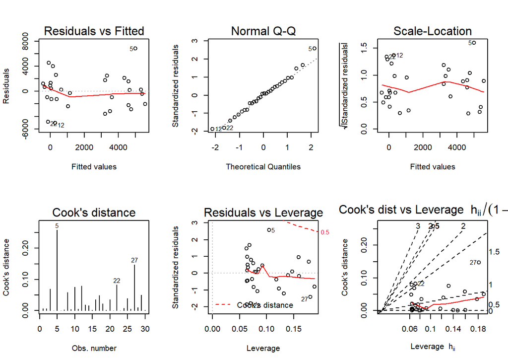

```r
### model diagnostics
par(mfrow = c(2,3))
plot(m5, which = 1:6) # no glaring violations
```

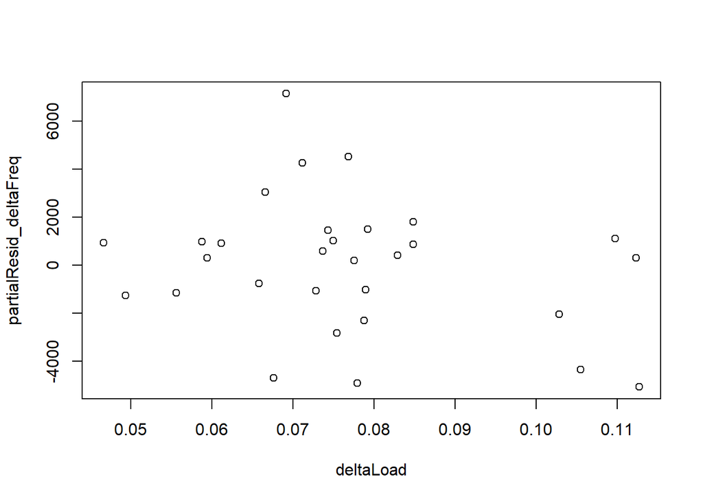

```r
par(mfrow = c(1,1))


### model visualization
# calculate partial residuals for deltaLoad
# these are the  residuals, minus the effect of detlaLoad
y <- residuals(m5, type = 'partial')[, "deltaLoad"]

# plot partial residuals with base R plotting
freqDF <- data.frame(deltaLoad = newDF$dLoad_nonCent, partialResid_deltaFreq = y)
plot(freqDF)
```

```r
# write file for partial residuals
write_csv(x = freqDF,
          file.path(dataOut,
                    "PartialResiduals_deltaFreq2_Fig4b.csv"))


# double check to make sure the slope for partial residual plots are the
# same as in the original regression
summary(lm(y ~ newDF$deltaLoad))
```

```
##
## Call:
## lm(formula = y ~ newDF$deltaLoad)
##
## Residuals:
##     Min      1Q  Median      3Q     Max
## -5077.0 -1823.5   227.5  1536.0  6826.2
##
## Coefficients:
##                   Estimate Std. Error t value Pr(>|t|)
## (Intercept)     -2.064e-13  5.023e+02   0.000    1.000
## newDF$deltaLoad -4.136e+04  2.944e+04  -1.405    0.171
##
## Residual standard error: 2751 on 28 degrees of freedom
## Multiple R-squared:  0.06587,    Adjusted R-squared:  0.03251
## F-statistic: 1.974 on 1 and 28 DF,  p-value: 0.171
```

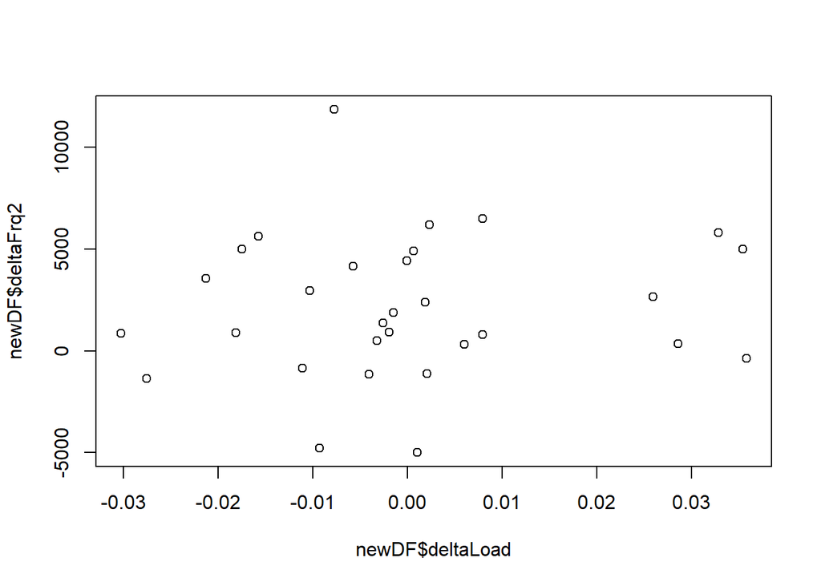

```r
# this is what the raw data look like
plot(x = newDF$deltaLoad, y = newDF$deltaFrq2)
```

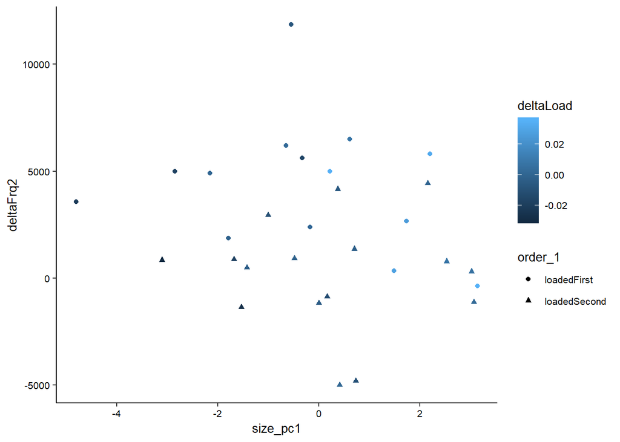

```r
# plot with ggplot2
# plot raw data w/ ggplot
ggplot(newDF, aes(x= size_pc1, y = deltaFrq2, color = deltaLoad, shape = order_1)) +
     geom_point()
```

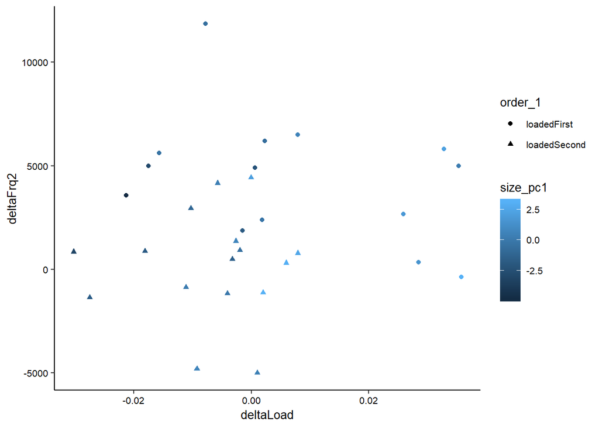

```r
ggplot(newDF, aes(x= deltaLoad, y = deltaFrq2, color = size_pc1, shape = order_1)) +
     geom_point()
```

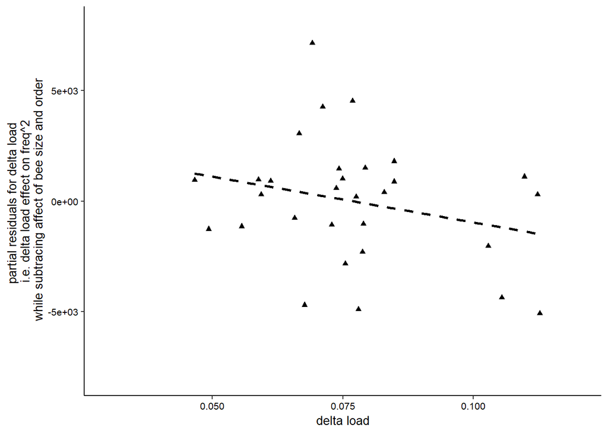

```r
# y axis isn't easily interpretable
ggplot(newDF, aes(x= dLoad_nonCent, y = y)) +
     geom_point(shape = 17) +
  xlim(c(0.03, 0.12)) +
     labs(x = "delta load", y = "partial residuals for delta load \n i.e. delta load effect on freq^2 \n while subtracing affect of bee size and order") +
     stat_smooth(method = 'lm', se = FALSE, color = "black", lty = 2) +
     scale_y_continuous(labels = scales::scientific, limits = c(-8e3, 8e3))
```

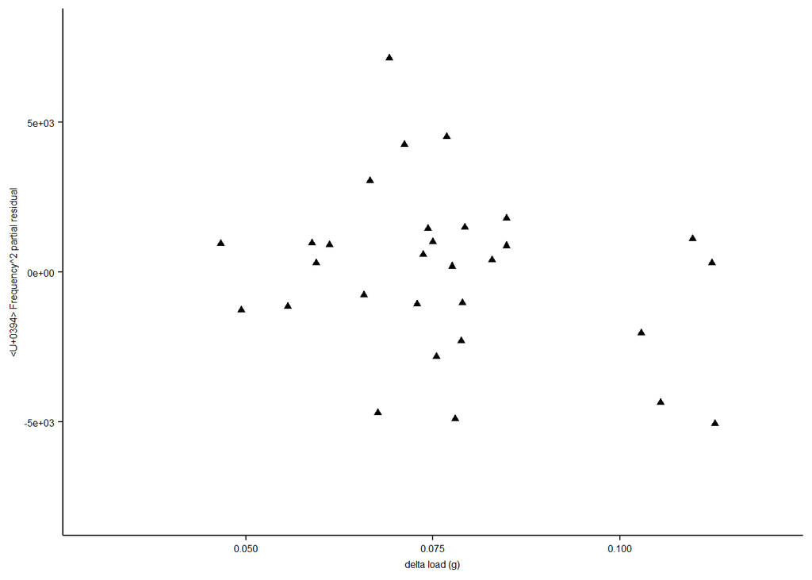

```r
fig4b <- ggplot(newDF, aes(x= dLoad_nonCent, y = y)) +
  geom_point(shape = 17) +
  xlim(c(0.03, 0.12)) +
  labs(x = "delta load (g)", y = "Δ Frequency^2 partial residual" ) +
  #stat_smooth(method = 'lm', se = FALSE, color = "black", lty = 2, size = 0.5) +
  scale_y_continuous(labels = scales::scientific, limits = c(-8e3, 8e3)) +
  theme(legend.title = element_blank(),
        legend.background = element_rect(colour = "black", size = 0.3),
        legend.position = c(0.8, 0.16),
        legend.text = element_text(size = 6),
        axis.text = element_text(size = 6),
        axis.title = element_text(size = 6),
        legend.key.size = unit(0.2, "cm"))
fig4b
```

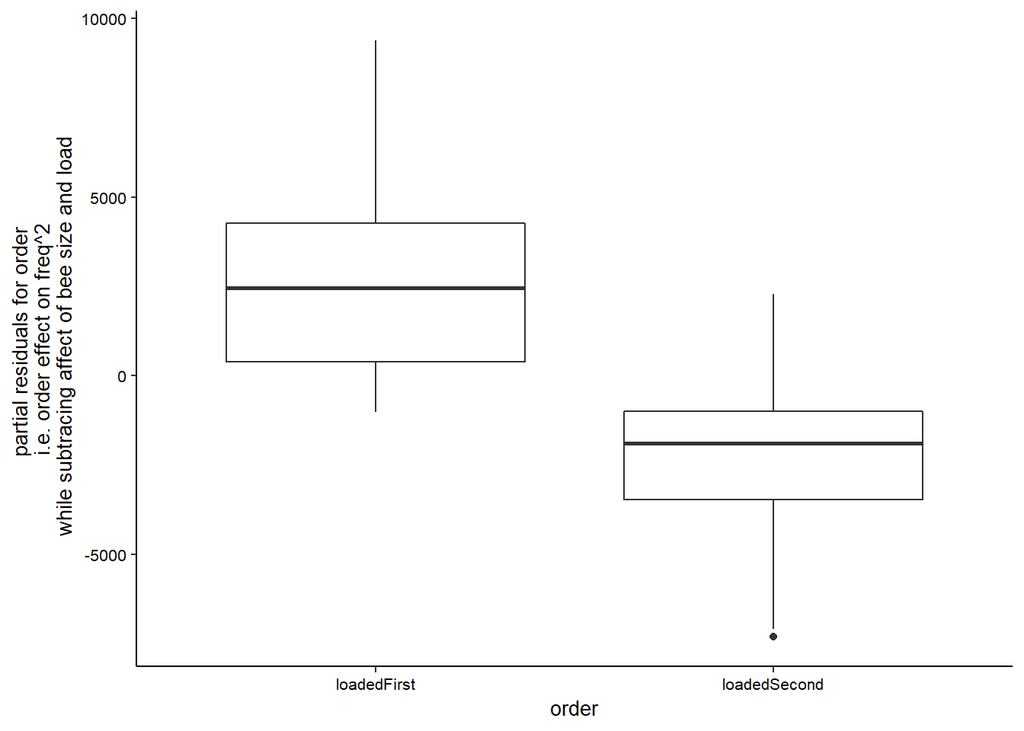

```r
ggsave(filename = file.path(figDir, "fig4b.png"), width = 6.5/2, height = 2,
        plot = fig4b,
       units = "in", dpi = 500)

# partial residuals for order

y <- residuals(m5, type = 'partial')[, "order_1"]

ggplot(newDF, aes(x= order_1, y = y)) +
     geom_boxplot() +
     labs(x = "order",
          y = "partial residuals for order \n i.e. order effect on freq^2 \n while subtracing affect of bee size and load") +
     stat_smooth(method = 'lm', se = FALSE)
```

```r
# holding delta load constant, if a bee was loaded second, then it would have a much lower freq^2 than if it was loaded first

summary(m5)
```

```
##
## Call:
## lm(formula = deltaFrq2 ~ deltaLoad + order_1, data = newDF)
##
## Residuals:
##     Min      1Q  Median      3Q     Max
## -5077.0 -1823.5   227.5  1536.0  6826.2
##
## Coefficients:
##                     Estimate Std. Error t value Pr(>|t|)
## (Intercept)           4698.0      790.5   5.943 2.46e-06 ***
## deltaLoad           -41360.2    33040.8  -1.252  0.22138
## order_1loadedSecond  -4798.3     1130.1  -4.246  0.00023 ***
## ---
## Signif. codes:  0 '***' 0.001 '**' 0.01 '*' 0.05 '.' 0.1 ' ' 1
##
## Residual standard error: 2802 on 27 degrees of freedom
## Multiple R-squared:  0.4049, Adjusted R-squared:  0.3609
## F-statistic: 9.187 on 2 and 27 DF,  p-value: 0.0009048
```

# we investigated the change in metabolic rate between light and heavy loading trials

```r
mm1 <- lm(deltaMetR ~ deltaFrq2 + deltaArcL2 +
            deltaLoad + size_pc1, data = newDF)
car::vif(mm1)
```

```
##  deltaFrq2 deltaArcL2  deltaLoad   size_pc1
##   1.141251   1.809848   3.407011   2.692611
```

```r
summary(mm1)
```

```
##
## Call:
## lm(formula = deltaMetR ~ deltaFrq2 + deltaArcL2 + deltaLoad +
##     size_pc1, data = newDF)
##
## Residuals:
##     Min      1Q  Median      3Q     Max
## -1.4709 -0.8024 -0.1394  0.3526  3.6221
##
## Coefficients:
##               Estimate Std. Error t value Pr(>|t|)
## (Intercept)  2.307e+00  7.553e-01   3.054  0.00530 **
## deltaFrq2    1.814e-04  6.481e-05   2.799  0.00973 **
## deltaArcL2  -4.491e+03  7.231e+03  -0.621  0.54018
## deltaLoad    2.958e+01  2.261e+01   1.308  0.20264
## size_pc1    -4.438e-03  1.796e-01  -0.025  0.98048
## ---
## Signif. codes:  0 '***' 0.001 '**' 0.01 '*' 0.05 '.' 0.1 ' ' 1
##
## Residual standard error: 1.145 on 25 degrees of freedom
## Multiple R-squared:  0.3493, Adjusted R-squared:  0.2452
## F-statistic: 3.355 on 4 and 25 DF,  p-value: 0.02493
```

```r
mm2 <- update(mm1, .~. - size_pc1)
anova(mm1, mm2)
```

```
## Analysis of Variance Table
##
## Model 1: deltaMetR ~ deltaFrq2 + deltaArcL2 + deltaLoad + size_pc1
## Model 2: deltaMetR ~ deltaFrq2 + deltaArcL2 + deltaLoad
##   Res.Df    RSS Df   Sum of Sq     F Pr(>F)
## 1     25 32.766
## 2     26 32.766 -1 -0.00080015 6e-04 0.9805
```

```r
summary(mm2) # final model for paper
```

```
##
## Call:
## lm(formula = deltaMetR ~ deltaFrq2 + deltaArcL2 + deltaLoad,
##     data = newDF)
##
## Residuals:
##     Min      1Q  Median      3Q     Max
## -1.4654 -0.7993 -0.1402  0.3471  3.6310
##
## Coefficients:
##               Estimate Std. Error t value Pr(>|t|)
## (Intercept)  2.297e+00  6.384e-01   3.598  0.00132 **
## deltaFrq2    1.818e-04  6.154e-05   2.954  0.00657 **
## deltaArcL2  -4.405e+03  6.217e+03  -0.709  0.48493
## deltaLoad    2.914e+01  1.376e+01   2.118  0.04391 *
## ---
## Signif. codes:  0 '***' 0.001 '**' 0.01 '*' 0.05 '.' 0.1 ' ' 1
##
## Residual standard error: 1.123 on 26 degrees of freedom
## Multiple R-squared:  0.3493, Adjusted R-squared:  0.2742
## F-statistic: 4.653 on 3 and 26 DF,  p-value: 0.009855
```

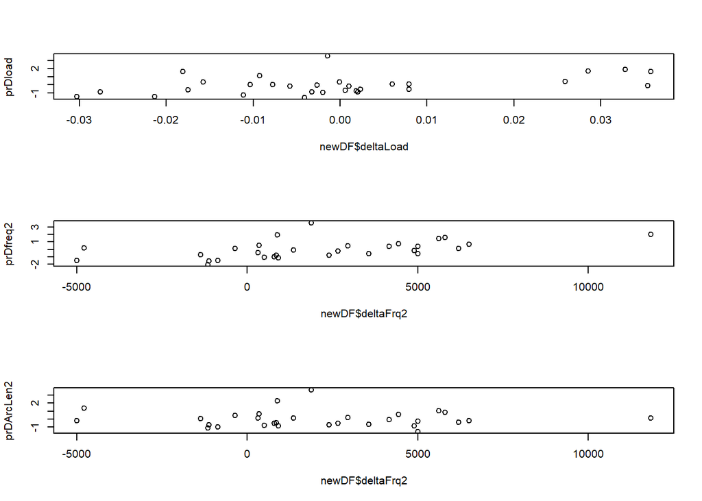

```r
#mm2 <- update(mm2, .~. - deltaArcL2)



# final model for paper, since arclen and freq were a priori variables of interest
# note mm3 is the model that includes delta arcleng2
# copy to clipboard, to paste into excel
write.table(data.frame(summary(mm2)$coef),"clipboard",sep="\t")

# calculate partial residuals deltaload and deltafreq2 and deltaarcL2
prDload <- residuals(mm2, type = 'partial')[, "deltaLoad"]
partialPreds_Dload <- predict(lm(prDload ~ newDF$deltaLoad))
prDfreq2 <- residuals(mm2, type = 'partial')[, "deltaFrq2"]
partialPreds_deltaFreq2 <- predict(lm(prDfreq2 ~ newDF$deltaFrq2))
prDArcLen2 <- residuals(mm2, type = 'partial')[, "deltaArcL2"]

# save partial residuals
partialMetRateDF <- data.frame(deltaLoad = newDF$dLoad_nonCent,
                               partialDeltaLoad = prDload,
                               predictedLine_partials_deltaLoad = partialPreds_Dload,
                               deltaFreq2 = newDF$deltaFrq2,
                               partialDeltaFreq2 = prDfreq2,
                               predictedLine_partials_deltaFreq2 = partialPreds_deltaFreq2,
                               deltaArcLen2 = newDF$deltaArcL2,
                               partialDeltaArcLen2 = prDArcLen2
                               )
write_csv(partialMetRateDF,
          file.path(dataOut, "PartialResid_MetRate_Fig5a_5b_5c.csv"))


# plot partial residuals with base R plotting
par(mfrow = c(3,1))
plot(x = newDF$deltaLoad, y = prDload)
plot(x = newDF$deltaFrq2, y = prDfreq2)
plot(x = newDF$deltaFrq2, y = prDArcLen2)
```

```r
par(mfrow = c(1,1))


## model diagnostics
car::vif(mm2)
```

```
##  deltaFrq2 deltaArcL2  deltaLoad
##   1.070066   1.391389   1.312613
```

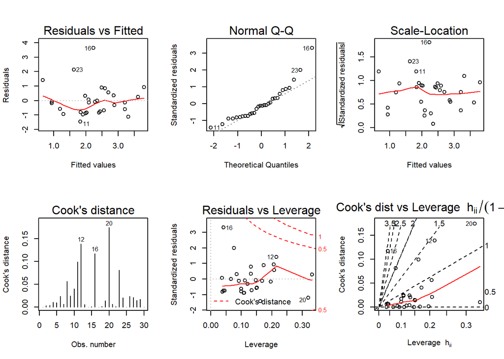

```r
par(mfrow = c(2,3))
plot(mm2, which = 1:6) # no glaring violations
```

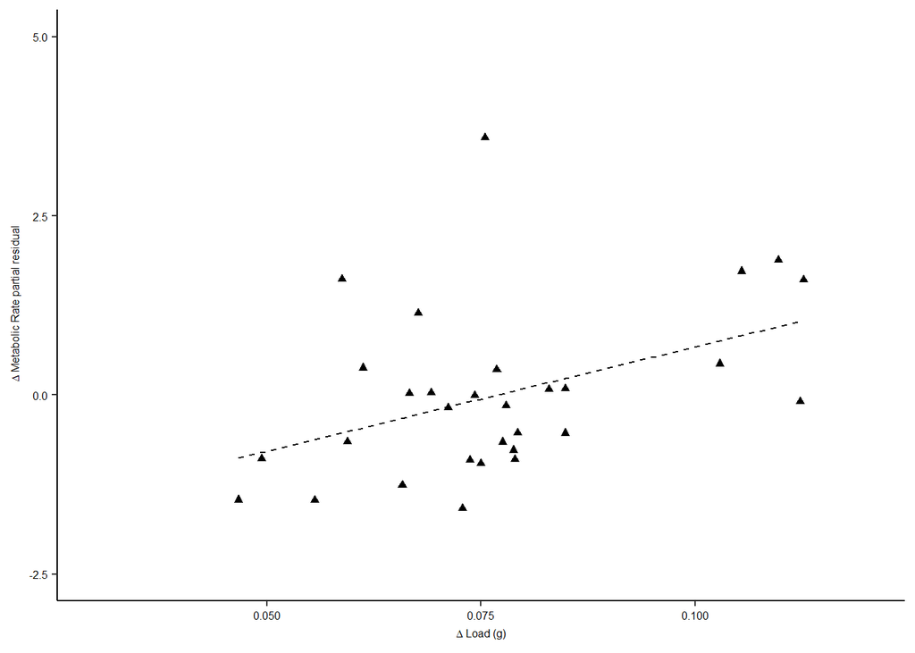

```r
par(mfrow = c(1,1))



### model visualization
fig5a <- ggplot(partialMetRateDF, aes(x= deltaLoad, y = partialDeltaLoad)) +
  geom_point(shape = 17) +
  geom_line(aes(x = deltaLoad, y = predictedLine_partials_deltaLoad), lty = 2, size = 0.5) +
  xlim(c(0.03, 0.12)) +
  labs(x = expression(Delta~"Load (g)"),
       y = expression(Delta~"Metabolic Rate partial residual" )) +
  #stat_smooth(method = 'lm', se = FALSE, color = "black", lty = 2, size = 0.5) +
  scale_y_continuous(limits = c(-2.5, 5)) +
  theme(legend.title = element_blank(),
        legend.background = element_rect(colour = "black", size = 0.3),
        legend.position = c(0.8, 0.16),
        legend.text = element_text(size = 6),
        axis.text = element_text(size = 6),
        axis.title = element_text(size = 6),
        legend.key.size = unit(0.2, "cm"))
fig5a
```

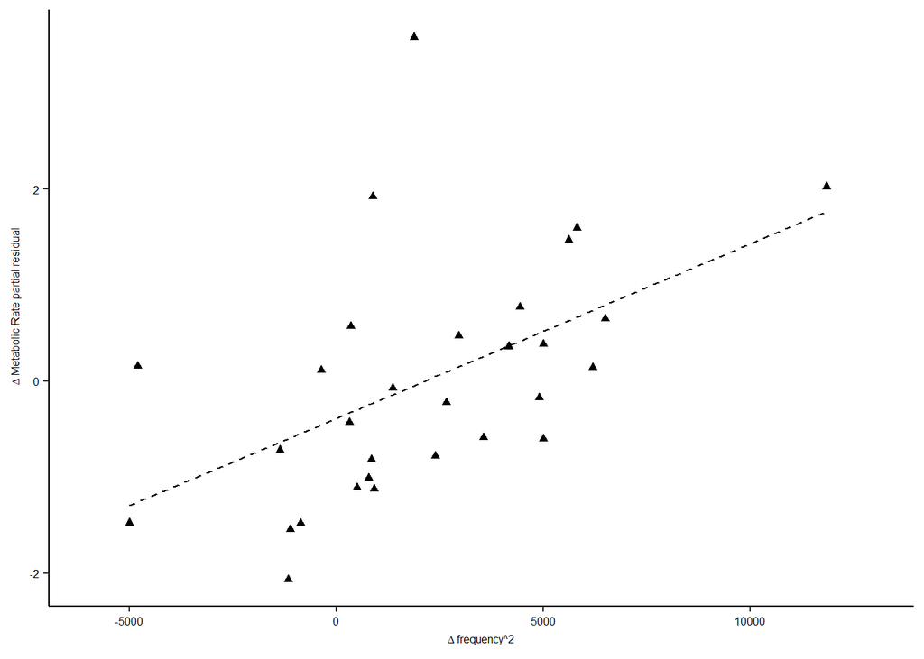

```r
ggsave(filename = file.path(figDir, "fig5a.png"), width = 6.5/2, height = 2,
        plot = fig5a,
       units = "in", dpi = 500)

fig5b <- ggplot(partialMetRateDF, aes(x= deltaFreq2, y = partialDeltaFreq2)) +
  geom_point(shape = 17) +
  xlim(c(-6*10^3, 13e3)) +
  labs(x = expression(Delta~"frequency^2"), y = expression(Delta~"Metabolic Rate partial residual") ) +
  geom_line(aes(x = deltaFreq2, y = partialPreds_deltaFreq2),
            color = "black", lty = 2, size = 0.5) +
  theme(legend.title = element_blank(),
        legend.background = element_rect(colour = "black", size = 0.3),
        legend.position = c(0.8, 0.16),
        legend.text = element_text(size = 6),
        axis.text = element_text(size = 6),
        axis.title = element_text(size = 6),
        legend.key.size = unit(0.2, "cm"))
fig5b
```

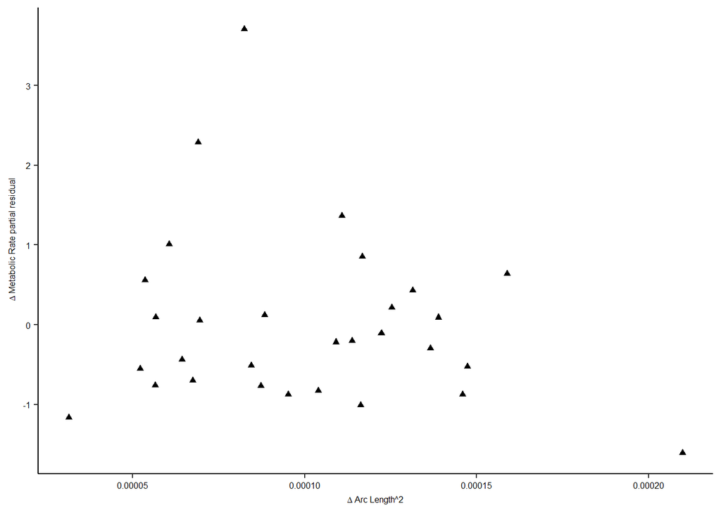

```r
ggsave(filename = file.path(figDir, "fig5b.png"), width = 6.5/2, height = 2,
        plot = fig5b,
       units = "in", dpi = 500)



fig5c <- ggplot(partialMetRateDF, aes(x= deltaArcLen2, y = partialDeltaArcLen2)) +
  geom_point(shape = 17) +
  #xlim(c(-6*10^3, 13e3)) +
  labs(x = expression(Delta~"Arc Length^2"), y = expression(Delta~"Metabolic Rate partial residual") ) +
  #geom_line(aes(x = deltaLoad, y = predictedLine_partials_deltaLoad), lty = 2, size = 0.5) +
  theme(legend.title = element_blank(),
        legend.background = element_rect(colour = "black", size = 0.3),
        legend.position = c(0.8, 0.16),
        legend.text = element_text(size = 6),
        axis.text = element_text(size = 6),
        axis.title = element_text(size = 6),
        legend.key.size = unit(0.2, "cm"))
fig5c
```

```r
ggsave(filename = file.path(figDir, "fig5c.png"), width = 6.5/2, height = 2,
        plot = fig5c,
       units = "in", dpi = 500)
```

# modeled the change in metabolic rate per 1% of additional loading

```r
summary(newDF$avgPercLoad)
```

```
##    Min. 1st Qu.  Median    Mean 3rd Qu.    Max.
##   35.31   49.73   54.98   56.66   66.26   79.77
```

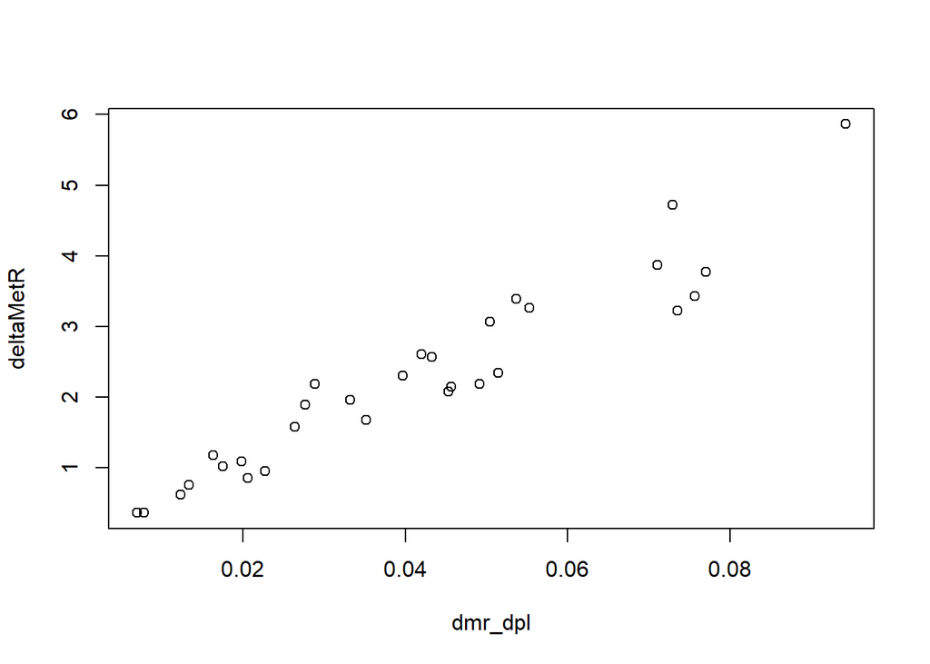

```r
newDF <- within(newDF, {dmr_dpl = deltaMetR / deltaPercLoad})
plot(deltaMetR  ~ dmr_dpl, data = newDF)
```

```r
mod1 <- lm(dmr_dpl  ~ avgPercLoad + order_1 + size_pc1, data = newDF)
summary(mod1)
```

```
##
## Call:
## lm(formula = dmr_dpl ~ avgPercLoad + order_1 + size_pc1, data = newDF)
##
## Residuals:
##       Min        1Q    Median        3Q       Max
## -0.025580 -0.011566 -0.004357  0.009067  0.043391
##
## Coefficients:
##                       Estimate Std. Error t value Pr(>|t|)
## (Intercept)          0.1078453  0.0158826   6.790 3.31e-07 ***
## avgPercLoad         -0.0010569  0.0002784  -3.796 0.000794 ***
## order_1loadedSecond -0.0131290  0.0066538  -1.973 0.059196 .
## size_pc1             0.0014674  0.0017912   0.819 0.420121
## ---
## Signif. codes:  0 '***' 0.001 '**' 0.01 '*' 0.05 '.' 0.1 ' ' 1
##
## Residual standard error: 0.01773 on 26 degrees of freedom
## Multiple R-squared:  0.4844, Adjusted R-squared:  0.4249
## F-statistic: 8.141 on 3 and 26 DF,  p-value: 0.0005502
```

```r
mod2 <- update(mod1, .~. - size_pc1)
anova(mod1, mod2) # remove size_pc1
```

```
## Analysis of Variance Table
##
## Model 1: dmr_dpl ~ avgPercLoad + order_1 + size_pc1
## Model 2: dmr_dpl ~ avgPercLoad + order_1
##   Res.Df       RSS Df   Sum of Sq      F Pr(>F)
## 1     26 0.0081723
## 2     27 0.0083833 -1 -0.00021093 0.6711 0.4201
```

```r
summary(mod2)
```

```
##
## Call:
## lm(formula = dmr_dpl ~ avgPercLoad + order_1, data = newDF)
##
## Residuals:
##       Min        1Q    Median        3Q       Max
## -0.030196 -0.012515 -0.003418  0.009765  0.040799
##
## Coefficients:
##                       Estimate Std. Error t value Pr(>|t|)
## (Intercept)          0.1111362  0.0152723   7.277 7.93e-08 ***
## avgPercLoad         -0.0011242  0.0002644  -4.253 0.000226 ***
## order_1loadedSecond -0.0121420  0.0065038  -1.867 0.072809 .
## ---
## Signif. codes:  0 '***' 0.001 '**' 0.01 '*' 0.05 '.' 0.1 ' ' 1
##
## Residual standard error: 0.01762 on 27 degrees of freedom
## Multiple R-squared:  0.471,  Adjusted R-squared:  0.4319
## F-statistic: 12.02 on 2 and 27 DF,  p-value: 0.0001846
```

```r
mod3 <- update(mod2, .~. - order_1)
anova(mod2, mod3) # remove order
```

```
## Analysis of Variance Table
##
## Model 1: dmr_dpl ~ avgPercLoad + order_1
## Model 2: dmr_dpl ~ avgPercLoad
##   Res.Df       RSS Df  Sum of Sq      F  Pr(>F)
## 1     27 0.0083833
## 2     28 0.0094654 -1 -0.0010822 3.4854 0.07281 .
## ---
## Signif. codes:  0 '***' 0.001 '**' 0.01 '*' 0.05 '.' 0.1 ' ' 1
```

```r
summary(mod3) # final model for paper
```

```
##
## Call:
## lm(formula = dmr_dpl ~ avgPercLoad, data = newDF)
##
## Residuals:
##       Min        1Q    Median        3Q       Max
## -0.026590 -0.011771 -0.000679  0.011114  0.046931
##
## Coefficients:
##               Estimate Std. Error t value Pr(>|t|)
## (Intercept)  0.1082986  0.0158566   6.830 2.02e-07 ***
## avgPercLoad -0.0011884  0.0002735  -4.345 0.000165 ***
## ---
## Signif. codes:  0 '***' 0.001 '**' 0.01 '*' 0.05 '.' 0.1 ' ' 1
##
## Residual standard error: 0.01839 on 28 degrees of freedom
## Multiple R-squared:  0.4028, Adjusted R-squared:  0.3814
## F-statistic: 18.88 on 1 and 28 DF,  p-value: 0.0001654
```

```r
# copy to clipboard, to paste into excel
write.table(data.frame(summary(mod3)$coef),"clipboard",sep="\t")



# get p-values for avgPercLoad and order
anova(mod2, update(mod3, .~. - avgPercLoad)) # p-value for avg perc load
```

```
## Analysis of Variance Table
##
## Model 1: dmr_dpl ~ avgPercLoad + order_1
## Model 2: dmr_dpl ~ 1
##   Res.Df       RSS Df  Sum of Sq      F    Pr(>F)
## 1     27 0.0083833
## 2     29 0.0158487 -2 -0.0074654 12.022 0.0001846 ***
## ---
## Signif. codes:  0 '***' 0.001 '**' 0.01 '*' 0.05 '.' 0.1 ' ' 1
```

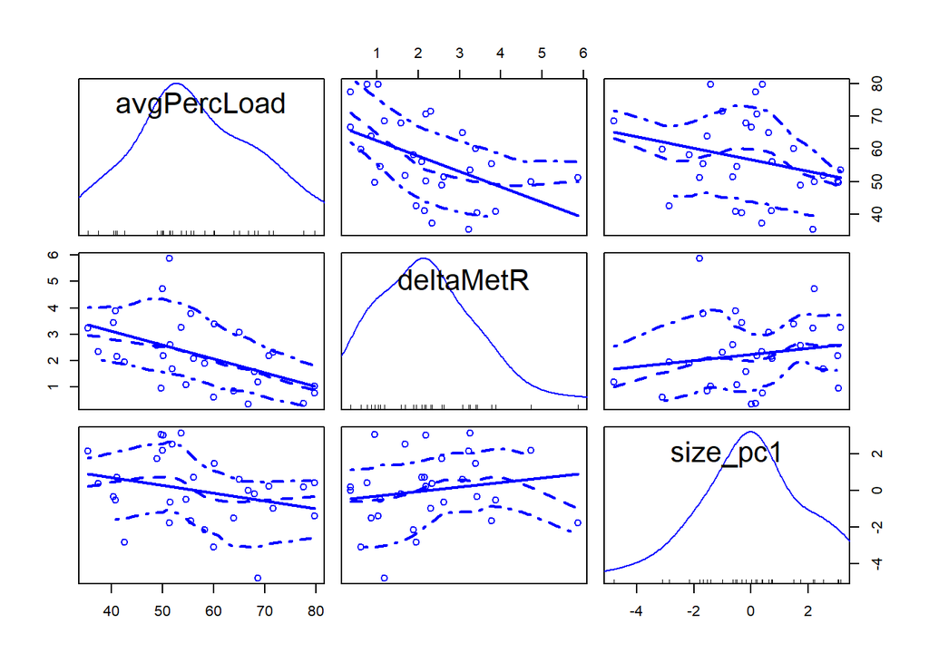

```r
# plot(I(deltaMetR)  ~ avgPercLoad, data = newDF)
# plot(I(deltaMetR / avgPercLoad)  ~ deltaMetR, data = newDF)

car::scatterplotMatrix(newDF[, c("avgPercLoad", "deltaMetR", "size_pc1")])
```

```r
car::vif(mod1)  # looks fine
```

```
## avgPercLoad     order_1    size_pc1
##    1.114454    1.051699    1.116654
```

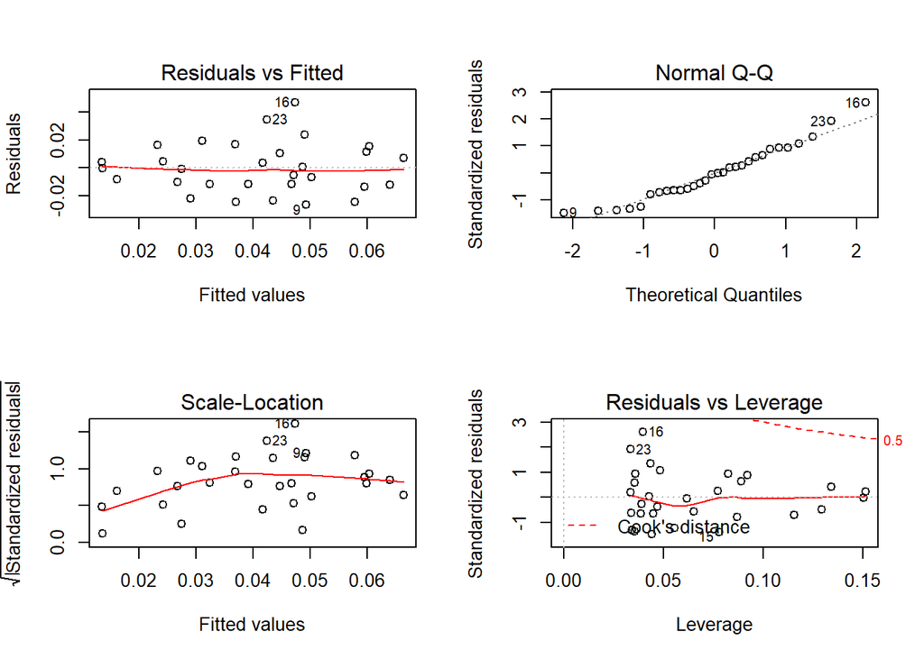

```r
par(mfrow = c(2,2))
plot(mod3) # possible nonlinear trend in residuals
```

```r
plot(mod3, which = 4)

# update model to add a non-linear term
newDF <- within(newDF, {avgPercLoad_cent = as.numeric(scale(newDF$avgPercLoad, center = TRUE, scale = FALSE))})
newDF$apl_cent2 <- with(newDF, avgPercLoad_cent^2)

m11 <- lm(dmr_dpl  ~ avgPercLoad_cent  + apl_cent2 + order_1 + size_pc1, data = newDF)
summary(m11)
```

```
##
## Call:
## lm(formula = dmr_dpl ~ avgPercLoad_cent + apl_cent2 + order_1 +
##     size_pc1, data = newDF)
##
## Residuals:
##       Min        1Q    Median        3Q       Max
## -0.026372 -0.011430 -0.004154  0.009170  0.044752
##
## Coefficients:
##                       Estimate Std. Error t value Pr(>|t|)
## (Intercept)          4.722e-02  5.369e-03   8.795    4e-09 ***
## avgPercLoad_cent    -1.070e-03  2.860e-04  -3.741  0.00096 ***
## apl_cent2            7.051e-06  2.112e-05   0.334  0.74123
## order_1loadedSecond -1.373e-02  7.006e-03  -1.960  0.06125 .
## size_pc1             1.494e-03  1.824e-03   0.819  0.42065
## ---
## Signif. codes:  0 '***' 0.001 '**' 0.01 '*' 0.05 '.' 0.1 ' ' 1
##
## Residual standard error: 0.01804 on 25 degrees of freedom
## Multiple R-squared:  0.4866, Adjusted R-squared:  0.4045
## F-statistic: 5.925 on 4 and 25 DF,  p-value: 0.0017
```

```r
car::vif(m11) # vif is much better with centered variables
```

```
## avgPercLoad_cent        apl_cent2          order_1         size_pc1
##         1.135857         1.108436         1.126036         1.118753
```

```r
m11a <- update(m11, .~. - size_pc1)
anova(m11, m11a) # remove size_pc1
```

```
## Analysis of Variance Table
##
## Model 1: dmr_dpl ~ avgPercLoad_cent + apl_cent2 + order_1 + size_pc1
## Model 2: dmr_dpl ~ avgPercLoad_cent + apl_cent2 + order_1
##   Res.Df       RSS Df   Sum of Sq      F Pr(>F)
## 1     25 0.0081360
## 2     26 0.0083542 -1 -0.00021818 0.6704 0.4206
```

```r
m11b <- update(m11a, .~. - apl_cent2)
anova(m11a, m11b) # drop squared term
```

```
## Analysis of Variance Table
##
## Model 1: dmr_dpl ~ avgPercLoad_cent + apl_cent2 + order_1
## Model 2: dmr_dpl ~ avgPercLoad_cent + order_1
##   Res.Df       RSS Df   Sum of Sq      F Pr(>F)
## 1     26 0.0083542
## 2     27 0.0083833 -1 -2.9042e-05 0.0904 0.7661
```

```r
summary(m11b)
```

```
##
## Call:
## lm(formula = dmr_dpl ~ avgPercLoad_cent + order_1, data = newDF)
##
## Residuals:
##       Min        1Q    Median        3Q       Max
## -0.030196 -0.012515 -0.003418  0.009765  0.040799
##
## Coefficients:
##                       Estimate Std. Error t value Pr(>|t|)
## (Intercept)          0.0474326  0.0047309  10.026 1.34e-10 ***
## avgPercLoad_cent    -0.0011242  0.0002644  -4.253 0.000226 ***
## order_1loadedSecond -0.0121420  0.0065038  -1.867 0.072809 .
## ---
## Signif. codes:  0 '***' 0.001 '**' 0.01 '*' 0.05 '.' 0.1 ' ' 1
##
## Residual standard error: 0.01762 on 27 degrees of freedom
## Multiple R-squared:  0.471,  Adjusted R-squared:  0.4319
## F-statistic: 12.02 on 2 and 27 DF,  p-value: 0.0001846
```

```r
m11c <- update(m11b, .~. -order_1 )
anova(m11b, m11c) # remove order_1
```

```
## Analysis of Variance Table
##
## Model 1: dmr_dpl ~ avgPercLoad_cent + order_1
## Model 2: dmr_dpl ~ avgPercLoad_cent
##   Res.Df       RSS Df  Sum of Sq      F  Pr(>F)
## 1     27 0.0083833
## 2     28 0.0094654 -1 -0.0010822 3.4854 0.07281 .
## ---
## Signif. codes:  0 '***' 0.001 '**' 0.01 '*' 0.05 '.' 0.1 ' ' 1
```

```r
summary(m11c) # final model for paper
```

```
##
## Call:
## lm(formula = dmr_dpl ~ avgPercLoad_cent, data = newDF)
##
## Residuals:
##       Min        1Q    Median        3Q       Max
## -0.026590 -0.011771 -0.000679  0.011114  0.046931
##
## Coefficients:
##                    Estimate Std. Error t value Pr(>|t|)
## (Intercept)       0.0409569  0.0033568  12.201 1.01e-12 ***
## avgPercLoad_cent -0.0011884  0.0002735  -4.345 0.000165 ***
## ---
## Signif. codes:  0 '***' 0.001 '**' 0.01 '*' 0.05 '.' 0.1 ' ' 1
##
## Residual standard error: 0.01839 on 28 degrees of freedom
## Multiple R-squared:  0.4028, Adjusted R-squared:  0.3814
## F-statistic: 18.88 on 1 and 28 DF,  p-value: 0.0001654
```

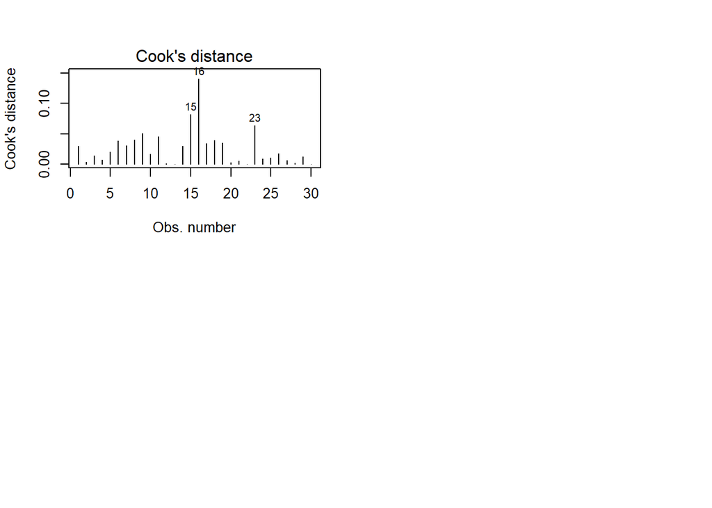

```r
## visualize model for deltametRate/avgPercLoading

par(mfrow = c(1,1))
```

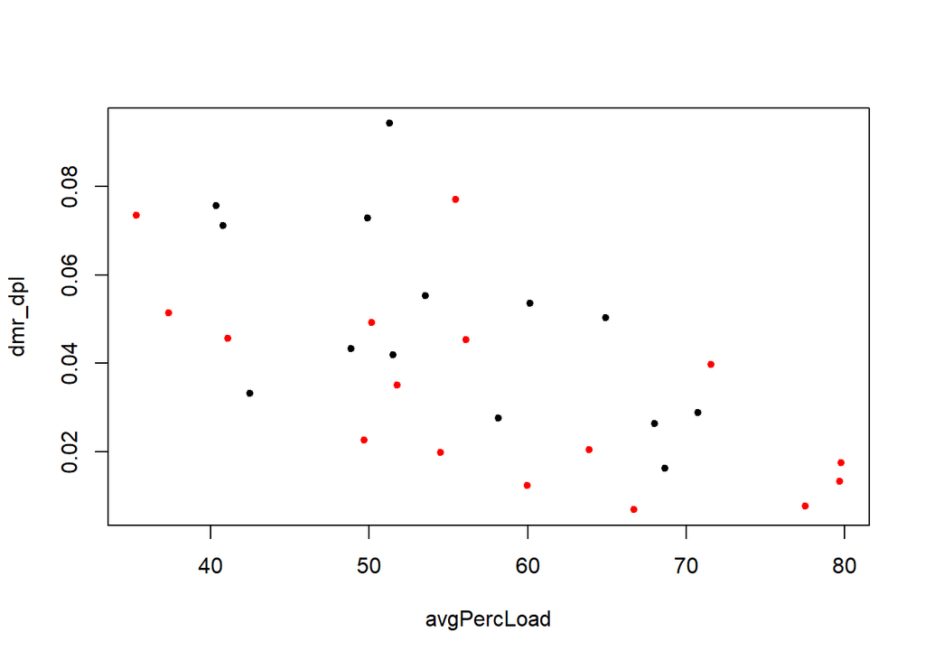

```r
plot(dmr_dpl  ~ avgPercLoad, col = factor(order_1), data = newDF, pch = 20)
```

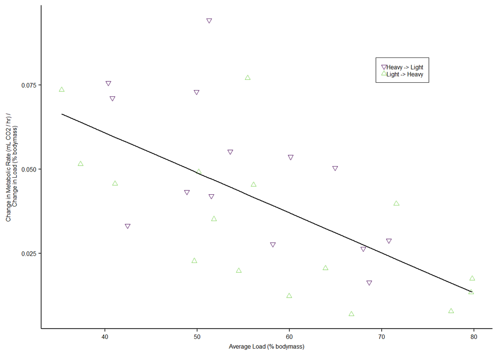

```r
ndf <- data.frame(avgPercLoad_cent = seq(min(newDF$avgPercLoad_cent), max(newDF$avgPercLoad_cent), length.out = 200),
                  order_1 = as.factor(rep(c("loadedFirst", "loadedSecond"), 100)))

ndf$apl_cent2 <- ndf$avgPercLoad_cent^2

ndf$avgPercLoad <- ndf$avgPercLoad_cent + mean(newDF$avgPercLoad)
predDF <- data.frame(preds = predict(m11c, newdata = ndf), ndf)


Fig6aDF <- newDF %>%
  mutate(load_order = recode(order_1, "loadedFirst" = "Heavy -> Light",
                             "loadedSecond" = "Light -> Heavy")) %>%
  mutate(predictedDeltaMetRate_dpl = predict(m11c),
          deltaMetRate_dpl = dmr_dpl) %>%
  select(avgPercLoad, deltaMetRate_dpl, load_order, predictedDeltaMetRate_dpl)



ggplot(Fig6aDF, aes(x = avgPercLoad, y = deltaMetRate_dpl)) +
     geom_point(aes(color = load_order, shape = load_order)) +
     geom_line(aes(x = avgPercLoad, y = predictedDeltaMetRate_dpl)) +
     labs(x = "Average Load (% bodymass)",
          y = "Change in Metabolic Rate (mL CO2 / hr) / \n Change in Load (% bodymass)") +
     scale_color_viridis_d( name = "Order", end = 0.8) +
  theme(legend.title = element_blank(),
        legend.background = element_rect(colour = "black", size = 0.3),
        legend.position = c(0.8,0.8),
        legend.text = element_text(size = 6),
        axis.text = element_text(size = 6),
        axis.title = element_text(size = 6),
        legend.key.size = unit(0.2, "cm"))  +
  scale_shape_manual(name = "Order", values = c(25, 24))
```

```r
ggsave(filename = file.path(figDir, "fig6a.png"), width = 6.5/2, height = 2,
       units = "in", dpi = 500)


# Save data for 6a
write_csv(Fig6aDF, file.path(dataOut, "Fig6a_data.csv"))
```

# (DeltaFrq^2/deltaPercLoad) ~ avgPercLoad + order_1 + size_pc1

```r
newDF <- within(newDF, {df2_dpl = deltaFrq2 / deltaPercLoad})

mod1_f <- lm(deltaFrq2  ~  avgPercLoad + order_1 + size_pc1, data = newDF)
summary(mod1_f)
```

```
##
## Call:
## lm(formula = deltaFrq2 ~ avgPercLoad + order_1 + size_pc1, data = newDF)
##
## Residuals:
##    Min     1Q Median     3Q    Max
##  -5016  -1482   -406   1508   5689
##
## Coefficients:
##                     Estimate Std. Error t value Pr(>|t|)
## (Intercept)         10731.58    2252.29   4.765 6.25e-05 ***
## avgPercLoad          -117.65      39.48  -2.980 0.006176 **
## order_1loadedSecond -3610.99     943.56  -3.827 0.000733 ***
## size_pc1             -410.30     254.01  -1.615 0.118320
## ---
## Signif. codes:  0 '***' 0.001 '**' 0.01 '*' 0.05 '.' 0.1 ' ' 1
##
## Residual standard error: 2514 on 26 degrees of freedom
## Multiple R-squared:  0.5385, Adjusted R-squared:  0.4853
## F-statistic: 10.11 on 3 and 26 DF,  p-value: 0.0001361
```

```r
mod2_f <- update(mod1_f, .~. - size_pc1)
anova(mod1_f, mod2_f) # remove size_pc1
```

```
## Analysis of Variance Table
##
## Model 1: deltaFrq2 ~ avgPercLoad + order_1 + size_pc1
## Model 2: deltaFrq2 ~ avgPercLoad + order_1
##   Res.Df       RSS Df Sum of Sq      F Pr(>F)
## 1     26 164342495
## 2     27 180834641 -1 -16492147 2.6092 0.1183
```

```r
summary(mod2_f) # not final model for paper
```

```
##
## Call:
## lm(formula = deltaFrq2 ~ avgPercLoad + order_1, data = newDF)
##
## Residuals:
##     Min      1Q  Median      3Q     Max
## -5175.0  -904.1   177.4  1340.0  6065.9
##
## Coefficients:
##                     Estimate Std. Error t value Pr(>|t|)
## (Intercept)          9811.39    2243.05   4.374 0.000163 ***
## avgPercLoad           -98.82      38.83  -2.545 0.016949 *
## order_1loadedSecond -3886.97     955.22  -4.069 0.000368 ***
## ---
## Signif. codes:  0 '***' 0.001 '**' 0.01 '*' 0.05 '.' 0.1 ' ' 1
##
## Residual standard error: 2588 on 27 degrees of freedom
## Multiple R-squared:  0.4922, Adjusted R-squared:  0.4546
## F-statistic: 13.09 on 2 and 27 DF,  p-value: 0.0001063
```

```r
# get p-values for avgPercLoad
anova(mod2_f,  update(mod2_f, .~. - order_1)) # p-value for order
```

```
## Analysis of Variance Table
##
## Model 1: deltaFrq2 ~ avgPercLoad + order_1
## Model 2: deltaFrq2 ~ avgPercLoad
##   Res.Df       RSS Df  Sum of Sq      F    Pr(>F)
## 1     27 180834641
## 2     28 291735830 -1 -110901188 16.558 0.0003684 ***
## ---
## Signif. codes:  0 '***' 0.001 '**' 0.01 '*' 0.05 '.' 0.1 ' ' 1
```

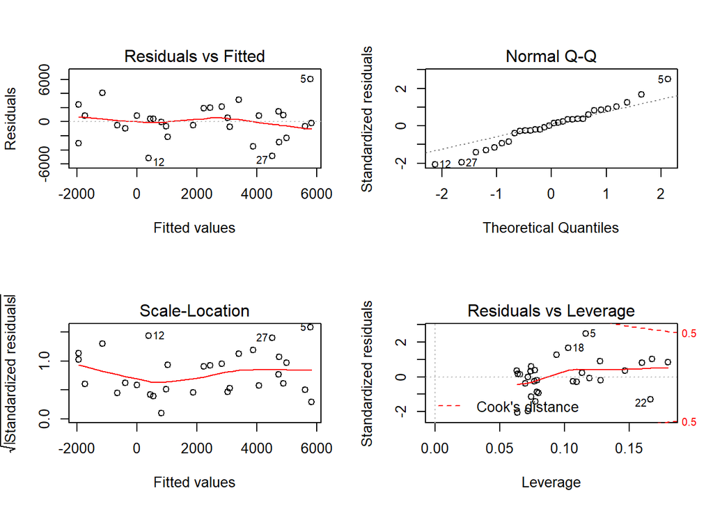

```r
par(mfrow = c(2,2))
plot(mod2_f) # possible non-linearity in residuals
```

```r
plot(mod2_f, which = 4)


# update model to add a non-linear term
m22 <- lm(df2_dpl  ~ avgPercLoad_cent  + apl_cent2 + order_1 + size_pc1, data = newDF)
summary(m22)
```

```
##
## Call:
## lm(formula = df2_dpl ~ avgPercLoad_cent + apl_cent2 + order_1 +
##     size_pc1, data = newDF)
##
## Residuals:
##     Min      1Q  Median      3Q     Max
## -86.636 -24.772   7.334  20.421  84.460
##
## Coefficients:
##                      Estimate Std. Error t value Pr(>|t|)
## (Intercept)          53.47755   12.85836   4.159 0.000329 ***
## avgPercLoad_cent     -2.78037    0.68498  -4.059 0.000426 ***
## apl_cent2             0.12540    0.05058   2.479 0.020267 *
## order_1loadedSecond -67.75441   16.77938  -4.038 0.000449 ***
## size_pc1             -6.88471    4.36949  -1.576 0.127682
## ---
## Signif. codes:  0 '***' 0.001 '**' 0.01 '*' 0.05 '.' 0.1 ' ' 1
##
## Residual standard error: 43.21 on 25 degrees of freedom
## Multiple R-squared:  0.6136, Adjusted R-squared:  0.5517
## F-statistic: 9.923 on 4 and 25 DF,  p-value: 5.978e-05
```

```r
car::vif(m22) # vif is much better with centered variables
```

```
## avgPercLoad_cent        apl_cent2          order_1         size_pc1
##         1.135857         1.108436         1.126036         1.118753
```

```r
m22a <- update(m22, .~. - size_pc1)
anova(m22, m22a) # remove size_pc1
```

```
## Analysis of Variance Table
##
## Model 1: df2_dpl ~ avgPercLoad_cent + apl_cent2 + order_1 + size_pc1
## Model 2: df2_dpl ~ avgPercLoad_cent + apl_cent2 + order_1
##   Res.Df   RSS Df Sum of Sq      F Pr(>F)
## 1     25 46673
## 2     26 51308 -1   -4634.8 2.4826 0.1277
```

```r
summary(m22a)
```

```
##
## Call:
## lm(formula = df2_dpl ~ avgPercLoad_cent + apl_cent2 + order_1,
##     data = newDF)
##
## Residuals:
##     Min      1Q  Median      3Q     Max
## -88.663 -29.831   5.708  19.525  90.167
##
## Coefficients:
##                      Estimate Std. Error t value Pr(>|t|)
## (Intercept)          55.57962   13.14854   4.227 0.000258 ***
## avgPercLoad_cent     -2.47131    0.67474  -3.663 0.001120 **
## apl_cent2             0.12885    0.05195   2.480 0.019934 *
## order_1loadedSecond -72.67082   16.95026  -4.287 0.000220 ***
## ---
## Signif. codes:  0 '***' 0.001 '**' 0.01 '*' 0.05 '.' 0.1 ' ' 1
##
## Residual standard error: 44.42 on 26 degrees of freedom
## Multiple R-squared:  0.5752, Adjusted R-squared:  0.5262
## F-statistic: 11.73 on 3 and 26 DF,  p-value: 4.778e-05
```

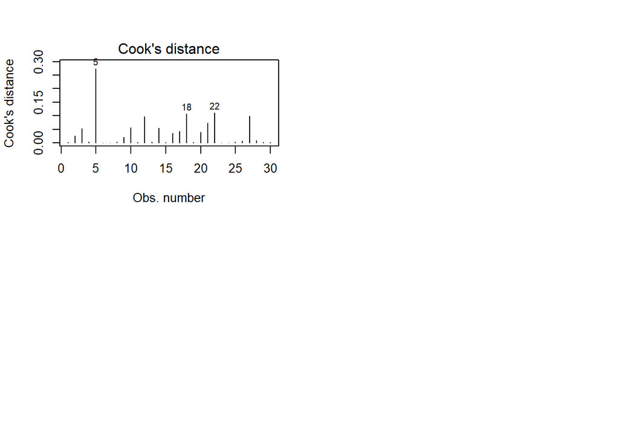

```r
par(mfrow = c(2,2))
```

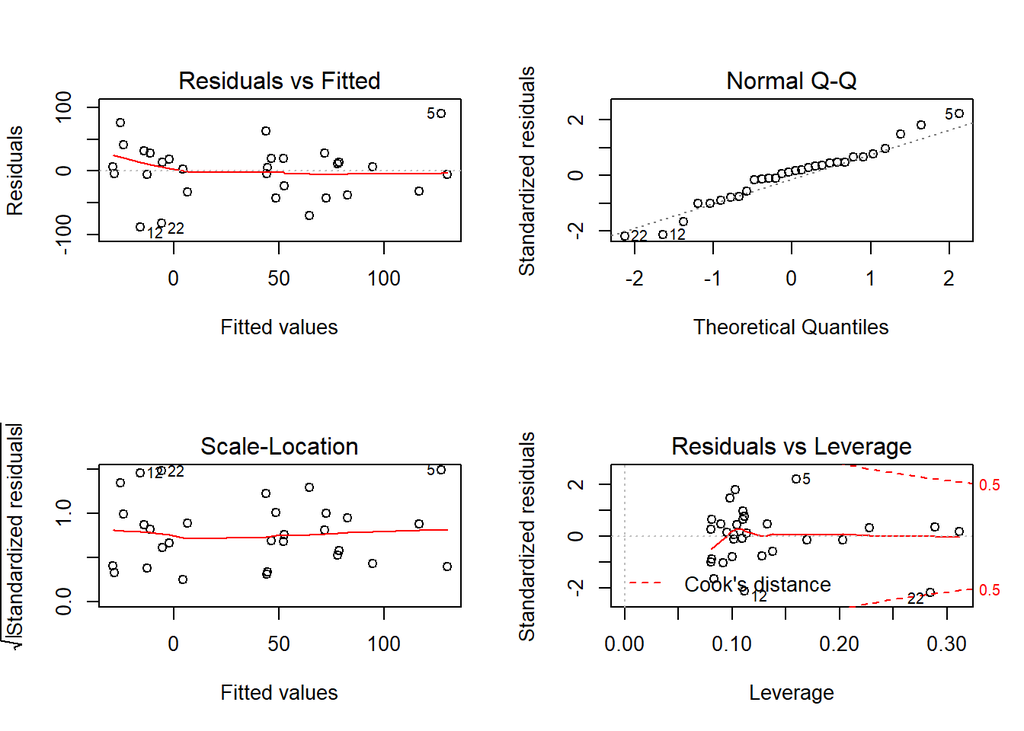

```r
plot(m22a) # residuals look better, though slight fan shape
```

```r
plot(m22a, which = 4) ## row 22 looks highly influential
nd22 <- newDF[-22, ]
m22s <- lm(df2_dpl  ~ avgPercLoad_cent  + apl_cent2 + order_1, data = nd22)
summary(m22s) # no major change when we remove obs num 22
```

```
##
## Call:
## lm(formula = df2_dpl ~ avgPercLoad_cent + apl_cent2 + order_1,
##     data = nd22)
##
## Residuals:
##     Min      1Q  Median      3Q     Max
## -86.049 -29.906  -1.961  22.642  89.870
##
## Coefficients:
##                      Estimate Std. Error t value Pr(>|t|)
## (Intercept)          51.62541   12.22894   4.222  0.00028 ***
## avgPercLoad_cent     -2.00921    0.65150  -3.084  0.00493 **
## apl_cent2             0.17487    0.05165   3.386  0.00235 **
## order_1loadedSecond -71.08343   15.63192  -4.547  0.00012 ***
## ---
## Signif. codes:  0 '***' 0.001 '**' 0.01 '*' 0.05 '.' 0.1 ' ' 1
##
## Residual standard error: 40.93 on 25 degrees of freedom
## Multiple R-squared:  0.6005, Adjusted R-squared:  0.5526
## F-statistic: 12.53 on 3 and 25 DF,  p-value: 3.405e-05
```

```r
plot(m22s, which = 4)

summary(m22a) # final model for paper
```

```
##
## Call:
## lm(formula = df2_dpl ~ avgPercLoad_cent + apl_cent2 + order_1,
##     data = newDF)
##
## Residuals:
##     Min      1Q  Median      3Q     Max
## -88.663 -29.831   5.708  19.525  90.167
##
## Coefficients:
##                      Estimate Std. Error t value Pr(>|t|)
## (Intercept)          55.57962   13.14854   4.227 0.000258 ***
## avgPercLoad_cent     -2.47131    0.67474  -3.663 0.001120 **
## apl_cent2             0.12885    0.05195   2.480 0.019934 *
## order_1loadedSecond -72.67082   16.95026  -4.287 0.000220 ***
## ---
## Signif. codes:  0 '***' 0.001 '**' 0.01 '*' 0.05 '.' 0.1 ' ' 1
##
## Residual standard error: 44.42 on 26 degrees of freedom
## Multiple R-squared:  0.5752, Adjusted R-squared:  0.5262
## F-statistic: 11.73 on 3 and 26 DF,  p-value: 4.778e-05
```

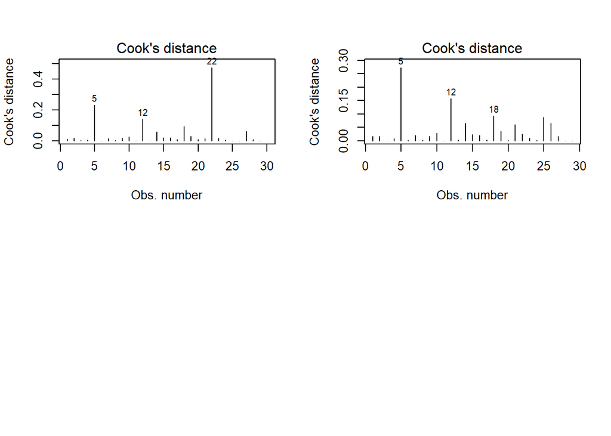

```r
# copy to clipboard, to paste into excel
write.table(data.frame(summary(m22a)$coef),"clipboard",sep="\t")


## visualize model for deltametRate/avgPercLoading

ndf <- data.frame(avgPercLoad_cent = seq(min(newDF$avgPercLoad_cent), max(newDF$avgPercLoad_cent), length.out = 200),
                  order_1 = as.factor(rep(c("loadedFirst", "loadedSecond"), 100)))

ndf$apl_cent2 <- ndf$avgPercLoad_cent^2

ndf$apl <- ndf$avgPercLoad_cent + mean(newDF$avgPercLoad)


predDF <- data.frame(preds = predict(m22a, newdata = ndf, se = TRUE), ndf)
predDF<- mutate(predDF,
                            load_order = recode(order_1,
                                                "loadedFirst" = "Heavy -> Light",
                             "loadedSecond" = "Light -> Heavy"))

par(mfrow = c(1,1))
```

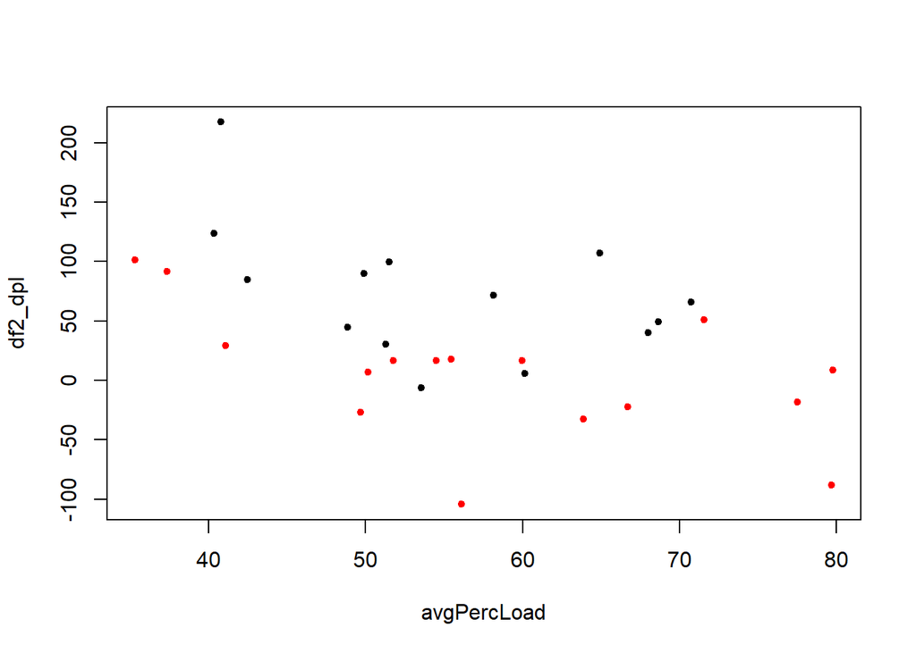

```r
plot(df2_dpl  ~ avgPercLoad, col = factor(order_1), data = newDF, pch = 20)
```

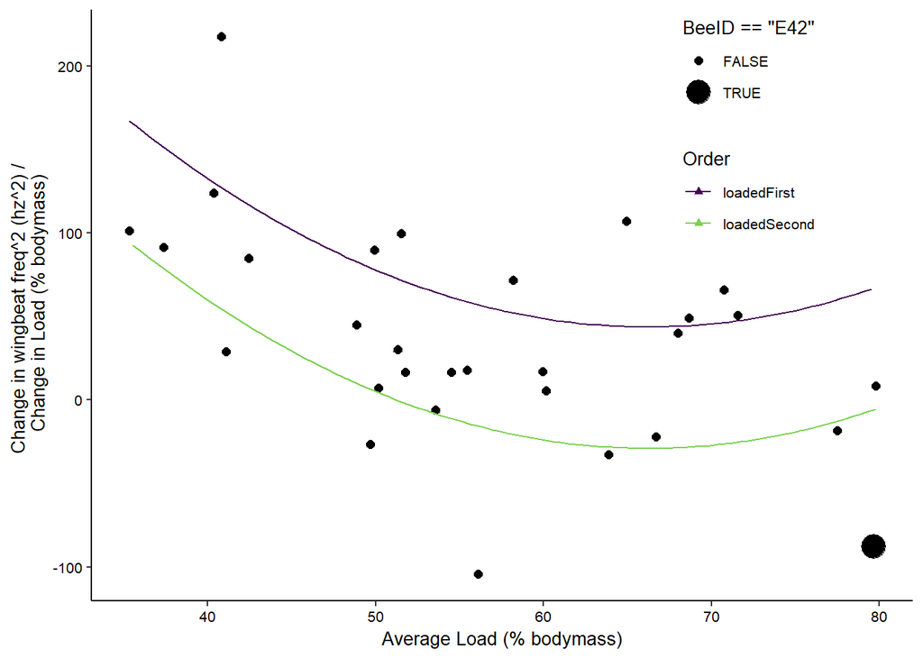

```r
ggplot(newDF, aes(x = avgPercLoad, y = df2_dpl)) +
     geom_point(aes(color = order_1),shape = 17) +
     geom_point(aes(size = BeeID == "E42")) +  # show the influential point
     geom_line(data = predDF, aes(x = apl, y = preds.fit, color = order_1)) +
     # geom_line(data = predDF, aes(x = apl, y = preds.fit + 1.96*preds.se.fit, color = order_1), lty = 2) +
     # geom_line(data = predDF, aes(x = apl, y = preds.fit - 1.96*preds.se.fit, color = order_1), lty = 2) +
     labs(x = "Average Load (% bodymass)",
          y = "Change in wingbeat freq^2 (hz^2) / \n Change in Load (% bodymass)") +
     scale_color_viridis_d( name = "Order",end = 0.8) +
     theme(legend.position = c(0.8,0.8))
```

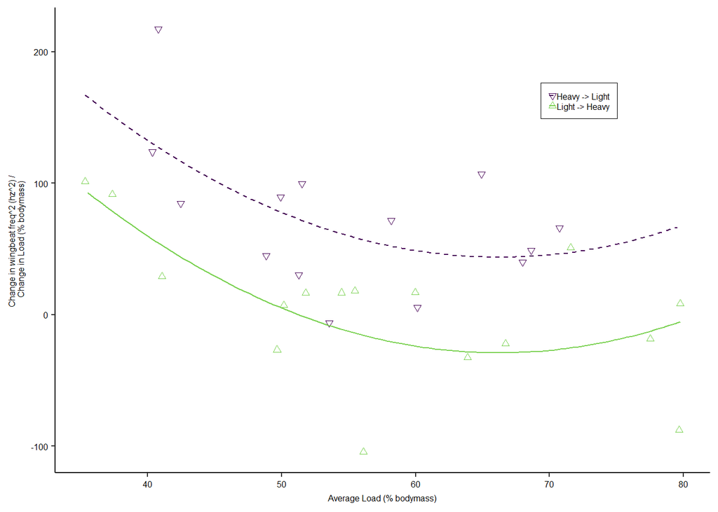

```r
newDF %>%
  mutate(load_order = recode(order_1, "loadedFirst" = "Heavy -> Light",
                             "loadedSecond" = "Light -> Heavy")) %>%
ggplot( aes(x = avgPercLoad, y = df2_dpl)) +
     geom_point(aes(color = load_order, shape = load_order )) +
     geom_line(data = predDF, aes(x = apl, y = preds.fit, color = load_order, lty = load_order)) +
     labs(x = "Average Load (% bodymass)",
          y = "Change in wingbeat freq^2 (hz^2) / \n Change in Load (% bodymass)") +
     scale_color_viridis_d( name = "Order", end = 0.8) +
     theme(legend.title = element_blank(),
        legend.background = element_rect(colour = "black", size = 0.3),
        legend.position = c(0.8,0.8),
        legend.text = element_text(size = 6),
        axis.text = element_text(size = 6),
        axis.title = element_text(size = 6),
        legend.key.size = unit(0.2, "cm"))  +
  scale_shape_manual(name = "Order", values = c(25, 24)) +
  scale_linetype_manual(name = "Order", values = c(2,1))
```

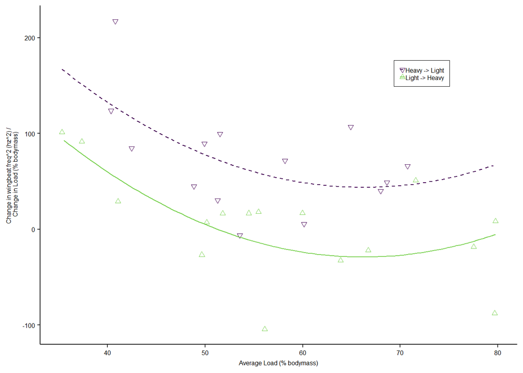

```r
ggsave(filename = file.path(figDir, "fig6b.png"), width = 6.5/2, height = 2,
       units = "in", dpi = 500)

## save line as csv file
predDF_small <- predDF %>%
  mutate(predictedLine = preds.fit,
         avg_perc_load = apl,
         load_order = recode(order_1, "loadedFirst" = "Heavy -> Light",
                             "loadedSecond" = "Light -> Heavy")) %>%
  select(avg_perc_load, load_order, predictedLine)

write_csv(predDF_small, file.path(dataOut, "Fig6b_PredictedLine.csv"))

newDF_6b <- newDF %>%
  mutate(avg_perc_load = avgPercLoad,
         delta_freq2_perLoad = df2_dpl,
        load_order = recode(order_1, "loadedFirst" = "Heavy -> Light",
                             "loadedSecond" = "Light -> Heavy")) %>%
  select(avg_perc_load, delta_freq2_perLoad, load_order)

write_csv(newDF_6b, file.path(dataOut, "Fig6b_dataPoints.csv"))


# double check data to make sure I saved the right data
ggplot(newDF_6b, aes(x = avg_perc_load, y = delta_freq2_perLoad)) +
     geom_point(aes(color = load_order, shape = load_order )) +
     geom_line(data = predDF_small, aes(x = avg_perc_load, y = predictedLine, color = load_order, lty = load_order)) +
     labs(x = "Average Load (% bodymass)",
          y = "Change in wingbeat freq^2 (hz^2) / \n Change in Load (% bodymass)") +
     scale_color_viridis_d( name = "Order", end = 0.8) +
     theme(legend.title = element_blank(),
        legend.background = element_rect(colour = "black", size = 0.3),
        legend.position = c(0.8,0.8),
        legend.text = element_text(size = 6),
        axis.text = element_text(size = 6),
        axis.title = element_text(size = 6),
        legend.key.size = unit(0.2, "cm"))  +
  scale_shape_manual(name = "Order", values = c(25, 24)) +
  scale_linetype_manual(name = "Order", values = c(2,1))
```

# (DeltaArcL^2/deltaPerLoad) ~ avgPercLoad + order_1 + size_pc1

```r
newDF <- within(newDF, {da2_dpl = deltaArcL2 / deltaPercLoad})

mod1_a <- lm(da2_dpl  ~ avgPercLoad + order_1 + size_pc1, data = newDF)
summary(mod1_a) # P-values for original model
```

```
##
## Call:
## lm(formula = da2_dpl ~ avgPercLoad + order_1 + size_pc1, data = newDF)
##
## Residuals:
##        Min         1Q     Median         3Q        Max
## -1.132e-06 -4.984e-07  6.244e-08  4.953e-07  1.054e-06
##
## Coefficients:
##                       Estimate Std. Error t value Pr(>|t|)
## (Intercept)          1.719e-06  5.312e-07   3.237  0.00329 **
## avgPercLoad          3.674e-09  9.312e-09   0.395  0.69641
## order_1loadedSecond -2.368e-07  2.226e-07  -1.064  0.29706
## size_pc1             4.140e-08  5.991e-08   0.691  0.49567
## ---
## Signif. codes:  0 '***' 0.001 '**' 0.01 '*' 0.05 '.' 0.1 ' ' 1
##
## Residual standard error: 5.93e-07 on 26 degrees of freedom
## Multiple R-squared:  0.05092,    Adjusted R-squared:  -0.05859
## F-statistic: 0.465 on 3 and 26 DF,  p-value: 0.7092
```

```r
# copy to clipboard, to paste into excel
write.table(as.data.frame(summary(mod1_a)$coef),"clipboard",sep="\t", row.names = TRUE)


mod2_a <- update(mod1_a, .~. - avgPercLoad)  # I also checked for a squared term in this model (code not shown)
anova(mod1_a, mod2_a) # remove avgPercLoad
```

```
## Analysis of Variance Table
##
## Model 1: da2_dpl ~ avgPercLoad + order_1 + size_pc1
## Model 2: da2_dpl ~ order_1 + size_pc1
##   Res.Df        RSS Df   Sum of Sq      F Pr(>F)
## 1     26 9.1429e-12
## 2     27 9.1976e-12 -1 -5.4736e-14 0.1557 0.6964
```

```r
summary(mod2_a)
```

```
##
## Call:
## lm(formula = da2_dpl ~ order_1 + size_pc1, data = newDF)
##
## Residuals:
##        Min         1Q     Median         3Q        Max
## -1.103e-06 -5.079e-07  7.199e-08  4.954e-07  9.781e-07
##
## Coefficients:
##                       Estimate Std. Error t value Pr(>|t|)
## (Intercept)          1.919e-06  1.568e-07  12.242 1.57e-12 ***
## order_1loadedSecond -2.214e-07  2.156e-07  -1.027    0.314
## size_pc1             3.442e-08  5.634e-08   0.611    0.546
## ---
## Signif. codes:  0 '***' 0.001 '**' 0.01 '*' 0.05 '.' 0.1 ' ' 1
##
## Residual standard error: 5.837e-07 on 27 degrees of freedom
## Multiple R-squared:  0.04524,    Adjusted R-squared:  -0.02549
## F-statistic: 0.6396 on 2 and 27 DF,  p-value: 0.5353
```

```r
mod2_b <- update(mod2_a, .~. - size_pc1)
anova(mod2_a, mod2_b)  # remove size
```

```
## Analysis of Variance Table
##
## Model 1: da2_dpl ~ order_1 + size_pc1
## Model 2: da2_dpl ~ order_1
##   Res.Df        RSS Df   Sum of Sq      F Pr(>F)
## 1     27 9.1976e-12
## 2     28 9.3248e-12 -1 -1.2716e-13 0.3733 0.5463
```

```r
summary(mod2_b)
```

```
##
## Call:
## lm(formula = da2_dpl ~ order_1, data = newDF)
##
## Residuals:
##        Min         1Q     Median         3Q        Max
## -1.111e-06 -4.469e-07  1.670e-09  4.402e-07  9.825e-07
##
## Coefficients:
##                       Estimate Std. Error t value Pr(>|t|)
## (Intercept)          1.910e-06  1.542e-07  12.382 7.08e-13 ***
## order_1loadedSecond -2.033e-07  2.112e-07  -0.963    0.344
## ---
## Signif. codes:  0 '***' 0.001 '**' 0.01 '*' 0.05 '.' 0.1 ' ' 1
##
## Residual standard error: 5.771e-07 on 28 degrees of freedom
## Multiple R-squared:  0.03204,    Adjusted R-squared:  -0.002535
## F-statistic: 0.9267 on 1 and 28 DF,  p-value: 0.344
```

```r
mod2c <- update(mod2_b, .~. - order_1)
anova(mod2c, mod2_b) # remove order
```

```
## Analysis of Variance Table
##
## Model 1: da2_dpl ~ 1
## Model 2: da2_dpl ~ order_1
##   Res.Df        RSS Df  Sum of Sq      F Pr(>F)
## 1     29 9.6334e-12
## 2     28 9.3248e-12  1 3.0861e-13 0.9267  0.344
```

```r
summary(mod2c) # final mod for paper
```

```
##
## Call:
## lm(formula = da2_dpl ~ 1, data = newDF)
##
## Residuals:
##        Min         1Q     Median         3Q        Max
## -1.206e-06 -4.613e-07 -1.433e-08  4.925e-07  9.636e-07
##
## Coefficients:
##              Estimate Std. Error t value Pr(>|t|)
## (Intercept) 1.801e-06  1.052e-07   17.12   <2e-16 ***
## ---
## Signif. codes:  0 '***' 0.001 '**' 0.01 '*' 0.05 '.' 0.1 ' ' 1
##
## Residual standard error: 5.764e-07 on 29 degrees of freedom
```

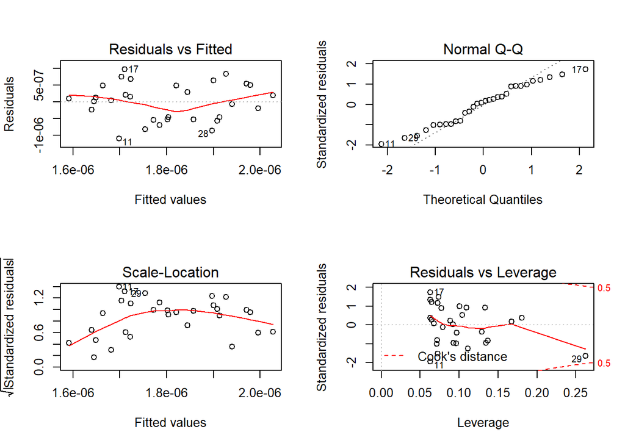

```r
# copy to clipboard, to paste into excel
write.table(as.data.frame(summary(mod2c)$coef),"clipboard",sep="\t", row.names = TRUE)

par(mfrow = c(2,2))
plot(mod2_a)
```

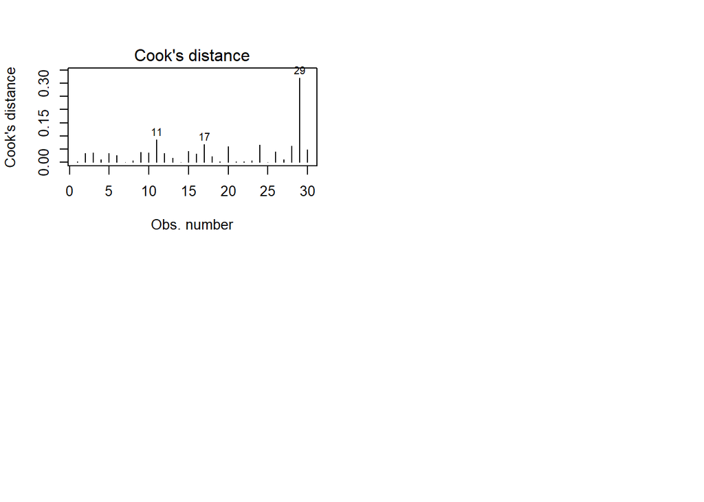

```r
plot(mod2_a, which = 4)

# visualize model
ndf <- data.frame(avgPercLoad_cent = seq(min(newDF$avgPercLoad_cent),
                                         max(newDF$avgPercLoad_cent), length.out = 200),
                  order_1 = as.factor(rep(c("loadedFirst", "loadedSecond"), 100)))

ndf$apl_cent2 <- ndf$avgPercLoad_cent^2

ndf$avgPercLoad <- ndf$avgPercLoad_cent + mean(newDF$avgPercLoad)

predDF <- data.frame(preds = predict(mod2c, newdata = ndf, se = TRUE), ndf)

par(mfrow = c(1,1))
```

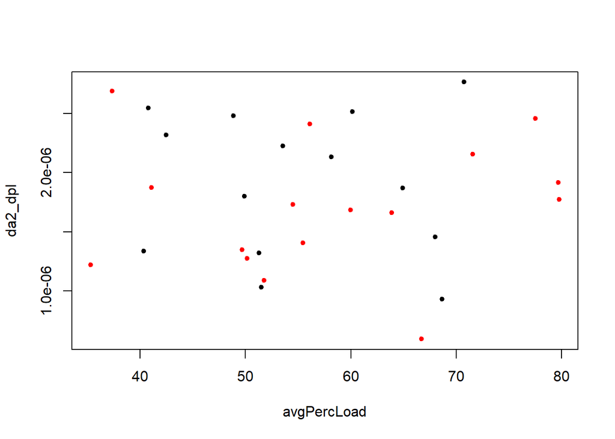

```r
plot(da2_dpl  ~ avgPercLoad, col = factor(order_1), data = newDF, pch = 20)
```

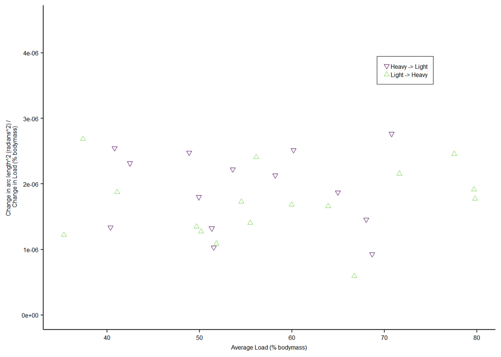

```r
fig6cDF <- newDF %>%
  mutate(load_order = recode(order_1, "loadedFirst" = "Heavy -> Light",
                             "loadedSecond" = "Light -> Heavy"),
         deltaArcLen2_deltaLoad = da2_dpl) %>%
  select(avgPercLoad, load_order, deltaArcLen2_deltaLoad)

write_csv(fig6cDF, file.path(dataOut, "Fig6c_dataPoints.csv"))


ggplot(fig6cDF, aes(x = avgPercLoad, y = deltaArcLen2_deltaLoad)) +
     geom_point(aes(color = load_order, shape = load_order)) +
     labs(x = "Average Load (% bodymass)",
          y = "Change in arc length^2 (radians^2) / \n Change in Load (% bodymass)") +
     ylim(c(0, 4.5e-6)) +
     scale_color_viridis_d( name = "Order", end = 0.8) +
     theme(legend.title = element_blank(),
        legend.background = element_rect(colour = "black", size = 0.3),
        legend.position = c(0.8,0.8),
        legend.text = element_text(size = 6),
        axis.text = element_text(size = 6),
        axis.title = element_text(size = 6),
        legend.key.size = unit(0.3, "cm"))  +
    scale_shape_manual(name = "Order", values = c(25, 24))
```

```r
ggsave(filename = file.path(figDir, "fig6c.png"), width = 6.5/2, height = 2,
       units = "in", dpi = 500)
```

```r
Sys.time()
```

```
## [1] "2019-02-22 12:59:02 PST"
```